# Household expenditures with Malaria

This Python notebook will calculate expenditures with Malaria at household level, with data collected by a field research conducted in the Brazilian Amazon region in April 2022.

## Pre-processing

All the data pre-processing will be conducted in this section. First, the necessary Python libraries will be imported. Then, all the datasets are loaded into Python and treatment ensues.

### Libraries

'Pandas' will be used to create dataframe objects. 'OS' will be used to better interface with the operational system and read environment variables. 'dotenv' is used to access said variables. 'Numpy', 'math' and 'scipy' will be used to provide necessary math operations. 'Datetime' allows operations with dates. 'Random' generates pseudo-random numbers. 'tqdm', 'stasmodels' and 'sklearn' estimate OLS models. Finally, 'IPython', 'seaborn' and 'matplotlib' are graphical interfaces, while 'warnings' is used to suppress warnings.

```python
import pandas as pd
import numpy as np
import seaborn as sns
import datetime as dt
import os
import math
import scipy
import warnings
import random
from tqdm import tqdm
from IPython.display import display
from dotenv import load_dotenv
from statsmodels.formula import api
from sklearn.feature_selection import RFE
from sklearn.preprocessing import StandardScaler
from sklearn.model_selection import train_test_split
from statsmodels.stats.outliers_influence import variance_inflation_factor
from sklearn.decomposition import PCA
from sklearn.linear_model import Ridge
from sklearn.linear_model import Lasso
from sklearn.linear_model import ElasticNet
from sklearn.linear_model import LinearRegression
from sklearn.ensemble import RandomForestClassifier
from sklearn.preprocessing import PolynomialFeatures
from sklearn.metrics import r2_score, mean_absolute_error, mean_squared_error
import matplotlib.pyplot as plt
import statistics as sts
warnings.filterwarnings('ignore')
pd.options.display.float_format = '{:20,.2f}'.format
```

### Dataset loading

The environment variables will be read through the 'load_dotenv()' command.

```python
load_dotenv('env_variables.env')
```

```
True
```

The absolute path and file names/sheets will be retrieved from the environment variables.

```python
path = os.environ["PATH_FILES"]
path_export = os.environ["PATH_EXPORTS"]
export_file = os.environ["EXPORT_FILE"]

file_1 = os.environ["FILE_HOUSEHOLD_DATASET"]
file_2 = os.environ["FILE_POF_DATASET"]
file_3 = os.environ["FILE_VEHICLES_DATASET"]
file_4 = os.environ["FILE_FUEL_DATASET"]
file_5 = os.environ["FILE_FARES_DATASET"]
file_6 = os.environ["FILE_UBER_DATASET"]
file_7 = os.environ["FILE_FUNDEB_DATASET"]
file_8 = os.environ["FILE_PNAD_DATASET"]
file_9 = os.environ["FILE_MONTHLY_WAGE_DATASET"]
file_10 = os.environ["FILE_SELFCONSUMPTION_DATASET"]
file_11 = os.environ["FILE_MINIMUM_WAGE_DATASET"]
file_12 = os.environ["FILE_TERTIARY_EDUCATION_DATASET"]
file_13 = os.environ["FILE_MORTALITY_DATASET"]
file_14 = os.environ["FILE_LIFE_EXPECTANCY_DATASET"]
file_15 = os.environ["FILE_QUALITY_LIFE_DATASET"]
file_16 = os.environ["FILE_INFLATION_DATASET"]
file_17 = os.environ["FILE_HOUSEHOLDS_CITY_DATASET"]
file_18 = os.environ["FILE_HOUSEHOLDS_STATE_DATASET"]
file_19 = os.environ["FILE_SENSITIVITY"]

sheet_1_file_1 = os.environ["SHEET_PREVENTION_DATASET"]
sheet_2_file_1 = os.environ["SHEET_MEDICAL_CARE_DATASET"]
sheet_1_file_3 = os.environ["SHEET_FUEL_CONSUMPTION_DATASET"]
sheet_1_file_4 = os.environ["SHEET_GASOLINE_PRICES_DATASET"]
sheet_1_file_5 = os.environ["SHEET_BUS_FARES_DATASET"]
sheet_2_file_5 = os.environ["SHEET_CAB_FARES_DATASET"]
sheet_1_file_16 = os.environ["SHEET_ANNUAL_INFLATION_DATASET"]
sheet_2_file_16 = os.environ["SHEET_MONTHLY_INFLATION_DATASET"]
```

Then, all the datasets are loaded. The main dataset is comprised of information at household level. These will be stored at the object 'df'.

```python
df = pd.read_excel(os.path.join(path, file_1))
df.head()
```

|  | id_domicilio | zona | municipio | num_moradores | comodos | banheiros | som | tv | dvd | geladeira | ... | casos_malaria | internacao | grupo_data | multiplos_beneficios | multiplos_tratamentos | configuracao_familiar | ano_malaria | mes_malaria | dia_malaria | uf |
| --- | --- | --- | --- | --- | --- | --- | --- | --- | --- | --- | --- | --- | --- | --- | --- | --- | --- | --- | --- | --- | --- |
| 0 | 1 | 2 | 1 | 9 | 3 | 2 | 0 | 0 | 0 | 1 | ... | 5.00 | 1.00 | 1 | 0.00 | NaN | 5 | 2,022.00 | 1.00 | 0.00 | 11 |
| 1 | 2 | 2 | 1 | 6 | 5 | 1 | 0 | 1 | 0 | 1 | ... | 5.00 | 0.00 | 1 | 0.00 | NaN | 5 | 2,022.00 | 1.00 | 0.00 | 11 |
| 2 | 3 | 2 | 1 | 7 | 4 | 1 | 0 | 1 | 0 | 1 | ... | 2.00 | 0.00 | 2 | NaN | 0.00 | 5 | 2,022.00 | 2.00 | 0.00 | 11 |
| 3 | 4 | 2 | 1 | 3 | 5 | 2 | 1 | 1 | 1 | 1 | ... | 10.00 | 0.00 | 1 | 1.00 | 1.00 | 5 | 2,020.00 | 12.00 | 12.00 | 11 |
| 4 | 5 | 2 | 1 | 4 | 4 | 2 | 0 | 1 | 0 | 0 | ... | 50.00 | 0.00 | 1 | 0.00 | 0.00 | 3 | 2,021.00 | 8.00 | 20.00 | 11 |

5 rows × 147 columns

The two following datasets are derived from POF (Pesquisa de Orçamentos Familiares - Family Budget Survey), conducted by IBGE. The first contains the annual average expenditures with Malaria prevention, by State, and the second the average per capita medical care expenditures, also by State.

```python
df_prevention = pd.read_excel(os.path.join(path, file_2), sheet_name = sheet_1_file_1)
df_prevention['UF'] = df_prevention['UF'].astype(str)
df_prevention.head()
```

|  | UF | media |
| --- | --- | --- |
| 0 | 11 | 11.84 |
| 1 | 12 | 17.59 |
| 2 | 13 | 18.97 |
| 3 | 14 | 21.36 |
| 4 | 15 | 15.33 |

```python
df_medical = pd.read_excel(os.path.join(path, file_2), sheet_name = sheet_2_file_1)
df_medical['UF'] = df_medical['UF'].astype(str)
df_medical.head()
```

|  | UF | media |
| --- | --- | --- |
| 0 | 11 | 24.03 |
| 1 | 12 | 22.92 |
| 2 | 13 | 17.11 |
| 3 | 14 | 40.43 |
| 4 | 15 | 20.37 |

The third dataset contains average fuel efficiency (km/L) of an hypothetical vehicle, by year.

```python
df_vehicle = pd.read_excel(os.path.join(path, file_3), sheet_name = sheet_1_file_3)
df_vehicle['ano'] = df_vehicle['ano'].astype(str)
df_vehicle.head()
```

|  | ano | consumo |
| --- | --- | --- |
| 0 | 2019 | 12.37 |
| 1 | 2020 | 12.68 |
| 2 | 2021 | 12.06 |
| 3 | 2022 | 12.86 |

The fourth dataset contains average gasoline price data, by month/year.

```python
df_gasoline = pd.read_excel(os.path.join(path, file_4), sheet_name = sheet_1_file_4)
df_gasoline['ano'] = df_gasoline['ano'].astype(str)
df_gasoline['mes'] = df_gasoline['mes'].astype(str)
df_gasoline['uf'] = df_gasoline['uf'].astype(str)
df_gasoline.head()
```

|  | ano | mes | uf | preco |
| --- | --- | --- | --- | --- |
| 0 | 2019 | 1 | 12 | 4.77 |
| 1 | 2019 | 1 | 16 | 3.86 |
| 2 | 2019 | 1 | 13 | 3.84 |
| 3 | 2019 | 1 | 15 | 4.43 |
| 4 | 2019 | 1 | 11 | 4.36 |

The next datasets contains the bus and cab fare by month/year and State.

```python
df_bus = pd.read_excel(os.path.join(path, file_5), sheet_name = sheet_1_file_5)
df_bus['ano'] = df_bus['ano'].astype(str)
df_bus['mes'] = df_bus['mes'].astype(str)
df_bus['uf'] = df_bus['uf'].astype(str)
df_bus.head()
```

|  | ano | mes | uf | tarifa |
| --- | --- | --- | --- | --- |
| 0 | 2019 | 1 | 11 | 3.80 |
| 1 | 2019 | 2 | 11 | 3.80 |
| 2 | 2019 | 3 | 11 | 3.80 |
| 3 | 2019 | 4 | 11 | 3.80 |
| 4 | 2019 | 5 | 11 | 3.80 |

```python
df_cab = pd.read_excel(os.path.join(path, file_5), sheet_name = sheet_2_file_5)
df_cab['ano'] = df_cab['ano'].astype(str)
df_cab['mes'] = df_cab['mes'].astype(str)
df_cab['uf'] = df_cab['uf'].astype(str)
df_cab.head()
```

|  | ano | mes | uf | bandeirada | km |
| --- | --- | --- | --- | --- | --- |
| 0 | 2019 | 1 | 11 | 5.08 | 3.16 |
| 1 | 2019 | 2 | 11 | 5.08 | 3.16 |
| 2 | 2019 | 3 | 11 | 5.08 | 3.16 |
| 3 | 2019 | 4 | 11 | 5.08 | 3.16 |
| 4 | 2019 | 5 | 11 | 5.08 | 3.16 |

The sixth dataset has data on 200k Uber trips around the world.

```python
df_uber = pd.read_csv(os.path.join(path, file_6))
df_uber.head()
```

|  | passenger_count | tarifa | dist | tempo | booking | ano | mes_01 | mes_02 | mes_03 | mes_04 | ... | dia_semana_4 | dia_semana_5 | dia_semana_6 | dia_semana_7 | decil_hora_1 | decil_hora_2 | decil_hora_3 | decil_hora_4 | decil_hora_5 | decil_hora_6 |
| --- | --- | --- | --- | --- | --- | --- | --- | --- | --- | --- | --- | --- | --- | --- | --- | --- | --- | --- | --- | --- | --- |
| 0 | 2 | 24.30 | 1.62 | 3.77 | 0 | 2009 | 1 | 0 | 0 | 0 | ... | 0 | 1 | 0 | 0 | 1 | 0 | 0 | 0 | 0 | 0 |
| 1 | 2 | 117.00 | 8.16 | 19.02 | 0 | 2009 | 1 | 0 | 0 | 0 | ... | 0 | 1 | 0 | 0 | 0 | 1 | 0 | 0 | 0 | 0 |
| 2 | 1 | 43.05 | 3.75 | 8.74 | 0 | 2009 | 1 | 0 | 0 | 0 | ... | 0 | 1 | 0 | 0 | 0 | 1 | 0 | 0 | 0 | 0 |
| 3 | 3 | 22.59 | 0.87 | 2.03 | 0 | 2009 | 1 | 0 | 0 | 0 | ... | 0 | 1 | 0 | 0 | 0 | 0 | 0 | 0 | 0 | 1 |
| 4 | 1 | 27.71 | 0.01 | 0.02 | 0 | 2009 | 1 | 0 | 0 | 0 | ... | 0 | 1 | 0 | 0 | 0 | 0 | 0 | 0 | 1 | 0 |

5 rows × 44 columns

The seventh dataset has data from FUNDEB, the Federal Brazilian Fund for basic education. It contains average daily cost per student per level of basic education.

```python
df_fundeb = pd.read_csv(os.path.join(path, file_7))
df_fundeb['ano'] = df_fundeb['ano'].astype(str)
df_fundeb['uf'] = df_fundeb['uf'].astype(str)
df_fundeb['zona'] = df_fundeb['zona'].astype(str)
df_fundeb.drop('Unnamed: 0', axis = 1, inplace = True)
df_fundeb.head()
```

|  | ano | uf | zona | creche | pre_escola | fundamental_I | fundamental_II | medio |
| --- | --- | --- | --- | --- | --- | --- | --- | --- |
| 0 | 2019 | 12 | 1 | 5.43 | 4.95 | 4.72 | 5.19 | 5.90 |
| 1 | 2019 | 12 | 2 | 5.43 | 4.95 | 5.43 | 5.66 | 6.13 |
| 2 | 2019 | 13 | 1 | 4.95 | 4.52 | 4.30 | 4.73 | 5.38 |
| 3 | 2019 | 13 | 2 | 4.95 | 4.52 | 4.95 | 5.16 | 5.59 |
| 4 | 2019 | 16 | 1 | 6.18 | 5.64 | 5.38 | 5.91 | 6.72 |

The eigth and ninth data has monthly wage data according to State, zone of living, sex and year, in the case of the first, and mean wage according to State/sex, in the case of the second.

```python
df_pnad = pd.read_csv(os.path.join(path, file_8))
df_pnad['ano'] = df_pnad['ano'].astype(str)
df_pnad['UF'] = df_pnad['UF'].astype(str)
df_pnad['sexo'] = df_pnad['sexo'].astype(str)
df_pnad['zona'] =  df_pnad['zona'].astype(str)
df_pnad.rename(columns={'UF': 'uf'}, inplace = True)
df_pnad.head()
```

|  | ano | zona | sexo | mean | SE | uf |
| --- | --- | --- | --- | --- | --- | --- |
| 0 | 2019 | 1 | 1 | 1,829.64 | 80.93 | 12 |
| 1 | 2019 | 1 | 2 | 2,183.05 | 107.09 | 12 |
| 2 | 2019 | 2 | 1 | 1,429.19 | 284.54 | 12 |
| 3 | 2019 | 2 | 2 | 1,079.22 | 116.88 | 12 |
| 4 | 2019 | 1 | 1 | 1,913.31 | 158.65 | 16 |

```python
df_wage = pd.read_csv(os.path.join(path, file_9))
df_wage['ano'] = df_wage['ano'].astype(str)
df_wage['UF'] = df_wage['UF'].astype(str)
df_wage['sexo'] = df_wage['sexo'].astype(str)
df_wage.rename(columns={'UF': 'uf'}, inplace = True)
df_wage.head()
```

|  | ano | sexo | mean | SE | uf |
| --- | --- | --- | --- | --- | --- |
| 0 | 2019 | 1 | 1,790.54 | 74.06 | 12 |
| 1 | 2019 | 2 | 1,891.99 | 86.97 | 12 |
| 2 | 2019 | 1 | 1,882.61 | 149.17 | 16 |
| 3 | 2019 | 2 | 1,900.24 | 145.58 | 16 |
| 4 | 2019 | 1 | 1,662.55 | 100.62 | 13 |

The tenth dataset has yearly/daily monetary value of self consumption labor

```python
df_self = pd.read_excel(os.path.join(path, file_10))
df_self['UF'] = df_self['UF'].astype(str)
df_self.rename(columns={'UF': 'uf'}, inplace = True)
df_self.head()
```

|  | uf | media | Valor_Produc_Consum_Prop_dias |
| --- | --- | --- | --- |
| 0 | 11 | 33.53 | 0.13 |
| 1 | 12 | 50.14 | 0.20 |
| 2 | 13 | 44.75 | 0.18 |
| 3 | 14 | 28.57 | 0.11 |
| 4 | 15 | 55.16 | 0.22 |

The 11th dataset has annual monthly minimum wage data.

```python
df_minimum = pd.read_excel(os.path.join(path, file_11))
df_minimum['ano'] = df_minimum['ano'].astype(str)
df_minimum.head()
```

|  | ano | salario_minimo |
| --- | --- | --- |
| 0 | 2019 | 998.00 |
| 1 | 2020 | 994.01 |
| 2 | 2021 | 1,006.49 |
| 3 | 2022 | 1,004.69 |

The twelfth dataset has data about the daily cost of a tertiary education student, by Year.

```python
df_tertiary = pd.read_excel(os.path.join(path, file_12))
df_tertiary['ano'] = df_tertiary['ano'].astype(str)
df_tertiary.head()
```

|  | ano | matriculas_privada | matriculas_publica | custo_privado | custo_publico_ppd_usd | ppd_usd | custo_publico_brl | custo_total | custo_total_dia | indice_inflacao | custo_total_dia_2019 |
| --- | --- | --- | --- | --- | --- | --- | --- | --- | --- | --- | --- |
| 0 | 2019 | 6523678 | 2080146 | 14772 | 14200 | 2.28 | 32,376.00 | 19,028.12 | 95.14 | 1.00 | 95.14 |
| 1 | 2020 | 6724002 | 1956352 | 14772 | 14200 | 2.40 | 34,080.00 | 19,123.58 | 95.62 | 1.05 | 91.48 |
| 2 | 2021 | 6907893 | 2078661 | 18672 | 14427 | 2.55 | 36,788.85 | 22,862.57 | 114.31 | 1.09 | 104.60 |
| 3 | 2022 | 7367080 | 2076517 | 18672 | 14427 | 2.58 | 37,221.66 | 22,750.81 | 113.75 | 1.21 | 94.30 |

The following three datasets have premature mortality data, by State, conditional life expantacy by age group and State of living and malaria cases and population, by municipality.

```python
df_mortality = pd.read_excel(os.path.join(path, file_13))
df_mortality['SEXO'] = df_mortality['SEXO'].astype(str)
df_mortality.rename(columns={'SEXO': 'sexo'}, inplace = True)
df_mortality.head()
```

|  | UF | sexo | faixa_etaria | n |
| --- | --- | --- | --- | --- |
| 0 | AC | 1 | 50-54 anos | 1 |
| 1 | AM | 1 | 5-9 anos | 1 |
| 2 | AM | 1 | 30-34 anos | 1 |
| 3 | AM | 1 | 35-39 anos | 2 |
| 4 | AM | 1 | 65-69 anos | 1 |

```python
df_life = pd.read_excel(os.path.join(path, file_14))
df_life['Idade'] = df_life['Idade'].astype(str)
df_life.rename(columns={'Idade': 'idade',
                       'Sexo': 'sexo'}, inplace = True)
df_life.head()
```

|  | idade | nMx | nqx | nDx | npx | lx | nLx | Tx | ex | sexo | sigla_uf |
| --- | --- | --- | --- | --- | --- | --- | --- | --- | --- | --- | --- |
| 0 | 0 | 0.02 | 0.02 | 1,990.72 | 0.98 | 100,000.00 | 98,207.82 | 6,881,526.62 | 68.82 | homem | RO |
| 1 | 1 | 0.00 | 0.00 | 350.84 | 1.00 | 98,009.28 | 391,192.67 | 6,783,318.79 | 69.21 | homem | RO |
| 2 | 5 | 0.00 | 0.00 | 252.84 | 1.00 | 97,658.44 | 487,660.12 | 6,392,126.12 | 65.45 | homem | RO |
| 3 | 10 | 0.00 | 0.00 | 226.53 | 1.00 | 97,405.60 | 486,461.70 | 5,904,466.00 | 60.62 | homem | RO |
| 4 | 15 | 0.00 | 0.01 | 911.46 | 0.99 | 97,179.07 | 483,616.72 | 5,418,004.31 | 55.75 | homem | RO |

```python
df_quality = pd.read_excel(os.path.join(path, file_15))
df_quality['cod_mun'] = df_quality['cod_mun'].astype(str)
df_quality['cod_uf'] = df_quality['cod_uf'].astype(str)
df_quality.head()
```

|  | brregiãonotificação | sigla_mun | cod_mun | numero_casos | municipio | pop | cod_uf | uf | vd4020real_proprioano | QALY | perda | dias_perd |
| --- | --- | --- | --- | --- | --- | --- | --- | --- | --- | --- | --- | --- |
| 0 | Região Amazônica | RO | 110040 | 92 | Alto Paraíso | 16320 | 11 | Rond�nia | 2,053.42 | 0.86 | 0.14 | 17.34 |
| 1 | Região Amazônica | RO | 110145 | 0 | Parecis | 4125 | 11 | Rond�nia | 2,053.42 | 0.86 | 0.14 | 17.34 |
| 2 | Região Amazônica | RO | 110050 | 7 | Novo Horizonte do Oeste | 7667 | 11 | Rond�nia | 2,053.42 | 0.86 | 0.14 | 17.34 |
| 3 | Região Amazônica | RO | 110032 | 10 | São Miguel do Guaporé | 21635 | 11 | Rond�nia | 2,053.42 | 0.86 | 0.14 | 17.34 |
| 4 | Região Amazônica | RO | 110030 | 35 | Vilhena | 95832 | 11 | Rond�nia | 2,053.42 | 0.86 | 0.14 | 17.34 |

The next two datasets have annual and monthly inflation data, respectively.

```python
df_ipca_anual = pd.read_excel(os.path.join(path, file_16), sheet_name = sheet_1_file_16)
df_ipca_anual['ano'] = df_ipca_anual['ano'].astype(str)
df_ipca_anual.head()
```

|  | ano | indice |
| --- | --- | --- |
| 0 | 2019 | 1.00 |
| 1 | 2020 | 1.05 |
| 2 | 2021 | 1.09 |
| 3 | 2022 | 1.21 |

```python
df_ipca_mensal = pd.read_excel(os.path.join(path, file_16), sheet_name = sheet_2_file_16)
df_ipca_mensal['ano'] = df_ipca_mensal['ano'].astype(str)
df_ipca_mensal['mes'] = df_ipca_mensal['mes'].astype(str)
df_ipca_mensal.head()
```

|  | ano | mes | indice |
| --- | --- | --- | --- |
| 0 | 2019 | 1 | 1.00 |
| 1 | 2019 | 2 | 0.99 |
| 2 | 2019 | 3 | 0.99 |
| 3 | 2019 | 4 | 0.98 |
| 4 | 2019 | 5 | 0.98 |

The following two datasets have the estimated number of households and inhabitants by Municipality in 2022 and API classification according to API of 2019 and the estimated number of households and inhabitants by State in 2022, respectively.

```python
df_households_city = pd.read_csv(os.path.join(path, file_17), sep = ';')
df_households_city['cod6'] = df_households_city['cod6'].astype(str)
df_households_city['cod7'] = df_households_city['cod7'].astype(str)
df_households_city.head()
```

|  | cod7 | domicilios | pop | cod6 | uf | class_IPA |
| --- | --- | --- | --- | --- | --- | --- |
| 0 | 1100015 | 7695 | 21440 | 110001 | 11 | Muito baixo risco |
| 1 | 1100023 | 34768 | 96152 | 110002 | 11 | Baixo risco |
| 2 | 1100031 | 1967 | 5351 | 110003 | 11 | Muito baixo risco |
| 3 | 1100049 | 31917 | 86494 | 110004 | 11 | Muito baixo risco |
| 4 | 1100056 | 5873 | 15798 | 110005 | 11 | Zero |

```python
df_households_uf = pd.read_csv(os.path.join(path, file_18), sep = ';')
df_households_uf['uf'] = df_households_uf['uf'].astype(str)
df_households_uf.head()
```

|  | uf | domicilios | pop |
| --- | --- | --- | --- |
| 0 | 11 | 555099 | 1572676 |
| 1 | 12 | 261001 | 824448 |
| 2 | 13 | 1079880 | 3929369 |
| 3 | 14 | 177418 | 622859 |
| 4 | 15 | 2444319 | 8088090 |

Finally, the last dataset has the estimated API by municipalities in the period 2015-2019

```python
df_sensitivity = pd.read_excel(os.path.join(path, file_19))
df_sensitivity['cod_mun'] = df_sensitivity['cod_mun'].astype(str)
df_sensitivity['cod_uf'] = df_sensitivity['cod_uf'].astype(str)
df_sensitivity['d_ipa_alta'] = df_sensitivity['d_ipa_alta'].astype(str)
df_sensitivity.head()
```

|  | ano | cod_mun | municipio | cod_uf | uf | casos | notificacoes | populacao | incidencia | ipa2 | faixa_ipa | d_ipa_alta |
| --- | --- | --- | --- | --- | --- | --- | --- | --- | --- | --- | --- | --- |
| 0 | 2015 | 110001 | Alta Floresta D'Oeste | 11 | Rondônia | 38 | 927 | 23835 | 1.59 | 1.64 | baixo ipa | 0 |
| 1 | 2015 | 110002 | Ariquemes | 11 | Rondônia | 147 | 2155 | 101048 | 1.45 | 0.48 | baixo ipa | 0 |
| 2 | 2015 | 110003 | Cabixi | 11 | Rondônia | 0 | 3 | 5819 | 0.00 | 0.00 | baixo ipa | 0 |
| 3 | 2015 | 110004 | Cacoal | 11 | Rondônia | 33 | 271 | 83164 | 0.40 | 0.00 | baixo ipa | 0 |
| 4 | 2015 | 110005 | Cerejeiras | 11 | Rondônia | 5 | 31 | 16810 | 0.30 | 0.00 | baixo ipa | 0 |

### Dataset treatment

Here, the datasets will be treated as needed. Regarding the main one, 'df', deleting the unwanted columns is the first step.

```python
df.drop(columns = ['comodos', 'banheiros', 'som', 'tv', 'dvd', 'geladeira','freezer','automovel',
          'computador', 'fogao', 'microondas', 'motocicleta', 'celular', 'relacao_responsavel','situ_domicilio',
         'material_domicilio', 'calcamento', 'encanamento', 'origem_agua', 'esocadouro', 'lixo', 'internet',
         'gado', 'terra', 'luz', 'agente_malaria', 'agente_saude', 'ajuda_governo', 'bolsa_familia', 'bpc',
         'auxilio_emergencial', 'outro_auxilio', 'n_sabe_auxilio', 'alfabetizacao', 'escol_respond',
         'trabalho', 'tipo_trabalho','casos_malaria', 'multiplos_beneficios', 'configuracao_familiar', 'trabalho', 'tipo_trabalho','outro_medicamento_receita','tipo_mosquiteiro'], inplace = True)
```

The households that didn't register malaria episodes between Jan 2019-Mar 2022 (date groups 1 and 2) should be deleted as well.

```python
df.drop(df[(df.grupo_data != 1)&(df.grupo_data != 2)].index, inplace = True)
```

```python
df.shape
```

```
(1131, 105)
```

When the respondent didn't remember the month/day of the latest malaria episode, the median value was assigned. A week of the month of the latest malaria episode was created. Also, a column with the age group of the patient of the latest malaria episode was created.

```python
df['mes_malaria'].replace(0, np.nan, inplace = True)
df['dia_malaria'].replace(0, np.nan, inplace = True)

df['semana_mes_malaria'] = 0
df['faixa_etaria'] = 0

for i in range(len(df)):
    if pd.isna(df.loc[df.index[i],'mes_malaria']) or df.loc[df.index[i],'mes_malaria'] == 0:
        median_value = np.nanmedian(df['mes_malaria'])
        df.loc[df.index[i],'mes_malaria'] = median_value

    if pd.isna(df.loc[df.index[i],'dia_malaria']) or df.loc[df.index[i],'dia_malaria'] == 0:
        median_value = np.nanmedian(df['dia_malaria'])
        df.loc[df.index[i],'dia_malaria'] = median_value

    if df.loc[df.index[i],'dia_malaria'] in range(1,7):
        df.loc[df.index[i],'semana_mes_malaria'] = 1
    elif df.loc[df.index[i],'dia_malaria'] in range(8,14):
        df.loc[df.index[i],'semana_mes_malaria'] = 2
    elif df.loc[df.index[i],'dia_malaria'] in range(15,21):
        df.loc[df.index[i],'semana_mes_malaria'] = 3
    else:
        df.loc[df.index[i],'semana_mes_malaria'] = 4

    if df.loc[df.index[i], 'idade'] < 18:
        df.loc[df.index[i], 'faixa_etaria'] = 1
    elif df.loc[df.index[i], 'idade'] >= 60:
        df.loc[df.index[i], 'faixa_etaria'] = 2
    else:
        df.loc[df.index[i], 'faixa_etaria'] = 3

colunas = ['uf', 'zona', 'sexo','ano_malaria','mes_malaria','dia_malaria','semana_mes_malaria','faixa_etaria','exame_tratamento', 'internacao', 'acompanhante_internacao', 'meio_transporte_postinho', 'meio_transporte_ubs', 'meio_transporte_upa', 'meio_transporte_hospital_particular', 'meio_transporte_clinica_particular', 'meio_transporte_acompanhante_internacao', 'trabalho_mal', 'tipo_trabalho_mal', 'pecuaria_mal', 'tipo_pecuaria', 'agricultura_mal', 'tipo_agricultura', 'pesca_mal', 'tipo_pesca', 'garimpo_mal', 'tipo_garimpo', 'comercio_mal', 'tipo_comercio', 'extrat_mal', 'tipo_extrat', 'casa_mal', 'faculdade_mal', 'substituto_trab_mal', 'pgto_pecuaria_mal', 'pgto_agricultura_mal', 'pgto_pesca_mal', 'pgto_garimpo_mal', 'pgto_comercio_mal', 'pgto_extrat_mal', 'pgto_casa_mal', 'escolaridade', 'exame', 'pgto_exame']
for coluna in colunas:
    df[coluna] = df[coluna].astype(str).apply(lambda x: x.replace('.0',''))
df.head()
```

|  | id_domicilio | zona | municipio | num_moradores | cortinado | trabalho_mal | tipo_trabalho_mal | pecuaria_mal | tipo_pecuaria | agricultura_mal | ... | idade | internacao | grupo_data | multiplos_tratamentos | ano_malaria | mes_malaria | dia_malaria | uf | semana_mes_malaria | faixa_etaria |
| --- | --- | --- | --- | --- | --- | --- | --- | --- | --- | --- | --- | --- | --- | --- | --- | --- | --- | --- | --- | --- | --- |
| 0 | 1 | 2 | 1 | 9 | 3.00 | 1 | 2 | 3 | nan | 3 | ... | 44.00 | 1 | 1 | NaN | 2022 | 1 | 15 | 11 | 3 | 3 |
| 1 | 2 | 2 | 1 | 6 | 1.00 | 3 | nan | 3 | nan | 3 | ... | 5.00 | 0 | 1 | NaN | 2022 | 1 | 15 | 11 | 3 | 1 |
| 2 | 3 | 2 | 1 | 7 | 1.00 | 1 | 2 | 2 | nan | 2 | ... | 32.00 | 0 | 2 | 0.00 | 2022 | 2 | 15 | 11 | 3 | 3 |
| 3 | 4 | 2 | 1 | 3 | 1.00 | 1 | 2 | 3 | nan | 3 | ... | 50.00 | 0 | 1 | 1.00 | 2020 | 12 | 12 | 11 | 2 | 3 |
| 4 | 5 | 2 | 1 | 4 | 1.00 | 1 | 2 | 3 | nan | 1 | ... | 50.00 | 0 | 1 | 0.00 | 2021 | 8 | 20 | 11 | 3 | 3 |

5 rows × 107 columns

The salary dataset has a hourly wage column created considering a 5 week/44 hours per day month.

```python
df_pnad['salario_hora'] = df_pnad['mean']/220
df_pnad.head()
```

|  | ano | zona | sexo | mean | SE | uf | salario_hora |
| --- | --- | --- | --- | --- | --- | --- | --- |
| 0 | 2019 | 1 | 1 | 1,829.64 | 80.93 | 12 | 8.32 |
| 1 | 2019 | 1 | 2 | 2,183.05 | 107.09 | 12 | 9.92 |
| 2 | 2019 | 2 | 1 | 1,429.19 | 284.54 | 12 | 6.50 |
| 3 | 2019 | 2 | 2 | 1,079.22 | 116.88 | 12 | 4.91 |
| 4 | 2019 | 1 | 1 | 1,913.31 | 158.65 | 16 | 8.70 |

The same was done to self-consumption labor.

```python
df_self['salario_hora'] = df_self['Valor_Produc_Consum_Prop_dias']/8
df_self.head()
```

|  | uf | media | Valor_Produc_Consum_Prop_dias | salario_hora |
| --- | --- | --- | --- | --- |
| 0 | 11 | 33.53 | 0.13 | 0.02 |
| 1 | 12 | 50.14 | 0.20 | 0.03 |
| 2 | 13 | 44.75 | 0.18 | 0.02 |
| 3 | 14 | 28.57 | 0.11 | 0.01 |
| 4 | 15 | 55.16 | 0.22 | 0.03 |

All the nominal monetary values, with the exception ofprevention and medical costs, wages, selfconsumption, Uber fares and tertiary education costs will be adjusted to their 2019 real values, using IPCA, the main Brazilian inflation index.

```python
df = df.merge(df_ipca_mensal, left_on = ['ano_malaria', 'mes_malaria'], right_on = ['ano', 'mes'], how = 'left')
df['gasto_outro_medicamento'] = df['gasto_outro_medicamento']*df['indice']
df['valor_medicamento_internacao'] = df['valor_medicamento_internacao']*df['indice']
df.drop(['indice', 'ano', 'mes'], axis = 1, inplace = True)
df.head()
```

|  | id_domicilio | zona | municipio | num_moradores | cortinado | trabalho_mal | tipo_trabalho_mal | pecuaria_mal | tipo_pecuaria | agricultura_mal | ... | idade | internacao | grupo_data | multiplos_tratamentos | ano_malaria | mes_malaria | dia_malaria | uf | semana_mes_malaria | faixa_etaria |
| --- | --- | --- | --- | --- | --- | --- | --- | --- | --- | --- | --- | --- | --- | --- | --- | --- | --- | --- | --- | --- | --- |
| 0 | 1 | 2 | 1 | 9 | 3.00 | 1 | 2 | 3 | nan | 3 | ... | 44.00 | 1 | 1 | NaN | 2022 | 1 | 15 | 11 | 3 | 3 |
| 1 | 2 | 2 | 1 | 6 | 1.00 | 3 | nan | 3 | nan | 3 | ... | 5.00 | 0 | 1 | NaN | 2022 | 1 | 15 | 11 | 3 | 1 |
| 2 | 3 | 2 | 1 | 7 | 1.00 | 1 | 2 | 2 | nan | 2 | ... | 32.00 | 0 | 2 | 0.00 | 2022 | 2 | 15 | 11 | 3 | 3 |
| 3 | 4 | 2 | 1 | 3 | 1.00 | 1 | 2 | 3 | nan | 3 | ... | 50.00 | 0 | 1 | 1.00 | 2020 | 12 | 12 | 11 | 2 | 3 |
| 4 | 5 | 2 | 1 | 4 | 1.00 | 1 | 2 | 3 | nan | 1 | ... | 50.00 | 0 | 1 | 0.00 | 2021 | 8 | 20 | 11 | 3 | 3 |

5 rows × 107 columns

```python
df_gasoline = df_gasoline.merge(df_ipca_mensal, left_on = ['ano', 'mes'], right_on = ['ano', 'mes'], how = 'left')
df_gasoline['preco'] = df_gasoline['preco']*df_gasoline['indice']
df_gasoline.drop(['indice'], axis = 1, inplace = True)
df_gasoline.head()
```

|  | ano | mes | uf | preco |
| --- | --- | --- | --- | --- |
| 0 | 2019 | 1 | 12 | 4.77 |
| 1 | 2019 | 1 | 16 | 3.86 |
| 2 | 2019 | 1 | 13 | 3.84 |
| 3 | 2019 | 1 | 15 | 4.43 |
| 4 | 2019 | 1 | 11 | 4.36 |

```python
df_bus = df_bus.merge(df_ipca_mensal, left_on = ['ano', 'mes'], right_on = ['ano', 'mes'], how = 'left')
df_bus['tarifa'] = df_bus['tarifa']*df_bus['indice']
df_bus.drop(['indice'], axis = 1, inplace = True)
df_bus.head()
```

|  | ano | mes | uf | tarifa |
| --- | --- | --- | --- | --- |
| 0 | 2019 | 1 | 11 | 3.80 |
| 1 | 2019 | 2 | 11 | 3.77 |
| 2 | 2019 | 3 | 11 | 3.74 |
| 3 | 2019 | 4 | 11 | 3.72 |
| 4 | 2019 | 5 | 11 | 3.72 |

```python
df_cab = df_cab.merge(df_ipca_mensal, left_on = ['ano', 'mes'], right_on = ['ano', 'mes'], how = 'left')
df_cab['bandeirada'] = df_cab['bandeirada']*df_cab['indice']
df_cab['km'] = df_cab['km']*df_cab['indice']
df_cab.drop(['indice'], axis = 1, inplace = True)
df_cab.head()
```

|  | ano | mes | uf | bandeirada | km |
| --- | --- | --- | --- | --- | --- |
| 0 | 2019 | 1 | 11 | 5.08 | 3.16 |
| 1 | 2019 | 2 | 11 | 5.04 | 3.14 |
| 2 | 2019 | 3 | 11 | 5.00 | 3.11 |
| 3 | 2019 | 4 | 11 | 4.98 | 3.10 |
| 4 | 2019 | 5 | 11 | 4.97 | 3.09 |

```python
df_fundeb = df_fundeb.merge(df_ipca_anual, left_on = ['ano'], right_on = ['ano'], how = 'left')
df_fundeb['creche'] = df_fundeb['creche']*df_fundeb['indice']
df_fundeb['pre_escola'] = df_fundeb['pre_escola']*df_fundeb['indice']
df_fundeb['fundamental_I'] = df_fundeb['pre_escola']*df_fundeb['indice']
df_fundeb['fundamental_II'] = df_fundeb['pre_escola']*df_fundeb['indice']
df_fundeb['medio'] = df_fundeb['pre_escola']*df_fundeb['indice']
df_fundeb.drop(['indice'], axis = 1, inplace = True)
df_fundeb.head()
```

|  | ano | uf | zona | creche | pre_escola | fundamental_I | fundamental_II | medio |
| --- | --- | --- | --- | --- | --- | --- | --- | --- |
| 0 | 2019 | 12 | 1 | 5.43 | 4.95 | 4.95 | 4.95 | 4.95 |
| 1 | 2019 | 12 | 2 | 5.43 | 4.95 | 4.95 | 4.95 | 4.95 |
| 2 | 2019 | 13 | 1 | 4.95 | 4.52 | 4.52 | 4.52 | 4.52 |
| 3 | 2019 | 13 | 2 | 4.95 | 4.52 | 4.52 | 4.52 | 4.52 |
| 4 | 2019 | 16 | 1 | 6.18 | 5.64 | 5.64 | 5.64 | 5.64 |

## Household Expenditures

In the following sections, the household expenditures in both Direct and Indirect modalities will be estimated.

### Direct Expenditures

The Direct Expenditures are:

- Prevention;
- Medical,
- Non-Medical.

#### Prevention

The prevention expenditures will be estimated employing data from the Family Budget Survey. Stratified by State, the annual familiar expenditures with repelents, insecticides, bed nets and such is informed by POF, in 2022 prices. So, for every household that informed the private acquisition of one of those items, the full yearly expenditure, acording to the household State of residence, was accrued.

```python
df['prevention_expenditures'] = 0

for i in df.index:
    if ((df.at[i, 'cortinado'] != 1) or (df.at[i, 'cortinado'] != 2) or (((df.at[i, 'cortinado'] == 1) or (df.at[i, 'cortinado'] == 2)) and (df.at[i ,'mosquiteiro'] != 2))) and ((df.at[i, 'prevencao_malaria'] != 1) or ((df.at[i, 'prevencao_malaria'] == 1) and (df.loc[i, 'obtencao_remedio'] != 2))) and ((df.at[i, 'repelente'] != 1) or ((df.at[i, 'repelente'] == 1) and (df.at[i, 'obtencao_repelente'] != 2))) and ((df.at[i, 'inseticida'] != 1) or ((df.at[i, 'inseticida'] == 1) and (df.at[i, 'obtencao_inseticida'] != 2))):
        continue
    else:
        uf = df.at[i, 'uf']
        moradores = df.at[i, 'num_moradores']
        gasto = df_prevention.query(f"UF == '{uf}'")['media'].squeeze()

        if(((df.at[i, 'cortinado'] == 1) or (df.at[i, 'cortinado'] == 2)) and df.at[i ,'mosquiteiro'] == 2) or (df.at[i, 'repelente'] == 1 and df.at[i, 'obtencao_repelente'] == 2) or (df.at[i, 'inseticida'] == 1 and df.at[i, 'obtencao_inseticida'] == 2):
           df.at[i,'prevention_expenditures'] = moradores*gasto

df.drop(['num_moradores','cortinado', 'mosquiteiro', 'prevencao_malaria', 'obtencao_remedio','repelente', 'obtencao_repelente', 'inseticida', 'obtencao_inseticida'], axis = 1, inplace = True)
df.head()
```

|  | id_domicilio | zona | municipio | trabalho_mal | tipo_trabalho_mal | pecuaria_mal | tipo_pecuaria | agricultura_mal | tipo_agricultura | pesca_mal | ... | internacao | grupo_data | multiplos_tratamentos | ano_malaria | mes_malaria | dia_malaria | uf | semana_mes_malaria | faixa_etaria | prevention_expenditures |
| --- | --- | --- | --- | --- | --- | --- | --- | --- | --- | --- | --- | --- | --- | --- | --- | --- | --- | --- | --- | --- | --- |
| 0 | 1 | 2 | 1 | 1 | 2 | 3 | nan | 3 | nan | 2 | ... | 1 | 1 | NaN | 2022 | 1 | 15 | 11 | 3 | 3 | 106.57 |
| 1 | 2 | 2 | 1 | 3 | nan | 3 | nan | 3 | nan | 3 | ... | 0 | 1 | NaN | 2022 | 1 | 15 | 11 | 3 | 1 | 71.05 |
| 2 | 3 | 2 | 1 | 1 | 2 | 2 | nan | 2 | nan | 2 | ... | 0 | 2 | 0.00 | 2022 | 2 | 15 | 11 | 3 | 3 | 82.89 |
| 3 | 4 | 2 | 1 | 1 | 2 | 3 | nan | 3 | nan | 3 | ... | 0 | 1 | 1.00 | 2020 | 12 | 12 | 11 | 2 | 3 | 35.52 |
| 4 | 5 | 2 | 1 | 1 | 2 | 3 | nan | 1 | 3 | 1 | ... | 0 | 1 | 0.00 | 2021 | 8 | 20 | 11 | 3 | 3 | 47.36 |

5 rows × 99 columns

*Prevention expenditures*

```python
df['prevention_expenditures'][df.prevention_expenditures>0].describe()
```

```
count                 612.00
mean                   63.88
std                    36.50
min                    11.84
25%                    35.18
50%                    52.76
75%                    85.44
max                   213.60
Name: prevention_expenditures, dtype: float64
```

#### Medical

The Medical Direct Expenditures are:

- Exams;
- Doctor appointments/ambulatorial care;
- Medicines,
- Hospitalizations.

##### Exams

The exam expenditures are simply derived from the unitary exam price.

```python
exam_price= float(os.environ["EXAM_PRICE"])
```

```python
df['exams_expenditures'] = 0
for i in df.index:
    if df.at[i,'exame'] == '1' and (df.at[i,'pgto_exame'] == '2' or df.at[i,'pgto_exame'] == '7'):
        df.at[i, 'exams_expenditures'] = exam_price

df.drop(['exame', 'pgto_exame'], axis = 1, inplace = True)
df.head()
```

|  | id_domicilio | zona | municipio | trabalho_mal | tipo_trabalho_mal | pecuaria_mal | tipo_pecuaria | agricultura_mal | tipo_agricultura | pesca_mal | ... | grupo_data | multiplos_tratamentos | ano_malaria | mes_malaria | dia_malaria | uf | semana_mes_malaria | faixa_etaria | prevention_expenditures | exams_expenditures |
| --- | --- | --- | --- | --- | --- | --- | --- | --- | --- | --- | --- | --- | --- | --- | --- | --- | --- | --- | --- | --- | --- |
| 0 | 1 | 2 | 1 | 1 | 2 | 3 | nan | 3 | nan | 2 | ... | 1 | NaN | 2022 | 1 | 15 | 11 | 3 | 3 | 106.57 | 0.00 |
| 1 | 2 | 2 | 1 | 3 | nan | 3 | nan | 3 | nan | 3 | ... | 1 | NaN | 2022 | 1 | 15 | 11 | 3 | 1 | 71.05 | 0.00 |
| 2 | 3 | 2 | 1 | 1 | 2 | 2 | nan | 2 | nan | 2 | ... | 2 | 0.00 | 2022 | 2 | 15 | 11 | 3 | 3 | 82.89 | 0.00 |
| 3 | 4 | 2 | 1 | 1 | 2 | 3 | nan | 3 | nan | 3 | ... | 1 | 1.00 | 2020 | 12 | 12 | 11 | 2 | 3 | 35.52 | 0.00 |
| 4 | 5 | 2 | 1 | 1 | 2 | 3 | nan | 1 | 3 | 1 | ... | 1 | 0.00 | 2021 | 8 | 20 | 11 | 3 | 3 | 47.36 | 0.00 |

5 rows × 98 columns

##### Doctor appointments/ambulatorial care

These cost components will be estimated by a similar mean as done in regard to Prevention Direct Expenditures, employing the Family Budget Survey data, also in 2022 prices. All the occurrences of tradional/faith healers were free of charge, so those were disregarded.

```python
df = df.merge(df_medical, left_on = 'uf', right_on = 'UF', how = 'left').drop(columns = ['UF'])
df['appointmements_ambulatorial_expenditures'] = 0
```

```python
for i in range(len(df)):
    if(((df.loc[i, 'consultorio_particular'] == 1)&(df.loc[i, 'pgto_consultorio'] == 1))|((df.loc[i, 'pa_privado'] == 1)&(df.loc[i, 'pgto_hospital'] == 1))|((df.loc[i, 'domiciliar_privado'] == 1)&(df.loc[i, 'pgto_domiciliar'] == 1))):
        df.loc[i,'appointmements_ambulatorial_expenditures'] = df.loc[i, 'media']
df.drop(columns = ['pgto_consultorio', 'pgto_hospital', 'pgto_domiciliar', 'curandeiro', 'pgto_curandeiro','media'], inplace = True)
df.head()
```

|  | id_domicilio | zona | municipio | trabalho_mal | tipo_trabalho_mal | pecuaria_mal | tipo_pecuaria | agricultura_mal | tipo_agricultura | pesca_mal | ... | multiplos_tratamentos | ano_malaria | mes_malaria | dia_malaria | uf | semana_mes_malaria | faixa_etaria | prevention_expenditures | exams_expenditures | appointmements_ambulatorial_expenditures |
| --- | --- | --- | --- | --- | --- | --- | --- | --- | --- | --- | --- | --- | --- | --- | --- | --- | --- | --- | --- | --- | --- |
| 0 | 1 | 2 | 1 | 1 | 2 | 3 | nan | 3 | nan | 2 | ... | NaN | 2022 | 1 | 15 | 11 | 3 | 3 | 106.57 | 0.00 | 0.00 |
| 1 | 2 | 2 | 1 | 3 | nan | 3 | nan | 3 | nan | 3 | ... | NaN | 2022 | 1 | 15 | 11 | 3 | 1 | 71.05 | 0.00 | 0.00 |
| 2 | 3 | 2 | 1 | 1 | 2 | 2 | nan | 2 | nan | 2 | ... | 0.00 | 2022 | 2 | 15 | 11 | 3 | 3 | 82.89 | 0.00 | 0.00 |
| 3 | 4 | 2 | 1 | 1 | 2 | 3 | nan | 3 | nan | 3 | ... | 1.00 | 2020 | 12 | 12 | 11 | 2 | 3 | 35.52 | 0.00 | 0.00 |
| 4 | 5 | 2 | 1 | 1 | 2 | 3 | nan | 1 | 3 | 1 | ... | 0.00 | 2021 | 8 | 20 | 11 | 3 | 3 | 47.36 | 0.00 | 0.00 |

5 rows × 94 columns

##### Medicines

The field survey contemplated the expenditure on other medicines (not provided by SUS). Some families didn't know how much was spent; for those, the median medicine expenditure was ascribed.

```python
df['outro_medicamento'].value_counts()
```

```
0.00    858
1.00    273
Name: outro_medicamento, dtype: int64
```

```python
df['gasto_outro_medicamento'].describe()
```

```
count                 203.00
mean                  101.43
std                   241.39
min                     1.12
25%                    14.96
50%                    42.90
75%                    92.66
max                 2,862.97
Name: gasto_outro_medicamento, dtype: float64
```

```python
median_value = np.nanmedian(df['gasto_outro_medicamento'])
for i in range(len(df)):
    if((df.loc[i, "outro_medicamento"] == 1)&(pd.isna(df.loc[i, "gasto_outro_medicamento"]))):
        df.loc[i, "gasto_outro_medicamento"] = median_value
df.drop(columns = ['outro_medicamento'], inplace = True)
df.rename(columns={'gasto_outro_medicamento': 'medicine_expenditures'}, inplace = True)
```

```python
df['medicine_expenditures'].describe()
```

```
count                 273.00
mean                   86.42
std                   209.60
min                     1.12
25%                    20.84
50%                    42.90
75%                    80.76
max                 2,862.97
Name: medicine_expenditures, dtype: float64
```

##### Hospitalization

Hospitalization costs are divided into hospital expenditures and other medicines.

###### Hospital

Only one family reported paying hospitalization costs out-of-pocket, with a nominal expenditure of BRL 100, an obviously unrealistic value. Being that, household expenditures on hospitalization will be disregarded.

```python
df.drop(columns = ['pgto_internacao', 'valor_internacao'], inplace = True)
```

###### Medicines

Once again, one family didn't remember how much was spent on medicines demanded by hospitalization. The same procedure as above was applied.

```python
df['medicamentos_internacao'].value_counts()
```

```
0.00    61
1.00    12
Name: medicamentos_internacao, dtype: int64
```

```python
df['valor_medicamento_internacao'].describe()
```

```
count                  11.00
mean                  407.39
std                   823.83
min                    40.38
25%                    75.62
50%                    97.82
75%                   329.42
max                 2,862.97
Name: valor_medicamento_internacao, dtype: float64
```

```python
median_value = np.nanmedian(df['valor_medicamento_internacao'])
for i in range(len(df)):
    if((df.loc[i, "medicamentos_internacao"] == 1)&(pd.isna(df.loc[i, "valor_medicamento_internacao"]))):
        df.loc[i, "valor_medicamento_internacao"] = median_value
df.drop(columns = ['medicamentos_internacao'], inplace = True)
df.rename(columns={'valor_medicamento_internacao': 'hospitalization_medicine_expenditures'}, inplace = True)
```

```python
df['hospitalization_medicine_expenditures'].describe()
```

```
count                  12.00
mean                  381.60
std                   790.56
min                    40.38
25%                    75.65
50%                    97.82
75%                   326.23
max                 2,862.97
Name: hospitalization_medicine_expenditures, dtype: float64
```

#### Non-Medical

The Non-Medical expenditures are:

- Transportation:
  - Patient,
  - Caregiver.
- Food (caregiver),
- Lodging (caregiver).

##### Transportation

All transportation costs are considered as being incurred in roundtrips, i.e. will be multiplied by two. Eight possible transportation methods were considered into the survey:

- By foot;
- Own vehicle;
- Boat;
- Uber/transport apps;
- Bus;
- Cab,
- Lift.
- SUS car.

The same methodology will be employed, irrespective of being patient or caregiver.

###### Own vehicle

expenditure = time spent in transportation by car while seeking care  
X average speed of a car (60 km/h)  
X fuel consumption of the hypothetical vehicle constructed for the year of the latest malaria episodia  
X average fuel price to the final consumer in the month/year of the latest episode, in the State of residency of the patient )

```python
def custo_direto_veiculo_proprio(ano, mes, uf, distancia, df_veiculos, df_gasolina):
    consumo = df_veiculos.query(f"ano == '{ano}'")['consumo'].squeeze()
    preco_gasolina = df_gasolina.query(f"ano == '{ano}' & mes == '{mes}' & uf == '{uf}'")['preco'].squeeze()
    qtd_gasolina = distancia/consumo
    return qtd_gasolina*preco_gasolina
```

###### Boat

In a similar approach as done above, a hypothetical boat was constructed. This time, it was a 2-time gasoline 15HP Yamaha engine, which, according to Fonseca e Souza (2017) e Chantey (2012), is the most common boat type in the Amazon region. The specific fuel consumption data (in L/h) was found in the 2012 US National Boat Survey. The fuel data is the same as above. So, the expenditure for a single round of the trip is:

expenditure = time spent in transportation by boat while seeking care  
X average fuel consumption of a hypothetical boat  
X average fuel price to the final consumer in the month/year of the latest episode, in the State of residency of the patient

```python
boat_consumption = float(os.environ["AVERAGE_BOAT_FUEL_CONSUMPTION"])
```

```python
def custo_direto_barco(ano, mes, uf, tempo, consumo_barco, df_gasolina):
    preco_gasolina = df_gasolina.query(f"ano == '{ano}' & mes == '{mes}' & uf == '{uf}'")['preco'].squeeze()
    return consumo_barco*preco_gasolina*tempo
```

###### Bus

Bus expenditures were calculated by amassing a time series of the bus fares in the capital cities of the States in the Amazon region, available at their official channels of communication and news websites. If the patient was a minor, two fares were deemed necessary, otherwise only one. The formula is:

expenditure = bus fare at the month/year of the latest episode of malaria  
X number of travellers

```python
def custo_direto_onibus(ano, mes, uf, faixa_etaria, df_onibus):
    return df_onibus.query(f"ano == '{ano}' & mes == '{mes}' & uf == '{uf}'")['tarifa'].squeeze() if faixa_etaria != 1 else 2*df_onibus.query(f"ano == '{ano}' & mes == '{mes}' & uf == '{uf}'")['tarifa'].squeeze()
```

###### Cab

Cab expenditures were calculated by establishing a time series of cab fares, similar to the process adopted in the bus estimation. The main caveat here is that the total expenditure is comprised of a fixed part, corresponding to the start of race fare, and a variable one, dependent on the length othe travel. We assumed a speed of 60 km/h. So, the formula is as it follows:

expenditure = fixed fare +  
kilometer fare  
X average speed (60 km/h)  
X time spent seeking care

```python
def custo_direto_taxi(ano, mes, uf, distancia, df_taxi):
    bandeirada = df_taxi.query(f"ano == '{ano}' & mes == '{mes}' & uf == '{uf}'")['bandeirada'].squeeze()
    km = df_taxi.query(f"ano == '{ano}' & mes == '{mes}' & uf == '{uf}'")['km'].squeeze()
    return bandeirada + km*distancia
```

###### Uber

To estimate the Uber fare, a Uber fare function was computed regressing the fare of 200k Uber travels around the world into several variables, as described below.

*Uber fare function*

A preprocessing of the dataset was done, dropping missing values and separating the dependent and indepedent variables.

```python
df_uber = df_uber.dropna()
X = df_uber.drop(['tarifa'], axis = 1)
y = df_uber['tarifa']
```

Then, the data was split between training and testing sets.

```python
treino_X, teste_X, treino_y, teste_y = train_test_split(X, y, train_size=0.7, test_size=0.3, random_state=100)
treino_X.reset_index(drop=True,inplace=True)
```

The two datasets were standardized.

```python
std = StandardScaler()

treino_X_std = std.fit_transform(treino_X)
treino_X_std = pd.DataFrame(treino_X_std, columns=X.columns)
display(treino_X_std.describe())
```

|  | passenger_count | dist | tempo | booking | ano | mes_01 | mes_02 | mes_03 | mes_04 | mes_05 | ... | dia_semana_4 | dia_semana_5 | dia_semana_6 | dia_semana_7 | decil_hora_1 | decil_hora_2 | decil_hora_3 | decil_hora_4 | decil_hora_5 | decil_hora_6 |
| --- | --- | --- | --- | --- | --- | --- | --- | --- | --- | --- | --- | --- | --- | --- | --- | --- | --- | --- | --- | --- | --- |
| count | 132,990.00 | 132,990.00 | 132,990.00 | 132,990.00 | 132,990.00 | 132,990.00 | 132,990.00 | 132,990.00 | 132,990.00 | 132,990.00 | ... | 132,990.00 | 132,990.00 | 132,990.00 | 132,990.00 | 132,990.00 | 132,990.00 | 132,990.00 | 132,990.00 | 132,990.00 | 132,990.00 |
| mean | -0.00 | -0.00 | -0.00 | -0.00 | 0.00 | -0.00 | -0.00 | -0.00 | -0.00 | -0.00 | ... | 0.00 | 0.00 | 0.00 | 0.00 | -0.00 | -0.00 | -0.00 | -0.00 | 0.00 | -0.00 |
| std | 1.00 | 1.00 | 1.00 | 1.00 | 1.00 | 1.00 | 1.00 | 1.00 | 1.00 | 1.00 | ... | 1.00 | 1.00 | 1.00 | 0.00 | 1.00 | 1.00 | 1.00 | 1.00 | 1.00 | 1.00 |
| min | -1.18 | -0.05 | -0.05 | -0.27 | -1.46 | -0.31 | -0.30 | -0.32 | -0.32 | -0.32 | ... | -0.41 | -0.42 | -0.43 | 0.00 | -0.47 | -0.45 | -0.44 | -0.45 | -0.45 | -0.42 |
| 25% | -0.48 | -0.05 | -0.05 | -0.27 | -0.92 | -0.31 | -0.30 | -0.32 | -0.32 | -0.32 | ... | -0.41 | -0.42 | -0.43 | 0.00 | -0.47 | -0.45 | -0.44 | -0.45 | -0.45 | -0.42 |
| 50% | -0.48 | -0.04 | -0.04 | -0.27 | 0.17 | -0.31 | -0.30 | -0.32 | -0.32 | -0.32 | ... | -0.41 | -0.42 | -0.43 | 0.00 | -0.47 | -0.45 | -0.44 | -0.45 | -0.45 | -0.42 |
| 75% | 0.22 | -0.04 | -0.04 | -0.27 | 0.71 | -0.31 | -0.30 | -0.32 | -0.32 | -0.32 | ... | -0.41 | -0.42 | -0.43 | 0.00 | -0.47 | -0.45 | -0.44 | -0.45 | -0.45 | -0.42 |
| max | 145.00 | 24.75 | 24.75 | 3.76 | 1.79 | 3.20 | 3.30 | 3.12 | 3.12 | 3.11 | ... | 2.42 | 2.37 | 2.34 | 0.00 | 2.11 | 2.24 | 2.25 | 2.24 | 2.22 | 2.37 |

8 rows × 43 columns

```python
teste_X_std = std.transform(teste_X)
teste_X_std = pd.DataFrame(teste_X_std, columns=X.columns)
display(teste_X_std.describe())
```

|  | passenger_count | dist | tempo | booking | ano | mes_01 | mes_02 | mes_03 | mes_04 | mes_05 | ... | dia_semana_4 | dia_semana_5 | dia_semana_6 | dia_semana_7 | decil_hora_1 | decil_hora_2 | decil_hora_3 | decil_hora_4 | decil_hora_5 | decil_hora_6 |
| --- | --- | --- | --- | --- | --- | --- | --- | --- | --- | --- | --- | --- | --- | --- | --- | --- | --- | --- | --- | --- | --- |
| count | 56,997.00 | 56,997.00 | 56,997.00 | 56,997.00 | 56,997.00 | 56,997.00 | 56,997.00 | 56,997.00 | 56,997.00 | 56,997.00 | ... | 56,997.00 | 56,997.00 | 56,997.00 | 56,997.00 | 56,997.00 | 56,997.00 | 56,997.00 | 56,997.00 | 56,997.00 | 56,997.00 |
| mean | -0.00 | 0.00 | 0.00 | -0.00 | -0.00 | -0.00 | -0.00 | 0.01 | -0.01 | -0.00 | ... | -0.00 | -0.01 | 0.00 | 0.00 | -0.00 | 0.01 | 0.00 | -0.00 | -0.01 | 0.00 |
| std | 0.91 | 1.05 | 1.05 | 1.00 | 1.00 | 1.00 | 1.00 | 1.01 | 0.99 | 1.00 | ... | 1.00 | 0.99 | 1.00 | 0.00 | 1.00 | 1.01 | 1.00 | 1.00 | 0.99 | 1.00 |
| min | -1.18 | -0.05 | -0.05 | -0.27 | -1.46 | -0.31 | -0.30 | -0.32 | -0.32 | -0.32 | ... | -0.41 | -0.42 | -0.43 | 0.00 | -0.47 | -0.45 | -0.44 | -0.45 | -0.45 | -0.42 |
| 25% | -0.48 | -0.05 | -0.05 | -0.27 | -0.92 | -0.31 | -0.30 | -0.32 | -0.32 | -0.32 | ... | -0.41 | -0.42 | -0.43 | 0.00 | -0.47 | -0.45 | -0.44 | -0.45 | -0.45 | -0.42 |
| 50% | -0.48 | -0.04 | -0.04 | -0.27 | 0.17 | -0.31 | -0.30 | -0.32 | -0.32 | -0.32 | ... | -0.41 | -0.42 | -0.43 | 0.00 | -0.47 | -0.45 | -0.44 | -0.45 | -0.45 | -0.42 |
| 75% | 0.22 | -0.04 | -0.04 | -0.27 | 0.71 | -0.31 | -0.30 | -0.32 | -0.32 | -0.32 | ... | -0.41 | -0.42 | -0.43 | 0.00 | -0.47 | -0.45 | -0.44 | -0.45 | -0.45 | -0.42 |
| max | 3.03 | 24.54 | 24.54 | 3.76 | 1.79 | 3.20 | 3.30 | 3.12 | 3.12 | 3.11 | ... | 2.42 | 2.37 | 2.34 | 0.00 | 2.11 | 2.24 | 2.25 | 2.24 | 2.22 | 2.37 |

8 rows × 43 columns

An OLS regression was performed:

```python
treino_Xy = pd.concat([treino_X,treino_y.reset_index(drop=True)],axis=1)
a = treino_Xy.columns.values

API = api.ols(formula='{} ~ {}'.format('tarifa',' + '.join(i for i in treino_X.columns)), data=treino_Xy).fit()

API.summary()
```

OLS Regression Results

| Dep. Variable: | tarifa | R-squared: | 0.292 |
| --- | --- | --- | --- |
| Model: | OLS | Adj. R-squared: | 0.291 |
| Method: | Least Squares | F-statistic: | 1478. |
| Date: | Wed, 02 Apr 2025 | Prob (F-statistic): | 0.00 |
| Time: | 21:10:16 | Log-Likelihood: | -5.7661e+05 |
| No. Observations: | 132990 | AIC: | 1.153e+06 |
| Df Residuals: | 132952 | BIC: | 1.154e+06 |
| Df Model: | 37 |  |  |
| Covariance Type: | nonrobust |  |  |

|  | coef | std err | t | P>\|t\| | [0.025 | 0.975] |
| --- | --- | --- | --- | --- | --- | --- |
| Intercept | -1.275e+05 | 3.44e+05 | -0.370 | 0.711 | -8.02e+05 | 5.47e+05 |
| passenger_count | 0.1604 | 0.083 | 1.940 | 0.052 | -0.002 | 0.322 |
| dist | -5.806e+09 | 1.58e+10 | -0.368 | 0.713 | -3.67e+10 | 2.51e+10 |
| tempo | 2.492e+09 | 6.77e+09 | 0.368 | 0.713 | -1.08e+10 | 1.58e+10 |
| booking | -0.8757 | 0.118 | -7.413 | 0.000 | -1.107 | -0.644 |
| ano | 0.7708 | 0.031 | 24.578 | 0.000 | 0.709 | 0.832 |
| mes_01 | -3.023e+05 | 8.22e+05 | -0.368 | 0.713 | -1.91e+06 | 1.31e+06 |
| mes_02 | -3.023e+05 | 8.22e+05 | -0.368 | 0.713 | -1.91e+06 | 1.31e+06 |
| mes_03 | -3.023e+05 | 8.22e+05 | -0.368 | 0.713 | -1.91e+06 | 1.31e+06 |
| mes_04 | -3.023e+05 | 8.22e+05 | -0.368 | 0.713 | -1.91e+06 | 1.31e+06 |
| mes_05 | -3.023e+05 | 8.22e+05 | -0.368 | 0.713 | -1.91e+06 | 1.31e+06 |
| mes_06 | -3.023e+05 | 8.22e+05 | -0.368 | 0.713 | -1.91e+06 | 1.31e+06 |
| mes_07 | -3.023e+05 | 8.22e+05 | -0.368 | 0.713 | -1.91e+06 | 1.31e+06 |
| mes_08 | -3.023e+05 | 8.22e+05 | -0.368 | 0.713 | -1.91e+06 | 1.31e+06 |
| mes_09 | -3.023e+05 | 8.22e+05 | -0.368 | 0.713 | -1.91e+06 | 1.31e+06 |
| mes_10 | -3.023e+05 | 8.22e+05 | -0.368 | 0.713 | -1.91e+06 | 1.31e+06 |
| mes_11 | -3.023e+05 | 8.22e+05 | -0.368 | 0.713 | -1.91e+06 | 1.31e+06 |
| mes_12 | -3.023e+05 | 8.22e+05 | -0.368 | 0.713 | -1.91e+06 | 1.31e+06 |
| viagem_curta | -3.782e+05 | 1.03e+06 | -0.368 | 0.713 | -2.39e+06 | 1.64e+06 |
| viagem_media | -3.782e+05 | 1.03e+06 | -0.368 | 0.713 | -2.39e+06 | 1.64e+06 |
| viagem_longa | -3.782e+05 | 1.03e+06 | -0.368 | 0.713 | -2.39e+06 | 1.64e+06 |
| semana_mes_1 | -1.476e+04 | 3.96e+04 | -0.373 | 0.709 | -9.24e+04 | 6.28e+04 |
| semana_mes_2 | -1.476e+04 | 3.96e+04 | -0.373 | 0.709 | -9.24e+04 | 6.28e+04 |
| semana_mes_3 | -1.476e+04 | 3.96e+04 | -0.373 | 0.709 | -9.24e+04 | 6.28e+04 |
| semana_mes_4 | -1.476e+04 | 3.96e+04 | -0.373 | 0.709 | -9.24e+04 | 6.28e+04 |
| dia | 3.5332 | 10.674 | 0.331 | 0.741 | -17.387 | 24.454 |
| noite | 4.1393 | 10.674 | 0.388 | 0.698 | -16.781 | 25.060 |
| passageiros_1 | 0.0118 | 0.381 | 0.031 | 0.975 | -0.735 | 0.758 |
| passageiros_2 | 0.9725 | 0.365 | 2.668 | 0.008 | 0.258 | 1.687 |
| passageiros_3 | 0.6709 | 0.401 | 1.672 | 0.094 | -0.115 | 1.457 |
| passageiros_4 | -0.2864 | 0.393 | -0.729 | 0.466 | -1.056 | 0.483 |
| dia_semana_1 | -0.3016 | 0.191 | -1.579 | 0.114 | -0.676 | 0.073 |
| dia_semana_2 | -1.2185 | 0.194 | -6.280 | 0.000 | -1.599 | -0.838 |
| dia_semana_3 | -0.3048 | 0.188 | -1.623 | 0.105 | -0.673 | 0.063 |
| dia_semana_4 | 0.1423 | 0.186 | 0.765 | 0.444 | -0.222 | 0.507 |
| dia_semana_5 | 0.4234 | 0.184 | 2.298 | 0.022 | 0.062 | 0.784 |
| dia_semana_6 | 0.4181 | 0.183 | 2.285 | 0.022 | 0.060 | 0.777 |
| dia_semana_7 | 3.231e+04 | 8.78e+04 | 0.368 | 0.713 | -1.4e+05 | 2.04e+05 |
| decil_hora_1 | 8.213e+05 | 2.23e+06 | 0.368 | 0.713 | -3.56e+06 | 5.2e+06 |
| decil_hora_2 | 8.213e+05 | 2.23e+06 | 0.368 | 0.713 | -3.56e+06 | 5.2e+06 |
| decil_hora_3 | 8.213e+05 | 2.23e+06 | 0.368 | 0.713 | -3.56e+06 | 5.2e+06 |
| decil_hora_4 | 8.213e+05 | 2.23e+06 | 0.368 | 0.713 | -3.56e+06 | 5.2e+06 |
| decil_hora_5 | 8.213e+05 | 2.23e+06 | 0.368 | 0.713 | -3.56e+06 | 5.2e+06 |
| decil_hora_6 | 8.213e+05 | 2.23e+06 | 0.368 | 0.713 | -3.56e+06 | 5.2e+06 |

| Omnibus: | 28771.072 | Durbin-Watson: | 1.995 |
| --- | --- | --- | --- |
| Prob(Omnibus): | 0.000 | Jarque-Bera (JB): | 69990.823 |
| Skew: | 1.204 | Prob(JB): | 0.00 |
| Kurtosis: | 5.614 | Cond. No. | 1.00e+16 |

Notes:  
[1] Standard Errors assume that the covariance matrix of the errors is correctly specified.  
[2] The smallest eigenvalue is 5.38e-21. This might indicate that there are  
strong multicollinearity problems or that the design matrix is singular.

A variance inflation study was done to drop non-relevant features:

```python
from sklearn.preprocessing import PolynomialFeatures
Trr=[]; Tss=[]; n=3
order=['ord-'+str(i) for i in range(2,n)]


DROP=[];b=[]

for i in tqdm(range(len(treino_X_std.columns)-1)):
    vif = pd.DataFrame()
    X = treino_X_std.drop(DROP,axis=1)
    vif['Features'] = X.columns
    vif['VIF'] = [variance_inflation_factor(X.values, i) for i in range(X.shape[1])]
    vif['VIF'] = round(vif['VIF'], 2)
    vif = vif.sort_values(by = "VIF", ascending = False)
    vif.reset_index(drop=True, inplace=True)
    if vif.loc[0][1]>=1.1:
        DROP.append(vif.loc[0][0])
        LR = LinearRegression()
        LR.fit(treino_X_std.drop(DROP,axis=1), treino_y)

        pred1 = LR.predict(treino_X_std.drop(DROP,axis=1))
        pred2 = LR.predict(teste_X_std.drop(DROP,axis=1))

        Trr.append(np.sqrt(mean_squared_error(treino_y, pred1)))
        Tss.append(np.sqrt(mean_squared_error(teste_y, pred2)))


print('Dropped Features --> ',DROP)
```

[output not shown]

```python
df_uber.drop(['tempo', 'mes_09', 'viagem_longa', 'decil_hora_1', 'semana_mes_3', 'dia', 'viagem_curta', 'passageiros_1', 'passenger_count', 'mes_05', 'dia_semana_6', 'semana_mes_4', 'decil_hora_5', 'mes_03', 'booking', 'dia_semana_5', 'mes_04', 'decil_hora_4', 'mes_01', 'dia_semana_4', 'semana_mes_2', 'decil_hora_6'], axis = 1, inplace = True)
df_uber.head()
```

|  | tarifa | dist | ano | mes_02 | mes_06 | mes_07 | mes_08 | mes_10 | mes_11 | mes_12 | ... | noite | passageiros_2 | passageiros_3 | passageiros_4 | dia_semana_1 | dia_semana_2 | dia_semana_3 | dia_semana_7 | decil_hora_2 | decil_hora_3 |
| --- | --- | --- | --- | --- | --- | --- | --- | --- | --- | --- | --- | --- | --- | --- | --- | --- | --- | --- | --- | --- | --- |
| 0 | 24.30 | 1.62 | 2009 | 0 | 0 | 0 | 0 | 0 | 0 | 0 | ... | 1 | 1 | 0 | 0 | 0 | 0 | 0 | 0 | 0 | 0 |
| 1 | 117.00 | 8.16 | 2009 | 0 | 0 | 0 | 0 | 0 | 0 | 0 | ... | 0 | 1 | 0 | 0 | 0 | 0 | 0 | 0 | 1 | 0 |
| 2 | 43.05 | 3.75 | 2009 | 0 | 0 | 0 | 0 | 0 | 0 | 0 | ... | 0 | 0 | 0 | 0 | 0 | 0 | 0 | 0 | 1 | 0 |
| 3 | 22.59 | 0.87 | 2009 | 0 | 0 | 0 | 0 | 0 | 0 | 0 | ... | 1 | 0 | 1 | 0 | 0 | 0 | 0 | 0 | 0 | 0 |
| 4 | 27.71 | 0.01 | 2009 | 0 | 0 | 0 | 0 | 0 | 0 | 0 | ... | 0 | 0 | 0 | 0 | 0 | 0 | 0 | 0 | 0 | 0 |

5 rows × 22 columns

The OLS estimation was repetead using the new dataset

```python
X = df_uber.drop(['tarifa'], axis = 1)
y = df_uber['tarifa']
```

```python
treino_X, teste_X, treino_y, teste_y = train_test_split(X, y, train_size=0.7, test_size=0.3, random_state=100)
treino_X.reset_index(drop=True,inplace=True)
```

```python
treino_Xy = pd.concat([treino_X,treino_y.reset_index(drop=True)],axis=1)
a = treino_Xy.columns.values

API = api.ols(formula='{} ~ {}'.format('tarifa',' + '.join(i for i in treino_X.columns)), data=treino_Xy).fit()

API.summary()
```

OLS Regression Results

| Dep. Variable: | tarifa | R-squared: | 0.285 |
| --- | --- | --- | --- |
| Model: | OLS | Adj. R-squared: | 0.285 |
| Method: | Least Squares | F-statistic: | 2651. |
| Date: | Wed, 02 Apr 2025 | Prob (F-statistic): | 0.00 |
| Time: | 21:10:19 | Log-Likelihood: | -5.7721e+05 |
| No. Observations: | 132990 | AIC: | 1.154e+06 |
| Df Residuals: | 132969 | BIC: | 1.155e+06 |
| Df Model: | 20 |  |  |
| Covariance Type: | nonrobust |  |  |

|  | coef | std err | t | P>\|t\| | [0.025 | 0.975] |
| --- | --- | --- | --- | --- | --- | --- |
| Intercept | -1236.6853 | 56.048 | -22.065 | 0.000 | -1346.539 | -1126.832 |
| dist | 0.0004 | 0.000 | 2.951 | 0.003 | 0.000 | 0.001 |
| ano | 0.6329 | 0.028 | 22.719 | 0.000 | 0.578 | 0.688 |
| mes_02 | -0.1710 | 0.192 | -0.892 | 0.372 | -0.547 | 0.205 |
| mes_06 | 0.1894 | 0.188 | 1.009 | 0.313 | -0.179 | 0.557 |
| mes_07 | 0.1084 | 0.200 | 0.541 | 0.588 | -0.284 | 0.501 |
| mes_08 | -0.6669 | 0.206 | -3.241 | 0.001 | -1.070 | -0.264 |
| mes_10 | 1.9534 | 0.195 | 10.029 | 0.000 | 1.572 | 2.335 |
| mes_11 | 0.9381 | 0.199 | 4.710 | 0.000 | 0.548 | 1.329 |
| mes_12 | 0.8413 | 0.198 | 4.242 | 0.000 | 0.453 | 1.230 |
| viagem_media | 66.6835 | 0.291 | 229.148 | 0.000 | 66.113 | 67.254 |
| semana_mes_1 | -0.4626 | 0.122 | -3.781 | 0.000 | -0.702 | -0.223 |
| noite | 0.6329 | 0.102 | 6.177 | 0.000 | 0.432 | 0.834 |
| passageiros_2 | 1.0819 | 0.147 | 7.384 | 0.000 | 0.795 | 1.369 |
| passageiros_3 | 0.9236 | 0.249 | 3.710 | 0.000 | 0.436 | 1.412 |
| passageiros_4 | 0.3670 | 0.179 | 2.048 | 0.041 | 0.016 | 0.718 |
| dia_semana_1 | -0.5554 | 0.156 | -3.567 | 0.000 | -0.861 | -0.250 |
| dia_semana_2 | -1.4164 | 0.159 | -8.929 | 0.000 | -1.727 | -1.106 |
| dia_semana_3 | -0.5490 | 0.151 | -3.637 | 0.000 | -0.845 | -0.253 |
| dia_semana_7 | -7.061e-16 | 4.31e-16 | -1.637 | 0.102 | -1.55e-15 | 1.4e-16 |
| decil_hora_2 | 0.3115 | 0.140 | 2.231 | 0.026 | 0.038 | 0.585 |
| decil_hora_3 | 0.1387 | 0.140 | 0.991 | 0.322 | -0.136 | 0.413 |

| Omnibus: | 31671.571 | Durbin-Watson: | 1.995 |
| --- | --- | --- | --- |
| Prob(Omnibus): | 0.000 | Jarque-Bera (JB): | 85349.751 |
| Skew: | 1.278 | Prob(JB): | 0.00 |
| Kurtosis: | 5.978 | Cond. No. | 1.01e+21 |

Notes:  
[1] Standard Errors assume that the covariance matrix of the errors is correctly specified.  
[2] The smallest eigenvalue is 5.29e-31. This might indicate that there are  
strong multicollinearity problems or that the design matrix is singular.

Another non-relevant variable was removed. Then, the estimation was calculated for the third time.

```python
df_uber.drop(['decil_hora_3'], axis = 1, inplace = True)
df_uber.head()
```

|  | tarifa | dist | ano | mes_02 | mes_06 | mes_07 | mes_08 | mes_10 | mes_11 | mes_12 | ... | semana_mes_1 | noite | passageiros_2 | passageiros_3 | passageiros_4 | dia_semana_1 | dia_semana_2 | dia_semana_3 | dia_semana_7 | decil_hora_2 |
| --- | --- | --- | --- | --- | --- | --- | --- | --- | --- | --- | --- | --- | --- | --- | --- | --- | --- | --- | --- | --- | --- |
| 0 | 24.30 | 1.62 | 2009 | 0 | 0 | 0 | 0 | 0 | 0 | 0 | ... | 1 | 1 | 1 | 0 | 0 | 0 | 0 | 0 | 0 | 0 |
| 1 | 117.00 | 8.16 | 2009 | 0 | 0 | 0 | 0 | 0 | 0 | 0 | ... | 1 | 0 | 1 | 0 | 0 | 0 | 0 | 0 | 0 | 1 |
| 2 | 43.05 | 3.75 | 2009 | 0 | 0 | 0 | 0 | 0 | 0 | 0 | ... | 1 | 0 | 0 | 0 | 0 | 0 | 0 | 0 | 0 | 1 |
| 3 | 22.59 | 0.87 | 2009 | 0 | 0 | 0 | 0 | 0 | 0 | 0 | ... | 1 | 1 | 0 | 1 | 0 | 0 | 0 | 0 | 0 | 0 |
| 4 | 27.71 | 0.01 | 2009 | 0 | 0 | 0 | 0 | 0 | 0 | 0 | ... | 1 | 0 | 0 | 0 | 0 | 0 | 0 | 0 | 0 | 0 |

5 rows × 21 columns

```python
X = df_uber.drop(['tarifa'], axis = 1)
y = df_uber['tarifa']
```

```python
treino_X, teste_X, treino_y, teste_y = train_test_split(X, y, train_size=0.7, test_size=0.3, random_state=100)
treino_X.reset_index(drop=True,inplace=True)
```

```python
treino_Xy = pd.concat([treino_X,treino_y.reset_index(drop=True)],axis=1)
a = treino_Xy.columns.values

API = api.ols(formula='{} ~ {}'.format('tarifa',' + '.join(i for i in treino_X.columns)), data=treino_Xy).fit()

API.summary()
```

OLS Regression Results

| Dep. Variable: | tarifa | R-squared: | 0.285 |
| --- | --- | --- | --- |
| Model: | OLS | Adj. R-squared: | 0.285 |
| Method: | Least Squares | F-statistic: | 2791. |
| Date: | Wed, 02 Apr 2025 | Prob (F-statistic): | 0.00 |
| Time: | 21:10:20 | Log-Likelihood: | -5.7721e+05 |
| No. Observations: | 132990 | AIC: | 1.154e+06 |
| Df Residuals: | 132970 | BIC: | 1.155e+06 |
| Df Model: | 19 |  |  |
| Covariance Type: | nonrobust |  |  |

|  | coef | std err | t | P>\|t\| | [0.025 | 0.975] |
| --- | --- | --- | --- | --- | --- | --- |
| Intercept | -1236.6604 | 56.048 | -22.064 | 0.000 | -1346.514 | -1126.807 |
| dist | 0.0004 | 0.000 | 2.950 | 0.003 | 0.000 | 0.001 |
| ano | 0.6329 | 0.028 | 22.719 | 0.000 | 0.578 | 0.688 |
| mes_02 | -0.1715 | 0.192 | -0.895 | 0.371 | -0.547 | 0.204 |
| mes_06 | 0.1890 | 0.188 | 1.006 | 0.314 | -0.179 | 0.557 |
| mes_07 | 0.1087 | 0.200 | 0.542 | 0.588 | -0.284 | 0.501 |
| mes_08 | -0.6666 | 0.206 | -3.239 | 0.001 | -1.070 | -0.263 |
| mes_10 | 1.9531 | 0.195 | 10.027 | 0.000 | 1.571 | 2.335 |
| mes_11 | 0.9386 | 0.199 | 4.712 | 0.000 | 0.548 | 1.329 |
| mes_12 | 0.8411 | 0.198 | 4.241 | 0.000 | 0.452 | 1.230 |
| viagem_media | 66.6837 | 0.291 | 229.149 | 0.000 | 66.113 | 67.254 |
| semana_mes_1 | -0.4630 | 0.122 | -3.784 | 0.000 | -0.703 | -0.223 |
| noite | 0.6331 | 0.102 | 6.179 | 0.000 | 0.432 | 0.834 |
| passageiros_2 | 1.0814 | 0.147 | 7.380 | 0.000 | 0.794 | 1.369 |
| passageiros_3 | 0.9237 | 0.249 | 3.711 | 0.000 | 0.436 | 1.412 |
| passageiros_4 | 0.3671 | 0.179 | 2.049 | 0.040 | 0.016 | 0.718 |
| dia_semana_1 | -0.5560 | 0.156 | -3.570 | 0.000 | -0.861 | -0.251 |
| dia_semana_2 | -1.4173 | 0.159 | -8.934 | 0.000 | -1.728 | -1.106 |
| dia_semana_3 | -0.5495 | 0.151 | -3.640 | 0.000 | -0.845 | -0.254 |
| dia_semana_7 | 0 | 0 | nan | nan | 0 | 0 |
| decil_hora_2 | 0.2840 | 0.137 | 2.076 | 0.038 | 0.016 | 0.552 |

| Omnibus: | 31671.935 | Durbin-Watson: | 1.995 |
| --- | --- | --- | --- |
| Prob(Omnibus): | 0.000 | Jarque-Bera (JB): | 85343.922 |
| Skew: | 1.278 | Prob(JB): | 0.00 |
| Kurtosis: | 5.978 | Cond. No. | 3.87e+22 |

Notes:  
[1] Standard Errors assume that the covariance matrix of the errors is correctly specified.  
[2] The smallest eigenvalue is 3.6e-34. This might indicate that there are  
strong multicollinearity problems or that the design matrix is singular.

A final non-relevant variable demanded a removal and a new estimation:

```python
df_uber.drop(['dia_semana_7'], axis = 1, inplace = True)
df_uber.head()
```

|  | tarifa | dist | ano | mes_02 | mes_06 | mes_07 | mes_08 | mes_10 | mes_11 | mes_12 | viagem_media | semana_mes_1 | noite | passageiros_2 | passageiros_3 | passageiros_4 | dia_semana_1 | dia_semana_2 | dia_semana_3 | decil_hora_2 |
| --- | --- | --- | --- | --- | --- | --- | --- | --- | --- | --- | --- | --- | --- | --- | --- | --- | --- | --- | --- | --- |
| 0 | 24.30 | 1.62 | 2009 | 0 | 0 | 0 | 0 | 0 | 0 | 0 | 0 | 1 | 1 | 1 | 0 | 0 | 0 | 0 | 0 | 0 |
| 1 | 117.00 | 8.16 | 2009 | 0 | 0 | 0 | 0 | 0 | 0 | 0 | 0 | 1 | 0 | 1 | 0 | 0 | 0 | 0 | 0 | 1 |
| 2 | 43.05 | 3.75 | 2009 | 0 | 0 | 0 | 0 | 0 | 0 | 0 | 0 | 1 | 0 | 0 | 0 | 0 | 0 | 0 | 0 | 1 |
| 3 | 22.59 | 0.87 | 2009 | 0 | 0 | 0 | 0 | 0 | 0 | 0 | 0 | 1 | 1 | 0 | 1 | 0 | 0 | 0 | 0 | 0 |
| 4 | 27.71 | 0.01 | 2009 | 0 | 0 | 0 | 0 | 0 | 0 | 0 | 0 | 1 | 0 | 0 | 0 | 0 | 0 | 0 | 0 | 0 |

```python
X = df_uber.drop(['tarifa'], axis = 1)
y = df_uber['tarifa']
```

```python
treino_X, teste_X, treino_y, teste_y = train_test_split(X, y, train_size=0.7, test_size=0.3, random_state=100)
treino_X.reset_index(drop=True,inplace=True)
```

```python
treino_Xy = pd.concat([treino_X,treino_y.reset_index(drop=True)],axis=1)
a = treino_Xy.columns.values

API = api.ols(formula='{} ~ {}'.format('tarifa',' + '.join(i for i in treino_X.columns)), data=treino_Xy).fit()

API.summary()
```

OLS Regression Results

| Dep. Variable: | tarifa | R-squared: | 0.285 |
| --- | --- | --- | --- |
| Model: | OLS | Adj. R-squared: | 0.285 |
| Method: | Least Squares | F-statistic: | 2791. |
| Date: | Wed, 02 Apr 2025 | Prob (F-statistic): | 0.00 |
| Time: | 21:10:21 | Log-Likelihood: | -5.7721e+05 |
| No. Observations: | 132990 | AIC: | 1.154e+06 |
| Df Residuals: | 132970 | BIC: | 1.155e+06 |
| Df Model: | 19 |  |  |
| Covariance Type: | nonrobust |  |  |

|  | coef | std err | t | P>\|t\| | [0.025 | 0.975] |
| --- | --- | --- | --- | --- | --- | --- |
| Intercept | -1236.6604 | 56.048 | -22.064 | 0.000 | -1346.514 | -1126.807 |
| dist | 0.0004 | 0.000 | 2.950 | 0.003 | 0.000 | 0.001 |
| ano | 0.6329 | 0.028 | 22.719 | 0.000 | 0.578 | 0.688 |
| mes_02 | -0.1715 | 0.192 | -0.895 | 0.371 | -0.547 | 0.204 |
| mes_06 | 0.1890 | 0.188 | 1.006 | 0.314 | -0.179 | 0.557 |
| mes_07 | 0.1087 | 0.200 | 0.542 | 0.588 | -0.284 | 0.501 |
| mes_08 | -0.6666 | 0.206 | -3.239 | 0.001 | -1.070 | -0.263 |
| mes_10 | 1.9531 | 0.195 | 10.027 | 0.000 | 1.571 | 2.335 |
| mes_11 | 0.9386 | 0.199 | 4.712 | 0.000 | 0.548 | 1.329 |
| mes_12 | 0.8411 | 0.198 | 4.241 | 0.000 | 0.452 | 1.230 |
| viagem_media | 66.6837 | 0.291 | 229.149 | 0.000 | 66.113 | 67.254 |
| semana_mes_1 | -0.4630 | 0.122 | -3.784 | 0.000 | -0.703 | -0.223 |
| noite | 0.6331 | 0.102 | 6.179 | 0.000 | 0.432 | 0.834 |
| passageiros_2 | 1.0814 | 0.147 | 7.380 | 0.000 | 0.794 | 1.369 |
| passageiros_3 | 0.9237 | 0.249 | 3.711 | 0.000 | 0.436 | 1.412 |
| passageiros_4 | 0.3671 | 0.179 | 2.049 | 0.040 | 0.016 | 0.718 |
| dia_semana_1 | -0.5560 | 0.156 | -3.570 | 0.000 | -0.861 | -0.251 |
| dia_semana_2 | -1.4173 | 0.159 | -8.934 | 0.000 | -1.728 | -1.106 |
| dia_semana_3 | -0.5495 | 0.151 | -3.640 | 0.000 | -0.845 | -0.254 |
| decil_hora_2 | 0.2840 | 0.137 | 2.076 | 0.038 | 0.016 | 0.552 |

| Omnibus: | 31671.935 | Durbin-Watson: | 1.995 |
| --- | --- | --- | --- |
| Prob(Omnibus): | 0.000 | Jarque-Bera (JB): | 85343.922 |
| Skew: | 1.278 | Prob(JB): | 0.00 |
| Kurtosis: | 5.978 | Cond. No. | 2.21e+06 |

Notes:  
[1] Standard Errors assume that the covariance matrix of the errors is correctly specified.  
[2] The condition number is large, 2.21e+06. This might indicate that there are  
strong multicollinearity or other numerical problems.

Finally, the estimation was assessed:

```python
Model_Evaluation_Comparison_Matrix = pd.DataFrame(np.zeros([5,8]), columns=['Train-R2','Test-R2','Train-RSS','Test-RSS',
                                                                            'Train-MSE','Test-MSE','Train-RMSE','Test-RMSE'])
rc=np.random.choice(treino_X_std.loc[:,treino_X_std.nunique()>50].columns,3)
def avalia_modelo(n, prev1,prev2):
    plt.figure(figsize=[15,6])
    for e,i in enumerate(rc):
        plt.subplot(2,3,e+1)
        plt.scatter(y=treino_y, x=treino_X_std[i], label='Real')
        plt.scatter(y=prev1, x=treino_X_std[i], label='Previsto')
        plt.legend()
    plt.show()

    print('\n\n{}Training Set Metrics{}'.format('-'*20, '-'*20))
    print('\nTraining Set R2 --->',round(r2_score(treino_y, prev1),20))
    print('Training Set RSS --->',round(np.sum(np.square(treino_y-prev1)),20))
    print('Training Set MSE --->',round(mean_squared_error(treino_y, prev1),20))
    print('Training Set RMSE --->',round(np.sqrt(mean_squared_error(treino_y, prev1)),20))

    print('\n{}Test Set Metrics{}'.format('-'*20, '-'*20))
    print('\nTest Set R2 --->',round(r2_score(teste_y, prev2),20))
    print('Test Set RSS --->',round(np.sum(np.square(teste_y-prev2)),20))
    print('Test Set MSE --->',round(mean_squared_error(teste_y, prev2),20))
    print('Test Set RMSE --->',round(np.sqrt(mean_squared_error(teste_y, prev2)),20))
    print('\n{}Residuals Plotting{}'.format('-'*20, '-'*20))

    Model_Evaluation_Comparison_Matrix.loc[n,'Train-R2']  = round(r2_score(treino_y, prev1),20)
    Model_Evaluation_Comparison_Matrix.loc[n,'Test-R2']   = round(r2_score(teste_y, prev2),20)
    Model_Evaluation_Comparison_Matrix.loc[n,'Train-RSS'] = round(np.sum(np.square(treino_y-prev1)),20)
    Model_Evaluation_Comparison_Matrix.loc[n,'Test-RSS']  = round(np.sum(np.square(teste_y-prev2)),20)
    Model_Evaluation_Comparison_Matrix.loc[n,'Train-MSE'] = round(mean_squared_error(treino_y, prev1),20)
    Model_Evaluation_Comparison_Matrix.loc[n,'Test-MSE']  = round(mean_squared_error(teste_y, prev2),20)
    Model_Evaluation_Comparison_Matrix.loc[n,'Train-RMSE']= round(np.sqrt(mean_squared_error(treino_y, prev1)),20)
    Model_Evaluation_Comparison_Matrix.loc[n,'Test-RMSE'] = round(np.sqrt(mean_squared_error(teste_y, prev2)),20)

    plt.figure(figsize=[15,4])

    plt.subplot(1,2,1)
    sns.distplot((treino_y - prev1))
    plt.title('Error Terms')
    plt.xlabel('Errors')
    plt.ylabel('Density')

    plt.subplot(1,2,2)
    plt.scatter(treino_y,prev1)
    plt.plot([treino_y.min(),treino_y.max()],[treino_y.min(),treino_y.max()], 'r--')
    plt.title('Test vs Predict')
    plt.xlabel('Y-Test')
    plt.ylabel('Y-Predict')
    plt.show()
```

```
<<<------------------------- Evaluating OLS Model ------------------------->>>

Coefficients:  dist                            0.00
ano                             0.63
mes_02                         -0.17
mes_06                          0.19
mes_07                          0.11
mes_08                         -0.67
mes_10                          1.95
mes_11                          0.94
mes_12                          0.84
viagem_media                   66.68
semana_mes_1                   -0.46
noite                           0.63
passageiros_2                   1.08
passageiros_3                   0.92
passageiros_4                   0.37
dia_semana_1                   -0.56
dia_semana_2                   -1.42
dia_semana_3                   -0.55
decil_hora_2                    0.28
dtype: float64
Intercept:  -1236.660353086218
```

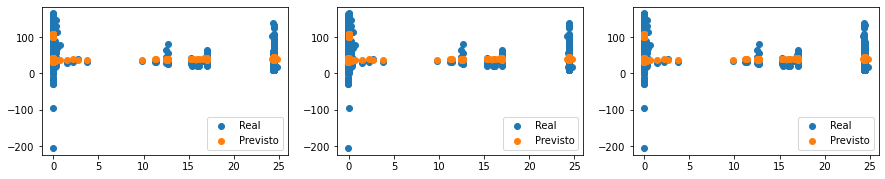

```
--------------------Training Set Metrics--------------------

Training Set R2 ---> 0.285080032490305
Training Set RSS ---> 61781756.95307397
Training Set MSE ---> 344.6723690226217
Training Set RMSE ---> 18.56535399669561

--------------------Test Set Metrics--------------------

Test Set R2 ---> 0.2790004271359964
Test Set RSS ---> 19992776.473948445
Test Set MSE ---> 350.7689259776558
Test Set RMSE ---> 18.728826070463032

--------------------Residuals Plotting--------------------
```

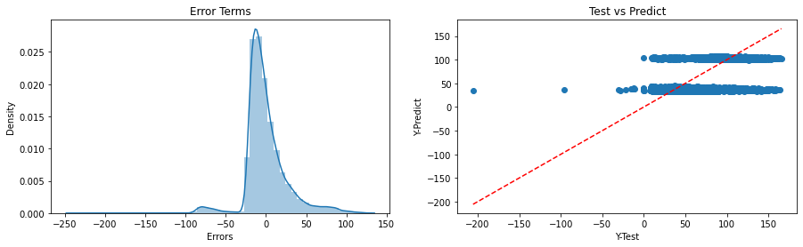

```python
prev1 = API.predict(treino_X)
prev2 = API.predict(teste_X)

print('{}{}\033[1m Evaluating OLS Model \033[0m{}{}\n'.format('<'*3,'-'*25 ,'-'*25,'>'*3))
print('Coefficients: ',API.params[1:])
print('Intercept: ',API.params[0])

avalia_modelo(0, prev1, prev2)
```

*Uber fare estimation*

To estimate the fare, a travel was considered of medium length if it lasted between 20 and 40 minutes. If the patient was a minor, two travelers were considere, if else, only one. All travels were considered to be done in daytime and a random binary was assigned to determine if the call for a trip was put between the 10th and 20th minute of the hour.

```python
def custo_direto_uber(ano, mes, dia, semana_mes, distancia, faixa_etaria, API):
    dia_semana = dt.datetime(int(ano),int(mes), int(dia)).weekday()
    if dia_semana == 6:
        dia_semana_1 = 1
        dia_semana_2 = 0
        dia_semana_3 = 0
    elif dia_semana == 0:
        dia_semana_1 = 0
        dia_semana_2 = 1
        dia_semana_3 = 0
    elif dia_semana == 1:
        dia_semana_1 = 0
        dia_semana_2 = 0
        dia_semana_3 = 1
    else:
        dia_semana_1 = 0
        dia_semana_2 = 0
        dia_semana_3 = 0

    if mes == 2:
        mes_02 = 1
        mes_06 = 0
        mes_07 = 0
        mes_08 = 0
        mes_10 = 0
        mes_11 = 0
        mes_12 = 0
    elif mes == 6:
        mes_02 = 0
        mes_06 = 1
        mes_07 = 0
        mes_08 = 0
        mes_10 = 0
        mes_11 = 0
        mes_12 = 0
    elif mes == 7:
        mes_02 = 0
        mes_06 = 0
        mes_07 = 1
        mes_08 = 0
        mes_10 = 0
        mes_11 = 0
        mes_12 = 0
    elif mes == 8:
        mes_02 = 0
        mes_06 = 0
        mes_07 = 0
        mes_08 = 1
        mes_10 = 0
        mes_11 = 0
        mes_12 = 0
    elif mes == 10:
        mes_02 = 0
        mes_06 = 0
        mes_07 = 0
        mes_08 = 0
        mes_10 = 1
        mes_11 = 0
        mes_12 = 0
    elif mes == 11:
        mes_02 = 0
        mes_06 = 0
        mes_07 = 0
        mes_08 = 0
        mes_10 = 0
        mes_11 = 1
        mes_12 = 0
    elif mes == 12:
        mes_02 = 0
        mes_06 = 0
        mes_07 = 0
        mes_08 = 0
        mes_10 = 0
        mes_11 = 0
        mes_12 = 1
    else:
        mes_02 = 0
        mes_06 = 0
        mes_07 = 0
        mes_08 = 0
        mes_10 = 0
        mes_11 = 0
        mes_12 = 0

    if semana_mes == 1:
        semana_mes_1 = 1
    else:
        semana_mes_1 = 0

    if tempo > 20 and tempo <=40:
        viagem_media = 1
    else:
        viagem_media = 0

    if faixa_etaria == 1:
        passageiros_2 = 1
        passageiros_3 = 0
        passageiros_4 = 0
    else:
        passageiros_2 = 0
        passageiros_3 = 0
        passageiros_4 = 0

    decil_hora_2 = random.choice([0,1])
    dist = distancia
    ano = int(ano)
    noite = 0

    data = pd.DataFrame({'dist': dist,
                        'ano': ano,
                        'mes_02': mes_02,
                        'mes_06': mes_06,
                        'mes_07': mes_07,
                        'mes_08': mes_08,
                        'mes_10': mes_10,
                        'mes_11': mes_11,
                        'mes_12': mes_12,
                        'viagem_media': viagem_media,
                        'semana_mes_1': semana_mes_1,
                        'noite': noite,
                        'passageiros_2': passageiros_2,
                        'passageiros_3': passageiros_3,
                        'passageiros_4': passageiros_4,
                        'dia_semana_1': dia_semana_1,
                        'dia_semana_2': dia_semana_2,
                        'dia_semana_3': dia_semana_3,
                        'decil_hora_2': decil_hora_2},
                       index =[0])
    return API.predict(data).squeeze() if API.predict(data).squeeze() > 7 else 7
```

###### Lift

Same costs as own vehicle.

###### By foot and SUS car

These two means of transportation were considered to have only indirect costs associated.

##### Food and lodging (caregiver)

The expenditures associated with those two items were considered as a daily fraction of the monthly minimum wage per year, in 2019 prices. The formula is:

expenditure = (days of hospitalization/30 days in a month)  
X monthly minnimum wage

```python
def custo_hospedagem_alimentacao(ano, dias, df_salario):
    salario = df_salario.query(f"ano == '{ano}'")['salario_minimo'].squeeze()
    proporcao_internacao = dias/30
    return proporcao_internacao*salario
```

```python
df['food_lodging_expenditures'] = 0

for i in df.index:
    if df.at[i,'internacao'] == '1' and df.at[i, 'acompanhante_internacao'] == '1':
        ano = df.at[i,'ano_malaria']
        dias = df.at[i, 'dias_acompanhante_internacao']
        df.at[i, 'food_lodging_expenditures'] = custo_hospedagem_alimentacao(ano, dias, df_minimum)
df.drop(['hospedagem_acompanhante_internacao'], axis = 1, inplace = True)
df.head()
```

|  | id_domicilio | zona | municipio | trabalho_mal | tipo_trabalho_mal | pecuaria_mal | tipo_pecuaria | agricultura_mal | tipo_agricultura | pesca_mal | ... | ano_malaria | mes_malaria | dia_malaria | uf | semana_mes_malaria | faixa_etaria | prevention_expenditures | exams_expenditures | appointmements_ambulatorial_expenditures | food_lodging_expenditures |
| --- | --- | --- | --- | --- | --- | --- | --- | --- | --- | --- | --- | --- | --- | --- | --- | --- | --- | --- | --- | --- | --- |
| 0 | 1 | 2 | 1 | 1 | 2 | 3 | nan | 3 | nan | 2 | ... | 2022 | 1 | 15 | 11 | 3 | 3 | 106.57 | 0.00 | 0.00 | 0.00 |
| 1 | 2 | 2 | 1 | 3 | nan | 3 | nan | 3 | nan | 3 | ... | 2022 | 1 | 15 | 11 | 3 | 1 | 71.05 | 0.00 | 0.00 | 0.00 |
| 2 | 3 | 2 | 1 | 1 | 2 | 2 | nan | 2 | nan | 2 | ... | 2022 | 2 | 15 | 11 | 3 | 3 | 82.89 | 0.00 | 0.00 | 0.00 |
| 3 | 4 | 2 | 1 | 1 | 2 | 3 | nan | 3 | nan | 3 | ... | 2020 | 12 | 12 | 11 | 2 | 3 | 35.52 | 0.00 | 0.00 | 0.00 |
| 4 | 5 | 2 | 1 | 1 | 2 | 3 | nan | 1 | 3 | 1 | ... | 2021 | 8 | 20 | 11 | 3 | 3 | 47.36 | 0.00 | 0.00 | 0.00 |

5 rows × 90 columns

```python
df['food_lodging_expenditures'][df.food_lodging_expenditures > 0].describe()
```

```
count                  49.00
mean                  114.58
std                   118.41
min                    33.13
25%                    33.49
50%                    67.10
75%                   100.65
max                   497.00
Name: food_lodging_expenditures, dtype: float64
```

### Indirect expenditures

The Indirect expenditures considered are:

- Opportunity cost (time spent seeking care);
- Absenteeism from work (patient):
  - Main activity,
  - Other productive activities.
- Absenteeism from school (patient),
- Absenteeism from work (caregiver).

#### Opportunity cost (time spent seeking care)/absenteeism from school and main work activity

The opportunity cost/absenteeism is evaluated differently for adult and minor patients.

##### Minor patients

For minor patients, the hourly wage is evaluated as the hourly transfer from the Federal Government through FUNDEB (Fundo de Desenvolvimento da Educação Básica - Fund for the Development of Basic Education), according to year, State, zone of living (rural/urban) and level of education.

##### Adult patients

For adults, the hourly wage is evaluated as the hourly average salary, by year and State, derived from data of the first visit (5th in pandemic years: 2020/21) PNAD Contínua (Pesquisa Nacional por Amostragem de Domícilios - Continuous National Survey by Household Sampling), deflated to 2019 prices.

##### Opportunity cost estimation

Now it's possible to establish an opportunity cost function.

```python
def custo_oportunidade(ano, uf, zona, idade, faixa_etaria, tempo, sexo, df_pnad, df_fundeb):
    if faixa_etaria == '1':
        if idade <= 3:
            valor_menor = df_fundeb.query(f"ano == '{ano}' & zona == '{zona}' & uf == '{uf}'")['creche'].squeeze()
        elif idade >= 4 and idade <= 5:
            valor_menor = df_fundeb.query(f"ano == '{ano}' & zona == '{zona}' & uf == '{uf}'")['pre_escola'].squeeze()
        elif idade >= 6 and idade <=10:
            valor_menor = df_fundeb.query(f"ano == '{ano}' & zona == '{zona}' & uf == '{uf}'")['fundamental_I'].squeeze()
        elif idade >= 11 and idade <=14:
            valor_menor = df_fundeb.query(f"ano == '{ano}' & zona == '{zona}' & uf == '{uf}'")['fundamental_II'].squeeze()
        else:
            valor_menor = df_fundeb.query(f"ano == '{ano}' & zona == '{zona}' & uf == '{uf}'")['medio'].squeeze()

        valor_acompanhante = df_pnad.query(f"ano == '{ano}' & uf == '{uf}' & zona == '{zona}' & sexo == '{sexo}'")['salario_hora'].squeeze()
        valor = valor_menor + valor_acompanhante
    else:
        valor = df_pnad.query(f"ano == '{ano}' & uf == '{uf}' & zona == '{zona}' & sexo == '{sexo}'")['salario_hora'].squeeze()
    return valor*tempo
```

With the above definitions, it is now possible to estimate the direct and indirect expenditures with transportation.

```python
df[['custo_direto_transporte_postinho_a_pe',
    'custo_indireto_transporte_postinho_a_pe',
    'custo_direto_transporte_postinho_onibus',
    'custo_indireto_transporte_postinho_onibus',
    'custo_direto_transporte_postinho_veiculo_proprio',
    'custo_indireto_transporte_postinho_veiculo_proprio',
    'custo_direto_transporte_postinho_carona',
    'custo_indireto_transporte_postinho_carona',
    'custo_direto_transporte_postinho_taxi',
    'custo_indireto_transporte_postinho_taxi',
    'custo_direto_transporte_postinho_uber',
    'custo_indireto_transporte_postinho_uber',
    'custo_direto_transporte_postinho_barco',
    'custo_indireto_transporte_postinho_barco',
    'custo_direto_transporte_postinho_sus',
    'custo_indireto_transporte_postinho_sus',
    'custo_direto_transporte_ubs_a_pe',
    'custo_indireto_transporte_ubs_a_pe',
    'custo_direto_transporte_ubs_onibus',
    'custo_indireto_transporte_ubs_onibus',
    'custo_direto_transporte_ubs_veiculo_proprio',
    'custo_indireto_transporte_ubs_veiculo_proprio',
    'custo_direto_transporte_ubs_carona',
    'custo_indireto_transporte_ubs_carona',
    'custo_direto_transporte_ubs_taxi',
    'custo_indireto_transporte_ubs_taxi',
    'custo_direto_transporte_ubs_uber',
    'custo_indireto_transporte_ubs_uber',
    'custo_direto_transporte_ubs_barco',
    'custo_indireto_transporte_ubs_barco',
    'custo_direto_transporte_ubs_sus',
    'custo_indireto_transporte_ubs_sus',
   'custo_direto_transporte_upa_a_pe',
    'custo_indireto_transporte_upa_a_pe',
    'custo_direto_transporte_upa_onibus',
    'custo_indireto_transporte_upa_onibus',
    'custo_direto_transporte_upa_veiculo_proprio',
    'custo_indireto_transporte_upa_veiculo_proprio',
    'custo_direto_transporte_upa_carona',
    'custo_indireto_transporte_upa_carona',
    'custo_direto_transporte_upa_taxi',
    'custo_indireto_transporte_upa_taxi',
    'custo_direto_transporte_upa_uber',
    'custo_indireto_transporte_upa_uber',
    'custo_direto_transporte_upa_barco',
    'custo_indireto_transporte_upa_barco',
    'custo_direto_transporte_upa_sus',
    'custo_indireto_transporte_upa_sus',
   'custo_direto_transporte_hospital_particular_a_pe',
    'custo_indireto_transporte_hospital_particular_a_pe',
    'custo_direto_transporte_hospital_particular_onibus',
    'custo_indireto_transporte_hospital_particular_onibus',
    'custo_direto_transporte_hospital_particular_veiculo_proprio',
    'custo_indireto_transporte_hospital_particular_veiculo_proprio',
    'custo_direto_transporte_hospital_particular_carona',
    'custo_indireto_transporte_hospital_particular_carona',
    'custo_direto_transporte_hospital_particular_taxi',
    'custo_indireto_transporte_hospital_particular_taxi',
    'custo_direto_transporte_hospital_particular_uber',
    'custo_indireto_transporte_hospital_particular_uber',
    'custo_direto_transporte_hospital_particular_barco',
    'custo_indireto_transporte_hospital_particular_barco',
    'custo_direto_transporte_hospital_particular_sus',
    'custo_indireto_transporte_hospital_particular_sus',
   'custo_direto_transporte_clinica_particular_a_pe',
    'custo_indireto_transporte_clinica_particular_a_pe',
    'custo_direto_transporte_clinica_particular_onibus',
    'custo_indireto_transporte_clinica_particular_onibus',
    'custo_direto_transporte_clinica_particular_veiculo_proprio',
    'custo_indireto_transporte_clinica_particular_veiculo_proprio',
    'custo_direto_transporte_clinica_particular_carona',
    'custo_indireto_transporte_clinica_particular_carona',
    'custo_direto_transporte_clinica_particular_taxi',
    'custo_indireto_transporte_clinica_particular_taxi',
    'custo_direto_transporte_clinica_particular_uber',
    'custo_indireto_transporte_clinica_particular_uber',
    'custo_direto_transporte_clinica_particular_barco',
    'custo_indireto_transporte_clinica_particular_barco',
    'custo_direto_transporte_clinica_particular_sus',
    'custo_indireto_transporte_clinica_particular_sus']] = np.nan

colunas_meio = ['meio_transporte_postinho', 'meio_transporte_ubs', 'meio_transporte_upa', 'meio_transporte_hospital_particular', 'meio_transporte_clinica_particular']
colunas_tempo = ['tempo_transporte_postinho', 'tempo_transporte_ubs', 'tempo_transporte_upa', 'tempo_transporte_hospital_particular', 'tempo_transporte_clinica_particular']
```

```python
for i in df.index:
    if df.at[i,'exame_tratamento'] == '1':
        for coluna_meio, coluna_tempo in zip(df[colunas_meio], df[colunas_tempo]):
            if pd.isna(df.at[i,coluna_meio]):
                continue
            else:
                ano = df.at[i,'ano_malaria']
                mes = df.at[i,'mes_malaria']
                dia = df.at[i,'dia_malaria']
                semana_mes = df.at[i,'semana_mes_malaria']
                uf = df.at[i,'uf']
                zona = df.at[i,'zona']
                sexo = df.at[i,'sexo']
                faixa_etaria = df.at[i,'faixa_etaria']
                idade = df.at[i,'idade']
                distancia = df.at[i, coluna_tempo]
                tempo = df.at[i, coluna_tempo]/60
                nucleo = coluna_meio[4:]

                if df.at[i,coluna_meio] == '1':
                    coluna_custo_direto = 'custo_direto' + nucleo + '_a_pe'
                    coluna_custo_indireto = 'custo_indireto' + nucleo + '_a_pe'
                    df.at[i,coluna_custo_direto] = np.nan
                    df.at[i,coluna_custo_indireto] = custo_oportunidade(ano, uf, zona, idade, faixa_etaria, tempo, sexo, df_pnad, df_fundeb)

                if df.at[i,coluna_meio] == '2':
                    coluna_custo_direto = 'custo_direto' + nucleo + '_onibus'
                    coluna_custo_indireto = 'custo_indireto' + nucleo + '_onibus'
                    df.at[i,coluna_custo_direto] = custo_direto_onibus(ano, mes, uf, faixa_etaria, df_bus)
                    df.at[i,coluna_custo_indireto] = custo_oportunidade(ano, uf, zona, idade, faixa_etaria, tempo, sexo, df_pnad, df_fundeb)

                elif df.at[i,coluna_meio] == '3':
                    coluna_custo_direto = 'custo_direto' + nucleo + '_veiculo_proprio'
                    coluna_custo_indireto = 'custo_indireto' + nucleo + '_veiculo_proprio'
                    df.at[i,coluna_custo_direto] = custo_direto_veiculo_proprio(ano, mes, uf, distancia, df_vehicle, df_gasoline)
                    df.at[i,coluna_custo_indireto] = custo_oportunidade(ano, uf, zona, idade, faixa_etaria, tempo, sexo, df_pnad, df_fundeb)

                elif df.at[i,coluna_meio] == '4':
                    coluna_custo_direto = 'custo_direto' + nucleo + '_carona'
                    coluna_custo_indireto = 'custo_indireto' + nucleo + '_carona'
                    df.at[i,coluna_custo_direto] = custo_direto_veiculo_proprio(ano, mes, uf, distancia, df_vehicle, df_gasoline)
                    custo_oportunidade_passageiro = custo_oportunidade(ano, uf, zona, idade, faixa_etaria, tempo, sexo, df_pnad, df_fundeb)
                    faixa_etaria_caroneiro = random.choice(['2','3'])
                    if faixa_etaria_caroneiro == '2':
                        idade_caroneiro = 37.5
                    else:
                         idade_caroneiro = 67.5
                    sexo_caroneiro = random.choice(['1','2'])
                    custo_oportunidade_caroneiro = custo_oportunidade(ano, uf, zona, idade_caroneiro, faixa_etaria_caroneiro, tempo, sexo_caroneiro, df_pnad, df_fundeb)
                    df.at[i,coluna_custo_indireto] = custo_oportunidade_passageiro + custo_oportunidade_caroneiro

                elif df.at[i,coluna_meio] == '5':
                    coluna_custo_direto = 'custo_direto' + nucleo + '_taxi'
                    coluna_custo_indireto = 'custo_indireto' + nucleo + '_taxi'
                    df.at[i,coluna_custo_direto] = custo_direto_taxi(ano, mes, uf, distancia, df_cab)
                    df.at[i,coluna_custo_indireto] = custo_oportunidade(ano, uf, zona, idade, faixa_etaria, tempo, sexo, df_pnad, df_fundeb)

                elif df.at[i,coluna_meio] == '6':
                    coluna_custo_direto = 'custo_direto' + nucleo + '_uber'
                    coluna_custo_indireto = 'custo_indireto' + nucleo + '_uber'
                    df.at[i,coluna_custo_direto] = custo_direto_uber(ano, mes, dia, semana_mes, distancia, faixa_etaria, API)
                    df.at[i,coluna_custo_indireto] = custo_oportunidade(ano, uf, zona, idade, faixa_etaria, tempo, sexo, df_pnad, df_fundeb)

                elif df.at[i,coluna_meio] == '7':
                    coluna_custo_direto = 'custo_direto' + nucleo + '_barco'
                    coluna_custo_indireto = 'custo_indireto' + nucleo + '_barco'
                    df.at[i,coluna_custo_direto] = custo_direto_barco(ano, mes, uf, tempo, boat_consumption, df_gasoline)
                    df.at[i,coluna_custo_indireto] = custo_oportunidade(ano, uf, zona, idade, faixa_etaria, tempo, sexo, df_pnad, df_fundeb)

                else:
                    coluna_custo_direto = 'custo_direto' + nucleo + '_sus'
                    coluna_custo_indireto = 'custo_indireto' + nucleo + '_sus'
                    df.at[i,coluna_custo_direto] = np.nan
                    df.at[i,coluna_custo_indireto] = custo_oportunidade(ano, uf, zona, idade, faixa_etaria, tempo, sexo, df_pnad, df_fundeb)
    else:
        continue
```

```python
df[['custo_direto_transporte_acompanhante_internacao_a_pe',
    'custo_indireto_transporte_acompanhante_internacao_a_pe',
    'custo_direto_transporte_acompanhante_internacao_onibus',
    'custo_indireto_transporte_acompanhante_internacao_onibus',
    'custo_direto_transporte_acompanhante_internacao_veiculo_proprio',
    'custo_indireto_transporte_acompanhante_internacao_veiculo_proprio',
    'custo_direto_transporte_acompanhante_internacao_carona',
    'custo_indireto_transporte_acompanhante_internacao_carona',
    'custo_direto_transporte_acompanhante_internacao_taxi',
    'custo_indireto_transporte_acompanhante_internacao_taxi',
    'custo_direto_transporte_acompanhante_internacao_uber',
    'custo_indireto_transporte_acompanhante_internacao_uber',
    'custo_direto_transporte_acompanhante_internacao_barco',
    'custo_indireto_transporte_acompanhante_internacao_barco',
    'custo_direto_transporte_acompanhante_internacao_sus',
    'custo_indireto_transporte_acompanhante_internacao_sus']] = np.nan
```

```python
for i in df.index:
    if df.at[i,'internacao'] == '1' and df.at[i, 'acompanhante_internacao'] == '1':
        if pd.isna(df.at[i,'meio_transporte_acompanhante_internacao']):
            continue
        else:
            ano = df.at[i,'ano_malaria']
            mes = df.at[i,'mes_malaria']
            dia = df.at[i,'dia_malaria']
            semana_mes = df.at[i,'semana_mes_malaria']
            uf = df.at[i,'uf']
            zona = df.at[i,'zona']
            sexo = df.at[i,'sexo']
            faixa_etaria = df.at[i,'faixa_etaria']
            idade = df.at[i,'idade']
            if pd.isna(df.at[i, 'tempo_transporte_acompanhante_internacao']):
                distancia = np.nanmedian(df['tempo_transporte_acompanhante_internacao'])
            else:
                distancia = df.at[i, 'tempo_transporte_acompanhante_internacao']
            tempo = df.at[i, 'tempo_transporte_acompanhante_internacao']/60
            nucleo = '_transporte_acompanhante_internacao'

            if df.at[i,'meio_transporte_acompanhante_internacao'] == '1':
                coluna_custo_direto = 'custo_direto' + nucleo + '_a_pe'
                coluna_custo_indireto = 'custo_indireto' + nucleo + '_a_pe'
                df.at[i,coluna_custo_direto] = np.nan
                df.at[i,coluna_custo_indireto] = custo_oportunidade(ano, uf, zona, idade, faixa_etaria, tempo, sexo, df_pnad, df_fundeb)

            if df.at[i,'meio_transporte_acompanhante_internacao'] == '2':
                coluna_custo_direto = 'custo_direto' + nucleo + '_onibus'
                coluna_custo_indireto = 'custo_indireto' + nucleo + '_onibus'
                df.at[i,coluna_custo_direto] = custo_direto_onibus(ano, mes, uf, faixa_etaria, df_bus)
                df.at[i,coluna_custo_indireto] = custo_oportunidade(ano, uf, zona, idade, faixa_etaria, tempo, sexo, df_pnad, df_fundeb)

            elif df.at[i,'meio_transporte_acompanhante_internacao'] == '3':
                coluna_custo_direto = 'custo_direto' + nucleo + '_veiculo_proprio'
                coluna_custo_indireto = 'custo_indireto' + nucleo + '_veiculo_proprio'
                df.at[i,coluna_custo_direto] = custo_direto_veiculo_proprio(ano, mes, uf, distancia, df_vehicle, df_gasoline)
                df.at[i,coluna_custo_indireto] = custo_oportunidade(ano, uf, zona, idade, faixa_etaria, tempo, sexo, df_pnad, df_fundeb)

            elif df.at[i,'meio_transporte_acompanhante_internacao'] == '4':
                coluna_custo_direto = 'custo_direto' + nucleo + '_carona'
                coluna_custo_indireto = 'custo_indireto' + nucleo + '_carona'
                df.at[i,coluna_custo_direto] = custo_direto_veiculo_proprio(ano, mes, uf, distancia, df_vehicle, df_gasoline)
                custo_oportunidade_passageiro = custo_oportunidade(ano, uf, zona, idade, faixa_etaria, tempo, sexo, df_pnad, df_fundeb)
                faixa_etaria_caroneiro = random.choice(['2','3'])
                if faixa_etaria_caroneiro == '2':
                    idade_caroneiro = 37.5
                else:
                     idade_caroneiro = 67.5
                sexo_caroneiro = random.choice(['1','2'])
                custo_oportunidade_caroneiro = custo_oportunidade(ano, uf, zona, idade_caroneiro, faixa_etaria_caroneiro, tempo, sexo_caroneiro, df_pnad, df_fundeb)
                df.at[i,coluna_custo_indireto] = custo_oportunidade_passageiro + custo_oportunidade_caroneiro

            elif df.at[i,'meio_transporte_acompanhante_internacao'] == '5':
                coluna_custo_direto = 'custo_direto' + nucleo + '_taxi'
                coluna_custo_indireto = 'custo_indireto' + nucleo + '_taxi'
                df.at[i,coluna_custo_direto] = custo_direto_taxi(ano, mes, uf, distancia, df_cab)
                df.at[i,coluna_custo_indireto] = custo_oportunidade(ano, uf, zona, idade, faixa_etaria, tempo, sexo, df_pnad, df_fundeb)

            elif df.at[i,'meio_transporte_acompanhante_internacao'] == '6':
                coluna_custo_direto = 'custo_direto' + nucleo + '_uber'
                coluna_custo_indireto = 'custo_indireto' + nucleo + '_uber'
                df.at[i,coluna_custo_direto] = custo_direto_uber(ano, mes, dia, semana_mes, distancia, faixa_etaria, API)
                df.at[i,coluna_custo_indireto] = custo_oportunidade(ano, uf, zona, idade, faixa_etaria, tempo, sexo, df_pnad, df_fundeb)

            elif df.at[i,'meio_transporte_acompanhante_internacao'] == '7':
                coluna_custo_direto = 'custo_direto' + nucleo + '_barco'
                coluna_custo_indireto = 'custo_indireto' + nucleo + '_barco'
                df.at[i,coluna_custo_direto] = custo_direto_barco(ano, mes, uf, tempo, boat_consumption, df_gasoline)
                df.at[i,coluna_custo_indireto] = custo_oportunidade(ano, uf, zona, idade, faixa_etaria, tempo, sexo, df_pnad, df_fundeb)

            else:
                coluna_custo_direto = 'custo_direto' + nucleo + '_sus'
                coluna_custo_indireto = 'custo_indireto' + nucleo + '_sus'
                df.at[i,coluna_custo_direto] = np.nan
                df.at[i,coluna_custo_indireto] = custo_oportunidade(ano, uf, zona, idade, faixa_etaria, tempo, sexo, df_pnad, df_fundeb)
    else:
        continue
```

```python
df['custo_direto_transporte_a_pe'] = df[['custo_direto_transporte_postinho_a_pe','custo_direto_transporte_ubs_a_pe','custo_direto_transporte_upa_a_pe','custo_direto_transporte_hospital_particular_a_pe','custo_direto_transporte_clinica_particular_a_pe','custo_direto_transporte_acompanhante_internacao_a_pe']].sum(axis = 1)
df['custo_indireto_transporte_a_pe'] = df[['custo_indireto_transporte_postinho_a_pe','custo_indireto_transporte_ubs_a_pe','custo_indireto_transporte_upa_a_pe','custo_indireto_transporte_hospital_particular_a_pe','custo_indireto_transporte_clinica_particular_a_pe','custo_indireto_transporte_acompanhante_internacao_a_pe']].sum(axis = 1)
df['custo_direto_transporte_onibus'] = df[['custo_direto_transporte_postinho_onibus','custo_direto_transporte_ubs_onibus','custo_direto_transporte_upa_onibus','custo_direto_transporte_hospital_particular_onibus','custo_direto_transporte_clinica_particular_onibus','custo_direto_transporte_acompanhante_internacao_onibus']].sum(axis = 1)
df['custo_indireto_transporte_onibus'] = df[['custo_indireto_transporte_postinho_onibus','custo_indireto_transporte_ubs_onibus','custo_indireto_transporte_upa_onibus','custo_indireto_transporte_hospital_particular_onibus','custo_indireto_transporte_clinica_particular_onibus','custo_indireto_transporte_acompanhante_internacao_onibus']].sum(axis = 1)
df['custo_direto_transporte_veiculo_proprio'] = df[['custo_direto_transporte_postinho_veiculo_proprio','custo_direto_transporte_ubs_veiculo_proprio','custo_direto_transporte_upa_veiculo_proprio','custo_direto_transporte_hospital_particular_veiculo_proprio','custo_direto_transporte_clinica_particular_veiculo_proprio','custo_direto_transporte_acompanhante_internacao_veiculo_proprio']].sum(axis = 1)
df['custo_indireto_transporte_veiculo_proprio'] = df[['custo_indireto_transporte_postinho_veiculo_proprio','custo_indireto_transporte_ubs_veiculo_proprio','custo_indireto_transporte_upa_veiculo_proprio','custo_indireto_transporte_hospital_particular_veiculo_proprio','custo_indireto_transporte_clinica_particular_veiculo_proprio','custo_indireto_transporte_acompanhante_internacao_veiculo_proprio']].sum(axis = 1)
df['custo_direto_transporte_carona'] = df[['custo_direto_transporte_postinho_carona','custo_direto_transporte_ubs_carona','custo_direto_transporte_upa_carona','custo_direto_transporte_hospital_particular_carona','custo_direto_transporte_clinica_particular_carona','custo_direto_transporte_acompanhante_internacao_carona']].sum(axis = 1)
df['custo_indireto_transporte_carona'] = df[['custo_indireto_transporte_postinho_carona','custo_indireto_transporte_ubs_carona','custo_indireto_transporte_upa_carona','custo_indireto_transporte_hospital_particular_carona','custo_indireto_transporte_clinica_particular_carona','custo_indireto_transporte_acompanhante_internacao_carona']].sum(axis = 1)
df['custo_direto_transporte_taxi'] = df[['custo_direto_transporte_postinho_taxi','custo_direto_transporte_ubs_taxi','custo_direto_transporte_upa_taxi','custo_direto_transporte_hospital_particular_taxi','custo_direto_transporte_clinica_particular_taxi','custo_direto_transporte_acompanhante_internacao_taxi']].sum(axis = 1)
df['custo_indireto_transporte_taxi'] = df[['custo_indireto_transporte_postinho_taxi','custo_indireto_transporte_ubs_taxi','custo_indireto_transporte_upa_taxi','custo_indireto_transporte_hospital_particular_taxi','custo_indireto_transporte_clinica_particular_taxi','custo_indireto_transporte_acompanhante_internacao_taxi']].sum(axis = 1)
df['custo_direto_transporte_uber'] = df[['custo_direto_transporte_postinho_uber','custo_direto_transporte_ubs_uber','custo_direto_transporte_upa_uber','custo_direto_transporte_hospital_particular_uber','custo_direto_transporte_clinica_particular_uber','custo_direto_transporte_acompanhante_internacao_uber']].sum(axis = 1)
df['custo_indireto_transporte_uber'] = df[['custo_indireto_transporte_postinho_uber','custo_indireto_transporte_ubs_uber','custo_indireto_transporte_upa_uber','custo_indireto_transporte_hospital_particular_uber','custo_indireto_transporte_clinica_particular_uber','custo_indireto_transporte_acompanhante_internacao_uber']].sum(axis = 1)
df['custo_direto_transporte_barco'] = df[['custo_direto_transporte_postinho_barco','custo_direto_transporte_ubs_barco','custo_direto_transporte_upa_barco','custo_direto_transporte_hospital_particular_barco','custo_direto_transporte_clinica_particular_barco','custo_direto_transporte_acompanhante_internacao_barco']].sum(axis = 1)
df['custo_indireto_transporte_barco'] = df[['custo_indireto_transporte_postinho_barco','custo_indireto_transporte_ubs_barco','custo_indireto_transporte_upa_barco','custo_indireto_transporte_hospital_particular_barco','custo_indireto_transporte_clinica_particular_barco','custo_indireto_transporte_acompanhante_internacao_barco']].sum(axis = 1)
df['custo_direto_transporte_sus'] = df[['custo_direto_transporte_postinho_sus','custo_direto_transporte_ubs_sus','custo_direto_transporte_upa_sus','custo_direto_transporte_hospital_particular_sus','custo_direto_transporte_clinica_particular_sus','custo_direto_transporte_acompanhante_internacao_sus']].sum(axis = 1)
df['custo_indireto_transporte_sus'] = df[['custo_indireto_transporte_postinho_sus','custo_indireto_transporte_ubs_sus','custo_indireto_transporte_upa_sus','custo_indireto_transporte_hospital_particular_sus','custo_indireto_transporte_clinica_particular_sus','custo_indireto_transporte_acompanhante_internacao_sus']].sum(axis = 1)
```

*Indirect transport expenditures by foot*

```python
df['indirect_transport_expenditures_by_foot'] = 2*df['custo_indireto_transporte_a_pe']
df['indirect_transport_expenditures_by_foot'][df.indirect_transport_expenditures_by_foot > 0].describe()
```

```
count                 272.00
mean                    4.84
std                     7.45
min                     0.21
25%                     1.08
50%                     2.11
75%                     5.38
max                    52.18
Name: indirect_transport_expenditures_by_foot, dtype: float64
```

*Direct transport expenditures by bus*

```python
df['direct_transport_expenditures_bus'] = 2*df['custo_direto_transporte_onibus']
df['direct_transport_expenditures_bus'][df.direct_transport_expenditures_bus > 0].describe()
```

```
count                  27.00
mean                    7.91
std                     3.68
min                     5.98
25%                     6.22
50%                     6.54
75%                     7.27
max                    22.90
Name: direct_transport_expenditures_bus, dtype: float64
```

*Indirect transport expenditures by bus*

```python
df['indirect_transport_expenditures_bus'] = 2*df['custo_indireto_transporte_onibus']
df['indirect_transport_expenditures_bus'][df.indirect_transport_expenditures_bus > 0].describe()
```

```
count                  25.00
mean                   29.99
std                    33.37
min                     0.83
25%                     6.93
50%                    18.77
75%                    42.67
max                   127.39
Name: indirect_transport_expenditures_bus, dtype: float64
```

*Direct transport expenditures by own vehicle*

```python
df['direct_transport_expenditures_own_vehicle'] = 2*df['custo_direto_transporte_veiculo_proprio']
df['direct_transport_expenditures_own_vehicle'][df.direct_transport_expenditures_own_vehicle>0].describe()
```

```
count                 393.00
mean                   28.42
std                    75.39
min                     0.80
25%                     4.47
50%                    12.71
75%                    28.59
max                 1,362.65
Name: direct_transport_expenditures_own_vehicle, dtype: float64
```

*Indirect transport expenditures by own vehicle*

```python
df['indirect_transport_expenditures_own_vehicle'] = 2*df['custo_indireto_transporte_veiculo_proprio']
df['indirect_transport_expenditures_own_vehicle'][df.indirect_transport_expenditures_own_vehicle>0].describe()
```

```
count                 392.00
mean                    9.61
std                    27.64
min                     0.18
25%                     1.67
50%                     3.90
75%                    10.30
max                   504.79
Name: indirect_transport_expenditures_own_vehicle, dtype: float64
```

*Direct transport expenditures by lift*

```python
df['direct_transport_expenditures_lift'] = 2*df['custo_direto_transporte_carona']
df['direct_transport_expenditures_lift'][df.direct_transport_expenditures_lift>0].describe()
```

```
count                 106.00
mean                   31.32
std                    39.20
min                     1.34
25%                     8.64
50%                    14.80
75%                    33.01
max                   208.65
Name: direct_transport_expenditures_lift, dtype: float64
```

*Indirect transport expenditures by lift*

```python
df['indirect_transport_expenditures_lift'] = 2*df['custo_indireto_transporte_carona']
df['indirect_transport_expenditures_lift'][df.indirect_transport_expenditures_lift>0].describe()
```

```
count                 106.00
mean                   19.64
std                    24.99
min                     0.74
25%                     4.20
50%                     8.95
75%                    21.08
max                   133.77
Name: indirect_transport_expenditures_lift, dtype: float64
```

*Direct transport expenditures by taxi*

```python
df['direct_transport_expenditures_taxi'] = 2*df['custo_direto_transporte_taxi']
df['direct_transport_expenditures_taxi'][df.direct_transport_expenditures_taxi>0].describe()
```

```
count                  37.00
mean                  106.12
std                   107.14
min                    15.10
25%                    33.75
50%                    72.95
75%                   118.37
max                   516.83
Name: direct_transport_expenditures_taxi, dtype: float64
```

*Indirect transport expenditures by taxi*

```python
df['indirect_transport_expenditures_taxi'] = 2*df['custo_indireto_transporte_taxi']
df['indirect_transport_expenditures_taxi'][df.indirect_transport_expenditures_taxi>0].describe()
```

```
count                  37.00
mean                    4.24
std                     4.11
min                     0.42
25%                     1.25
50%                     3.17
75%                     5.27
max                    18.77
Name: indirect_transport_expenditures_taxi, dtype: float64
```

*Direct transport expenditures by Uber*

```python
df['direct_transport_expenditures_uber'] = 2*df['custo_direto_transporte_uber']
df['direct_transport_expenditures_uber'][df.direct_transport_expenditures_uber>0].describe()
```

```
count                   9.00
mean                  105.38
std                    53.91
min                    14.00
25%                    83.92
50%                    85.59
75%                   168.25
max                   173.16
Name: direct_transport_expenditures_uber, dtype: float64
```

*Indirect transport expenditures by Uber*

```python
df['indirect_transport_expenditures_uber'] = 2*df['custo_indireto_transporte_uber']
df['indirect_transport_expenditures_uber'][df.indirect_transport_expenditures_uber>0].describe()
```

```
count                   8.00
mean                   13.18
std                    12.23
min                     2.03
25%                     6.31
50%                     7.92
75%                    16.86
max                    38.79
Name: indirect_transport_expenditures_uber, dtype: float64
```

*Direct transport expenditures by boat*

```python
df['direct_transport_expenditures_boat'] = 2*df['custo_direto_transporte_barco']
df['direct_transport_expenditures_boat'][df.direct_transport_expenditures_boat>0].describe()
```

```
count                  26.00
mean                   98.76
std                   119.24
min                     1.63
25%                    10.92
50%                    31.80
75%                   196.66
max                   393.32
Name: direct_transport_expenditures_boat, dtype: float64
```

*Indirect transport expenditures by boat*

```python
df['indirect_transport_expenditures_boat'] = 2*df['custo_indireto_transporte_barco']
df['indirect_transport_expenditures_boat'][df.indirect_transport_expenditures_boat>0].describe()
```

```
count                  26.00
mean                   18.98
std                    34.55
min                     0.42
25%                     1.36
50%                     7.33
75%                    26.67
max                   172.82
Name: indirect_transport_expenditures_boat, dtype: float64
```

*Indirect transport expenditures by SUS vehicle*

```python
df['indirect_transport_expenditures_sus'] = 2*df['custo_indireto_transporte_sus']
df['indirect_transport_expenditures_sus'][df.indirect_transport_expenditures_sus>0].describe()
```

```
count                 303.00
mean                    5.10
std                     7.73
min                     0.21
25%                     1.14
50%                     2.32
75%                     5.60
max                    52.18
Name: indirect_transport_expenditures_sus, dtype: float64
```

```python
df.drop(['exame_tratamento',
        'laboratorio_postinho',
        'ubs',
        'upa',
        'consultorio_particular',
        'pa_privado',
        'domiciliar_privado',
        'domiciliar_publico',
        'n_sabe_atendimento',
        'meio_transporte_postinho',
         'meio_transporte_ubs',
         'meio_transporte_upa',
         'meio_transporte_hospital_particular',
         'meio_transporte_clinica_particular',
         'meio_transporte_curandeiro',
         'meio_transporte_acompanhante_internacao',
         'tempo_transporte_postinho',
         'tempo_transporte_ubs',
         'tempo_transporte_upa',
         'tempo_transporte_hospital_particular',
         'tempo_transporte_clinica_particular',
         'tempo_transporte_curandeiro',
         'tempo_transporte_acompanhante_internacao',
         'custo_direto_transporte_postinho_a_pe',
        'custo_indireto_transporte_postinho_a_pe',
        'custo_direto_transporte_postinho_onibus',
        'custo_indireto_transporte_postinho_onibus',
        'custo_direto_transporte_postinho_veiculo_proprio',
        'custo_indireto_transporte_postinho_veiculo_proprio',
        'custo_direto_transporte_postinho_carona',
        'custo_indireto_transporte_postinho_carona',
        'custo_direto_transporte_postinho_taxi',
        'custo_indireto_transporte_postinho_taxi',
        'custo_direto_transporte_postinho_uber',
        'custo_indireto_transporte_postinho_uber',
        'custo_direto_transporte_postinho_barco',
        'custo_indireto_transporte_postinho_barco',
        'custo_direto_transporte_postinho_sus',
        'custo_indireto_transporte_postinho_sus',
        'custo_direto_transporte_ubs_a_pe',
        'custo_indireto_transporte_ubs_a_pe',
        'custo_direto_transporte_ubs_onibus',
        'custo_indireto_transporte_ubs_onibus',
        'custo_direto_transporte_ubs_veiculo_proprio',
        'custo_indireto_transporte_ubs_veiculo_proprio',
        'custo_direto_transporte_ubs_carona',
        'custo_indireto_transporte_ubs_carona',
        'custo_direto_transporte_ubs_taxi',
        'custo_indireto_transporte_ubs_taxi',
        'custo_direto_transporte_ubs_uber',
        'custo_indireto_transporte_ubs_uber',
        'custo_direto_transporte_ubs_barco',
        'custo_indireto_transporte_ubs_barco',
        'custo_direto_transporte_ubs_sus',
        'custo_indireto_transporte_ubs_sus',
       'custo_direto_transporte_upa_a_pe',
        'custo_indireto_transporte_upa_a_pe',
        'custo_direto_transporte_upa_onibus',
        'custo_indireto_transporte_upa_onibus',
        'custo_direto_transporte_upa_veiculo_proprio',
        'custo_indireto_transporte_upa_veiculo_proprio',
        'custo_direto_transporte_upa_carona',
        'custo_indireto_transporte_upa_carona',
        'custo_direto_transporte_upa_taxi',
        'custo_indireto_transporte_upa_taxi',
        'custo_direto_transporte_upa_uber',
        'custo_indireto_transporte_upa_uber',
        'custo_direto_transporte_upa_barco',
        'custo_indireto_transporte_upa_barco',
        'custo_direto_transporte_upa_sus',
        'custo_indireto_transporte_upa_sus',
       'custo_direto_transporte_hospital_particular_a_pe',
        'custo_indireto_transporte_hospital_particular_a_pe',
        'custo_direto_transporte_hospital_particular_onibus',
        'custo_indireto_transporte_hospital_particular_onibus',
        'custo_direto_transporte_hospital_particular_veiculo_proprio',
        'custo_indireto_transporte_hospital_particular_veiculo_proprio',
        'custo_direto_transporte_hospital_particular_carona',
        'custo_indireto_transporte_hospital_particular_carona',
        'custo_direto_transporte_hospital_particular_taxi',
        'custo_indireto_transporte_hospital_particular_taxi',
        'custo_direto_transporte_hospital_particular_uber',
        'custo_indireto_transporte_hospital_particular_uber',
        'custo_direto_transporte_hospital_particular_barco',
        'custo_indireto_transporte_hospital_particular_barco',
        'custo_direto_transporte_hospital_particular_sus',
        'custo_indireto_transporte_hospital_particular_sus',
       'custo_direto_transporte_clinica_particular_a_pe',
        'custo_indireto_transporte_clinica_particular_a_pe',
        'custo_direto_transporte_clinica_particular_onibus',
        'custo_indireto_transporte_clinica_particular_onibus',
        'custo_direto_transporte_clinica_particular_veiculo_proprio',
        'custo_indireto_transporte_clinica_particular_veiculo_proprio',
        'custo_direto_transporte_clinica_particular_carona',
        'custo_indireto_transporte_clinica_particular_carona',
        'custo_direto_transporte_clinica_particular_taxi',
        'custo_indireto_transporte_clinica_particular_taxi',
        'custo_direto_transporte_clinica_particular_uber',
        'custo_indireto_transporte_clinica_particular_uber',
        'custo_direto_transporte_clinica_particular_barco',
        'custo_indireto_transporte_clinica_particular_barco',
        'custo_direto_transporte_clinica_particular_sus',
        'custo_indireto_transporte_clinica_particular_sus',
        'custo_direto_transporte_acompanhante_internacao_a_pe',
        'custo_indireto_transporte_acompanhante_internacao_a_pe',
        'custo_direto_transporte_acompanhante_internacao_onibus',
        'custo_indireto_transporte_acompanhante_internacao_onibus',
        'custo_direto_transporte_acompanhante_internacao_veiculo_proprio',
        'custo_indireto_transporte_acompanhante_internacao_veiculo_proprio',
        'custo_direto_transporte_acompanhante_internacao_carona',
        'custo_indireto_transporte_acompanhante_internacao_carona',
        'custo_direto_transporte_acompanhante_internacao_taxi',
        'custo_indireto_transporte_acompanhante_internacao_taxi',
        'custo_direto_transporte_acompanhante_internacao_uber',
        'custo_indireto_transporte_acompanhante_internacao_uber',
        'custo_direto_transporte_acompanhante_internacao_barco',
        'custo_indireto_transporte_acompanhante_internacao_barco',
        'custo_direto_transporte_acompanhante_internacao_sus',
        'custo_indireto_transporte_acompanhante_internacao_sus',
         'custo_direto_transporte_a_pe',
         'custo_indireto_transporte_a_pe',
         'custo_direto_transporte_onibus',
         'custo_indireto_transporte_onibus',
         'custo_direto_transporte_veiculo_proprio',
         'custo_indireto_transporte_veiculo_proprio',
         'custo_direto_transporte_carona',
         'custo_indireto_transporte_carona',
         'custo_direto_transporte_taxi',
         'custo_indireto_transporte_taxi',
         'custo_direto_transporte_uber',
         'custo_indireto_transporte_uber',
         'custo_direto_transporte_barco',
         'custo_indireto_transporte_barco',
         'custo_direto_transporte_sus',
         'custo_indireto_transporte_sus',
         'semana_mes_malaria',
         'mes_malaria',
         'dia_malaria'], axis = 1, inplace = True)
df.head()
```

|  | id_domicilio | zona | municipio | trabalho_mal | tipo_trabalho_mal | pecuaria_mal | tipo_pecuaria | agricultura_mal | tipo_agricultura | pesca_mal | ... | indirect_transport_expenditures_own_vehicle | direct_transport_expenditures_lift | indirect_transport_expenditures_lift | direct_transport_expenditures_taxi | indirect_transport_expenditures_taxi | direct_transport_expenditures_uber | indirect_transport_expenditures_uber | direct_transport_expenditures_boat | indirect_transport_expenditures_boat | indirect_transport_expenditures_sus |
| --- | --- | --- | --- | --- | --- | --- | --- | --- | --- | --- | --- | --- | --- | --- | --- | --- | --- | --- | --- | --- | --- |
| 0 | 1 | 2 | 1 | 1 | 2 | 3 | nan | 3 | nan | 2 | ... | 0.00 | 0.00 | 0.00 | 0.00 | 0.00 | 0.00 | 0.00 | 0.00 | 0.00 | 0.00 |
| 1 | 2 | 2 | 1 | 3 | nan | 3 | nan | 3 | nan | 3 | ... | 0.00 | 0.00 | 0.00 | 0.00 | 0.00 | 0.00 | 0.00 | 0.00 | 0.00 | 0.00 |
| 2 | 3 | 2 | 1 | 1 | 2 | 2 | nan | 2 | nan | 2 | ... | 30.29 | 0.00 | 0.00 | 0.00 | 0.00 | 0.00 | 0.00 | 0.00 | 0.00 | 0.00 |
| 3 | 4 | 2 | 1 | 1 | 2 | 3 | nan | 3 | nan | 3 | ... | 0.00 | 0.00 | 0.00 | 0.00 | 0.00 | 168.25 | 38.79 | 0.00 | 0.00 | 0.00 |
| 4 | 5 | 2 | 1 | 1 | 2 | 3 | nan | 1 | 3 | 1 | ... | 5.94 | 0.00 | 0.00 | 0.00 | 0.00 | 0.00 | 0.00 | 0.00 | 0.00 | 0.00 |

5 rows × 78 columns

#### Absenteeism

The following subsections will estimate the expenditures associated with absenteeism, of adult/minor patients and caregivers. Also distinctions between main and other activities will be made.

##### Patients

In this subsection, we will evaluate expenditures associated with absenteeism of patients.

###### Main work

For patients above the legal working age of 14, work absenteeism expenditure was calculated through the formula:

expenditures = days of work lost  
X hours of work lost per day  
X hourly wage

With **hourly wage** coming from PNAD, in case of paid work, or from POF, in case of self-consumption work. In case of both systems co-existing, half of remuneration was deemed from a paid wage and half of self-consumption. If the hiring of a substitute was deemed necessary, the value was doubled.

```python
df['absenteeism_main_work_expenditures'] = 0
for i in df.index:
    if (df.at[i,'idade'] < 14) or ((df.at[i, 'trabalho_mal'] == '2') or (df.at[i, 'trabalho_mal'] == '3')):
        continue
    else:
        ano = df.at[i, 'ano_malaria']
        uf = df.at[i, 'uf']
        sexo = df.at[i, 'sexo']
        zona = df.at[i, 'zona']
        if pd.isna(df.at[i, 'dias_trabalho_mal']):
            dias_trabalho = np.nanmedian(df['dias_trabalho_mal'][(df.idade >= 14)&(df.trabalho_mal != '3')])
        else:
            dias_trabalho = df.at[i, 'dias_trabalho_mal']
        if pd.isna(df.at[i, 'horas_trabalho_mal']):
            horas_trabalho = np.nanmedian(df['horas_trabalho_mal'][(df.idade >= 14)&(df.trabalho_mal != '3')])
        else:
            horas_trabalho = df.at[i, 'horas_trabalho_mal']
        if df.at[i, 'tipo_trabalho_mal'] == '1':
            remuneracao = df_pnad.query(f"ano == '{ano}' & uf == '{uf}' & zona == '{zona}' & sexo == '{sexo}'")['salario_hora'].squeeze()
        elif df.at[i, 'tipo_trabalho_mal'] == '2':
            remuneracao = df_self.query(f"uf == '{uf}'")['salario_hora'].squeeze()
        else:
            remuneracao_sal = df_pnad.query(f"ano == '{ano}' & uf == '{uf}' & zona == '{zona}' & sexo == '{sexo}'")['salario_hora'].squeeze()
            remuneracao_self = df_self.query(f"uf == '{uf}'")['salario_hora'].squeeze()
            remuneracao = 0.5*(remuneracao_sal+remuneracao_self)
        if df.at[i, 'substituto_trab_mal'] == '1':
            remuneracao *= 2
        df.at[i, 'absenteeism_main_work_expenditures'] = remuneracao*horas_trabalho*dias_trabalho

df.drop(['trabalho_mal', 'dias_trabalho_mal', 'horas_trabalho_mal', 'tipo_trabalho_mal', 'substituto_trab_mal'], axis = 1, inplace = True)
df.head()
```

|  | id_domicilio | zona | municipio | pecuaria_mal | tipo_pecuaria | agricultura_mal | tipo_agricultura | pesca_mal | tipo_pesca | garimpo_mal | ... | direct_transport_expenditures_lift | indirect_transport_expenditures_lift | direct_transport_expenditures_taxi | indirect_transport_expenditures_taxi | direct_transport_expenditures_uber | indirect_transport_expenditures_uber | direct_transport_expenditures_boat | indirect_transport_expenditures_boat | indirect_transport_expenditures_sus | absenteeism_main_work_expenditures |
| --- | --- | --- | --- | --- | --- | --- | --- | --- | --- | --- | --- | --- | --- | --- | --- | --- | --- | --- | --- | --- | --- |
| 0 | 1 | 2 | 1 | 3 | nan | 3 | nan | 2 | nan | 3 | ... | 0.00 | 0.00 | 0.00 | 0.00 | 0.00 | 0.00 | 0.00 | 0.00 | 0.00 | 0.67 |
| 1 | 2 | 2 | 1 | 3 | nan | 3 | nan | 3 | nan | 3 | ... | 0.00 | 0.00 | 0.00 | 0.00 | 0.00 | 0.00 | 0.00 | 0.00 | 0.00 | 0.00 |
| 2 | 3 | 2 | 1 | 2 | nan | 2 | nan | 2 | nan | 3 | ... | 0.00 | 0.00 | 0.00 | 0.00 | 0.00 | 0.00 | 0.00 | 0.00 | 0.00 | 0.17 |
| 3 | 4 | 2 | 1 | 3 | nan | 3 | nan | 3 | nan | 3 | ... | 0.00 | 0.00 | 0.00 | 0.00 | 168.25 | 38.79 | 0.00 | 0.00 | 0.00 | 4.04 |
| 4 | 5 | 2 | 1 | 3 | nan | 1 | 3 | 1 | 2 | 3 | ... | 0.00 | 0.00 | 0.00 | 0.00 | 0.00 | 0.00 | 0.00 | 0.00 | 0.00 | 3.03 |

5 rows × 74 columns

*Expenditures with patient absenteeism from main work activities*

```python
df['absenteeism_main_work_expenditures'][df.absenteeism_main_work_expenditures > 0].describe()
```

```
count                 526.00
mean                  822.19
std                 1,704.09
min                     0.17
25%                     6.04
50%                   353.02
75%                   797.89
max                22,531.55
Name: absenteeism_main_work_expenditures, dtype: float64
```

###### School absenteeism (basic education)

For minor patients, school absenteeism expenditure was calculate through the formula:

expenditures = days of school lost  
X daily FUNDEB transfer

As a first step, the FUNDEB data has to be reconstructed to a daily expenditure, adopting a 4-hour turn to basic education and a 5-hour turn for high school.

```python
df_fundeb[['creche','pre_escola','fundamental_I','fundamental_II']] = 4*df_fundeb[['creche','pre_escola','fundamental_I','fundamental_II']]
df_fundeb['medio'] = 5*df_fundeb['medio']
df_fundeb.head()
```

|  | ano | uf | zona | creche | pre_escola | fundamental_I | fundamental_II | medio |
| --- | --- | --- | --- | --- | --- | --- | --- | --- |
| 0 | 2019 | 12 | 1 | 21.70 | 19.81 | 19.81 | 19.81 | 24.77 |
| 1 | 2019 | 12 | 2 | 21.70 | 19.81 | 19.81 | 19.81 | 24.77 |
| 2 | 2019 | 13 | 1 | 19.78 | 18.06 | 18.06 | 18.06 | 22.58 |
| 3 | 2019 | 13 | 2 | 19.78 | 18.06 | 18.06 | 18.06 | 22.58 |
| 4 | 2019 | 16 | 1 | 24.73 | 22.58 | 22.58 | 22.58 | 28.22 |

```python
df['absenteeism_basic_school_expenditures'] = 0
for i in df.index:
    if ((df.at[i,'faixa_etaria'] == '2' or df.at[i,'faixa_etaria'] == '3') and ((df.at[i, 'escolaridade'] == '8' or df.at[i, 'escolaridade'] == '9' or df.at[i, 'escolaridade'] == '10') or (df.at[i, 'faculdade_mal'] == '2' or df.at[i, 'faculdade_mal'] == '3'))) or ((df.at[i,'faixa_etaria'] == '1') and (df.at[i, 'faculdade_mal'] == '2' or df.at[i, 'faculdade_mal'] == '3')):
        continue
    else:
        uf = df.at[i,'uf']
        ano = df.at[i,'ano_malaria']
        idade = df.at[i,'idade']
        zona = df.at[i,'zona']
        if idade <= 3:
            escola_dia = df_fundeb.query(f"ano == '{ano}' & zona == '{zona}' & uf == '{uf}'")['creche'].squeeze()
        elif idade >= 4 and idade <= 5:
            escola_dia = df_fundeb.query(f"ano == '{ano}' & zona == '{zona}' & uf == '{uf}'")['pre_escola'].squeeze()
        elif idade >= 6 and idade <=10:
            escola_dia = df_fundeb.query(f"ano == '{ano}' & zona == '{zona}' & uf == '{uf}'")['fundamental_I'].squeeze()
        elif idade >= 11 and idade <=14:
            escola_dia = df_fundeb.query(f"ano == '{ano}' & zona == '{zona}' & uf == '{uf}'")['fundamental_II'].squeeze()
        else:
            escola_dia = df_fundeb.query(f"ano == '{ano}' & zona == '{zona}' & uf == '{uf}'")['medio'].squeeze()

        if pd.isna(df.at[i, 'dias_faculdade']):
            dias_escola = np.nanmedian(df['dias_faculdade'][((df.faixa_etaria == '1')&(df.faculdade_mal == '1'))|(((df.faixa_etaria == '2')|(df.faixa_etaria == '3'))&(df.faculdade_mal == '1')&((df.escolaridade == '1')|(df.escolaridade == '2')|(df.escolaridade == '3')|(df.escolaridade == '4')|(df.escolaridade == '5')|(df.escolaridade == '6')|(df.escolaridade == '7')))])
        else:
            dias_escola = df.at[i, 'dias_faculdade']

        df.at[i, 'absenteeism_basic_school_expenditures'] = escola_dia*dias_escola

df.head()
```

|  | id_domicilio | zona | municipio | pecuaria_mal | tipo_pecuaria | agricultura_mal | tipo_agricultura | pesca_mal | tipo_pesca | garimpo_mal | ... | indirect_transport_expenditures_lift | direct_transport_expenditures_taxi | indirect_transport_expenditures_taxi | direct_transport_expenditures_uber | indirect_transport_expenditures_uber | direct_transport_expenditures_boat | indirect_transport_expenditures_boat | indirect_transport_expenditures_sus | absenteeism_main_work_expenditures | absenteeism_basic_school_expenditures |
| --- | --- | --- | --- | --- | --- | --- | --- | --- | --- | --- | --- | --- | --- | --- | --- | --- | --- | --- | --- | --- | --- |
| 0 | 1 | 2 | 1 | 3 | nan | 3 | nan | 2 | nan | 3 | ... | 0.00 | 0.00 | 0.00 | 0.00 | 0.00 | 0.00 | 0.00 | 0.00 | 0.67 | 0.00 |
| 1 | 2 | 2 | 1 | 3 | nan | 3 | nan | 3 | nan | 3 | ... | 0.00 | 0.00 | 0.00 | 0.00 | 0.00 | 0.00 | 0.00 | 0.00 | 0.00 | 0.00 |
| 2 | 3 | 2 | 1 | 2 | nan | 2 | nan | 2 | nan | 3 | ... | 0.00 | 0.00 | 0.00 | 0.00 | 0.00 | 0.00 | 0.00 | 0.00 | 0.17 | 0.00 |
| 3 | 4 | 2 | 1 | 3 | nan | 3 | nan | 3 | nan | 3 | ... | 0.00 | 0.00 | 0.00 | 168.25 | 38.79 | 0.00 | 0.00 | 0.00 | 4.04 | 0.00 |
| 4 | 5 | 2 | 1 | 3 | nan | 1 | 3 | 1 | 2 | 3 | ... | 0.00 | 0.00 | 0.00 | 0.00 | 0.00 | 0.00 | 0.00 | 0.00 | 3.03 | 0.00 |

5 rows × 75 columns

*Expenditures with patient absenteeism from basic school*

```python
df['absenteeism_basic_school_expenditures'][df.absenteeism_basic_school_expenditures > 0].describe()
```

```
count                  90.00
mean                  195.41
std                   121.45
min                    71.04
25%                   123.83
50%                   173.15
75%                   225.08
max                 1,016.09
Name: absenteeism_basic_school_expenditures, dtype: float64
```

###### School absenteeism (tertiary education)

Tertiary school absenteeism expenditure was calculate through the formula:

expenditures = days of education lost  
X daily expenditure on a tertiary student

Daily expenditure on a tertiary student was estimated by a weighted average (with weights being the annual total enrollments in private and public systems, obtained from the Superior Schooling Census, of the Brazilian Ministry of Education), the average cost of private schooling, from the Brazilian Map of Superior Education and the average public spenditure on tertiary students, from OECD estimates.

With **hourly wage** coming from PNAD, in case of paid work, or from POF, in case of self-consumption work.

```python
df['absenteeism_tertiary_education_expenditures'] = 0
for i in df.index:
    if (df.at[i,'idade'] < 18) or ((df.at[i,'faixa_etaria'] == '2' or df.at[i,'faixa_etaria'] == '3') and ((df.at[i, 'escolaridade'] == '1' or df.at[i, 'escolaridade'] == '2' or df.at[i, 'escolaridade'] == '3' or df.at[i, 'escolaridade'] == '4' or df.at[i, 'escolaridade'] == '5' or df.at[i, 'escolaridade'] == '6' or df.at[i, 'escolaridade'] == '7') or (df.at[i, 'faculdade_mal'] == '2' or df.at[i, 'faculdade_mal'] == '3'))):
        continue
    else:
        ano = df.at[i,'ano_malaria']
        escola_dia = df_tertiary.query(f"ano == '{ano}'")['custo_total_dia_2019'].squeeze()
        if pd.isna(df.at[i, 'dias_faculdade']):
            dias_escola = np.nanmedian(df['dias_faculdade'][(df.faixa_etaria != '1')&(df.faculdade_mal == '1')&((df.escolaridade == '8')|(df.escolaridade == '9')|(df.escolaridade == '10'))])
        else:
            dias_escola = df.at[i, 'dias_faculdade']
        df.at[i, 'absenteeism_tertiary_education_expenditures'] = escola_dia*dias_escola
df.drop(['dias_faculdade', 'horas_faculdade', 'faculdade_mal', 'escolaridade'], axis = 1, inplace = True)
df.head()
```

|  | id_domicilio | zona | municipio | pecuaria_mal | tipo_pecuaria | agricultura_mal | tipo_agricultura | pesca_mal | tipo_pesca | garimpo_mal | ... | direct_transport_expenditures_taxi | indirect_transport_expenditures_taxi | direct_transport_expenditures_uber | indirect_transport_expenditures_uber | direct_transport_expenditures_boat | indirect_transport_expenditures_boat | indirect_transport_expenditures_sus | absenteeism_main_work_expenditures | absenteeism_basic_school_expenditures | absenteeism_tertiary_education_expenditures |
| --- | --- | --- | --- | --- | --- | --- | --- | --- | --- | --- | --- | --- | --- | --- | --- | --- | --- | --- | --- | --- | --- |
| 0 | 1 | 2 | 1 | 3 | nan | 3 | nan | 2 | nan | 3 | ... | 0.00 | 0.00 | 0.00 | 0.00 | 0.00 | 0.00 | 0.00 | 0.67 | 0.00 | 0.00 |
| 1 | 2 | 2 | 1 | 3 | nan | 3 | nan | 3 | nan | 3 | ... | 0.00 | 0.00 | 0.00 | 0.00 | 0.00 | 0.00 | 0.00 | 0.00 | 0.00 | 0.00 |
| 2 | 3 | 2 | 1 | 2 | nan | 2 | nan | 2 | nan | 3 | ... | 0.00 | 0.00 | 0.00 | 0.00 | 0.00 | 0.00 | 0.00 | 0.17 | 0.00 | 0.00 |
| 3 | 4 | 2 | 1 | 3 | nan | 3 | nan | 3 | nan | 3 | ... | 0.00 | 0.00 | 168.25 | 38.79 | 0.00 | 0.00 | 0.00 | 4.04 | 0.00 | 0.00 |
| 4 | 5 | 2 | 1 | 3 | nan | 1 | 3 | 1 | 2 | 3 | ... | 0.00 | 0.00 | 0.00 | 0.00 | 0.00 | 0.00 | 0.00 | 3.03 | 0.00 | 0.00 |

5 rows × 72 columns

*Expenditures with patient absenteeism from tertiary education*

```python
df['absenteeism_tertiary_education_expenditures'][df.absenteeism_tertiary_education_expenditures > 0].describe()
```

```
count                  22.00
mean                  497.79
std                   228.37
min                   274.44
25%                   460.91
50%                   475.70
75%                   475.70
max                 1,414.45
Name: absenteeism_tertiary_education_expenditures, dtype: float64
```

###### Other activities

The estimation of expenditures related to other activities will follow the same basic steps described in the main work subsection. The following activities will be considered:

- Agriculture;
- Husbandry;
- Fishing;
- Extractivism;
- Mining;
- Commerce,
- Housework.

```python
df[['absenteeism_agriculture_expenditures',
   'absenteeism_husbandry_expenditures',
   'absenteeism_fishing_expenditures',
   'absenteeism_extractivism_expenditures',
   'absenteeism_mining_expenditures',
   'absenteeism_commerce_expenditures']] = 0

novas_colunas = ['absenteeism_agriculture_expenditures', 'absenteeism_husbandry_expenditures', 'absenteeism_fishing_expenditures', 'absenteeism_extractivism_expenditures', 'absenteeism_mining_expenditures', 'absenteeism_commerce_expenditures']
colunas_realiza = ['agricultura_mal', 'pecuaria_mal', 'pesca_mal', 'extrat_mal', 'garimpo_mal', 'comercio_mal']
colunas_tipo = ['tipo_agricultura', 'tipo_pecuaria', 'tipo_pesca', 'tipo_extrat', 'tipo_garimpo', 'tipo_comercio']
colunas_dias = ['dias_agricultura', 'dias_pecuaria', 'dias_pesca', 'dias_extrat', 'dias_garimpo', 'dias_comercio']
colunas_horas = ['horas_agricultura', 'horas_pecuaria', 'horas_pesca', 'horas_extrat', 'horas_garimpo', 'horas_comercio']
colunas_pgto = ['pgto_agricultura_mal', 'pgto_pecuaria_mal', 'pgto_pesca_mal', 'pgto_extrat_mal', 'pgto_garimpo_mal', 'pgto_comercio_mal']
```

```python
for i in df.index:
    for nova_coluna, coluna_realiza, coluna_tipo, coluna_dias, coluna_horas, coluna_pgto in zip(df[novas_colunas], df[colunas_realiza], df[colunas_tipo], df[colunas_dias], df[colunas_horas], df[colunas_pgto]):
        if df.at[i, coluna_realiza] == '2' or df.at[i, coluna_realiza] == '3':
            continue
        else:
            ano = df.at[i, 'ano_malaria']
            uf = df.at[i, 'uf']
            sexo = df.at[i, 'sexo']
            zona = df.at[i, 'zona']
            if pd.isna(df.at[i, coluna_dias]):
                dias = np.nanmedian(df[coluna_dias][df[coluna_realiza] == '1'])
            else:
                dias = df.at[i, coluna_dias]
            if pd.isna(df.at[i, coluna_horas]):
                horas = np.nanmedian(df[coluna_horas][df[coluna_realiza] == '1'])
            else:
                horas = df.at[i, coluna_horas]

            if df.at[i, coluna_tipo] == '1':
                remuneracao = df_pnad.query(f"ano == '{ano}' & uf == '{uf}' & zona == '{zona}' & sexo == '{sexo}'")['salario_hora'].squeeze()
            elif df.at[i, coluna_tipo] == '2':
                remuneracao = df_self.query(f"uf == '{uf}'")['salario_hora'].squeeze()
            else:
                remuneracao_sal = df_pnad.query(f"ano == '{ano}' & uf == '{uf}' & zona == '{zona}' & sexo == '{sexo}'")['salario_hora'].squeeze()
                remuneracao_self = df_self.query(f"uf == '{uf}'")['salario_hora'].squeeze()
                remuneracao = 0.5*(remuneracao_sal+remuneracao_self)
            if df.at[i, coluna_pgto] == '1':
                remuneracao *= 2
            df.at[i, nova_coluna] = remuneracao*horas*dias
```

```python
df['absenteeism_housework_expenditures'] = 0
for i in df.index:
    if df.at[i, 'casa_mal'] == '2' or df.at[i, 'casa_mal'] == '3':
        continue
    else:
        ano = df.at[i, 'ano_malaria']
        if pd.isna(df.at[i, 'dias_casa']):
            dias = np.nanmedian(df['dias_casa'][df.casa_mal == '1'])
        else:
            dias = df.at[i, 'dias_casa']
        if pd.isna(df.at[i, 'horas_casa']):
            horas = np.nanmedian(df['horas_casa'][df.casa_mal == '1'])
        else:
            horas = df.at[i, 'horas_casa']
        if df.at[i, 'pgto_casa_mal'] == '1':
            remuneracao = df_minimum.query(f"ano == '{ano}'")['salario_minimo'].squeeze()
            remuneracao = remuneracao/220
            df.at[i, 'absenteeism_housework_expenditures'] = remuneracao*horas*dias
```

```python
df.drop(['agricultura_mal',
         'pecuaria_mal',
         'pesca_mal',
         'extrat_mal',
         'garimpo_mal',
         'comercio_mal',
        'tipo_agricultura',
         'tipo_pecuaria',
         'tipo_pesca',
         'tipo_extrat',
         'tipo_garimpo',
         'tipo_comercio',
         'dias_agricultura',
         'dias_pecuaria',
         'dias_pesca',
         'dias_extrat',
         'dias_garimpo',
         'dias_comercio',
         'horas_agricultura',
         'horas_pecuaria',
         'horas_pesca',
         'horas_extrat',
         'horas_garimpo',
         'horas_comercio',
         'pgto_agricultura_mal',
         'pgto_pecuaria_mal',
         'pgto_pesca_mal',
         'pgto_extrat_mal',
         'pgto_garimpo_mal',
         'pgto_comercio_mal',
         'casa_mal',
         'dias_casa',
         'horas_casa',
         'pgto_casa_mal'], axis = 1, inplace = True)
df.head()
```

|  | id_domicilio | zona | municipio | sexo | dias_malaria | medicine_expenditures | dias_internacao | hospitalization_medicine_expenditures | acompanhante_internacao | dias_acompanhante_internacao | ... | absenteeism_main_work_expenditures | absenteeism_basic_school_expenditures | absenteeism_tertiary_education_expenditures | absenteeism_agriculture_expenditures | absenteeism_husbandry_expenditures | absenteeism_fishing_expenditures | absenteeism_extractivism_expenditures | absenteeism_mining_expenditures | absenteeism_commerce_expenditures | absenteeism_housework_expenditures |
| --- | --- | --- | --- | --- | --- | --- | --- | --- | --- | --- | --- | --- | --- | --- | --- | --- | --- | --- | --- | --- | --- |
| 0 | 1 | 2 | 1 | 1 | 8.00 | NaN | 1.00 | NaN | 0 | NaN | ... | 0.67 | 0.00 | 0.00 | 0.00 | 0.00 | 0.00 | 0.00 | 0.00 | 0.00 | 0.00 |
| 1 | 2 | 2 | 1 | 1 | 12.00 | NaN | NaN | NaN | nan | NaN | ... | 0.00 | 0.00 | 0.00 | 0.00 | 0.00 | 0.00 | 0.00 | 0.00 | 0.00 | 0.00 |
| 2 | 3 | 2 | 1 | 2 | 10.00 | NaN | NaN | NaN | nan | NaN | ... | 0.17 | 0.00 | 0.00 | 0.00 | 0.00 | 0.00 | 0.00 | 0.00 | 0.00 | 0.00 |
| 3 | 4 | 2 | 1 | 1 | 10.00 | NaN | NaN | NaN | nan | NaN | ... | 4.04 | 0.00 | 0.00 | 0.00 | 0.00 | 0.00 | 0.00 | 0.00 | 0.00 | 0.00 |
| 4 | 5 | 2 | 1 | 2 | 15.00 | NaN | NaN | NaN | nan | NaN | ... | 3.03 | 0.00 | 0.00 | 267.97 | 0.00 | 0.20 | 0.00 | 0.00 | 0.00 | 0.00 |

5 rows × 45 columns

*Expenditures with absenteeism - agriculture*

```python
df['absenteeism_agriculture_expenditures'][df.absenteeism_agriculture_expenditures > 0].describe()
```

```
count                 295.00
mean                  102.98
std                   177.98
min                     0.03
25%                     0.59
50%                     1.61
75%                   155.26
max                 1,189.39
Name: absenteeism_agriculture_expenditures, dtype: float64
```

*Expenditures with absenteeism - husbandry*

```python
df['absenteeism_husbandry_expenditures'][df.absenteeism_husbandry_expenditures > 0].describe()
```

```
count                  89.00
mean                  126.00
std                   261.53
min                     0.02
25%                     0.35
50%                     2.01
75%                   190.00
max                 2,102.95
Name: absenteeism_husbandry_expenditures, dtype: float64
```

*Expenditures with absenteeism - fishing*

```python
df['absenteeism_fishing_expenditures'][df.absenteeism_fishing_expenditures > 0].describe()
```

```
count                 172.00
mean                   50.55
std                   154.41
min                     0.01
25%                     0.11
50%                     0.30
75%                     0.80
max                   987.61
Name: absenteeism_fishing_expenditures, dtype: float64
```

*Expenditures with absenteeism - extractivism*

```python
df['absenteeism_extractivism_expenditures'][df.absenteeism_extractivism_expenditures > 0].describe()
```

```
count                  45.00
mean                   71.05
std                   318.23
min                     0.03
25%                     0.12
50%                     0.60
75%                     4.47
max                 2,102.95
Name: absenteeism_extractivism_expenditures, dtype: float64
```

*Expenditures with absenteeism - mining*

```python
df['absenteeism_mining_expenditures'][df.absenteeism_mining_expenditures > 0].describe()
```

```
count                  31.00
mean                  532.92
std                   485.25
min                     0.36
25%                    43.47
50%                   516.24
75%                   774.36
max                 2,073.75
Name: absenteeism_mining_expenditures, dtype: float64
```

*Expenditures with absenteeism - commerce*

```python
df['absenteeism_commerce_expenditures'][df.absenteeism_commerce_expenditures > 0].describe()
```

```
count                  51.00
mean                  304.47
std                   253.68
min                     0.01
25%                   130.73
50%                   251.50
75%                   382.52
max                 1,053.88
Name: absenteeism_commerce_expenditures, dtype: float64
```

*Expenditures with absenteeism - housework*

```python
df['absenteeism_housework_expenditures'][df.absenteeism_housework_expenditures > 0].describe()
```

```
count                  29.00
mean                  185.79
std                   159.58
min                    18.30
25%                    95.90
50%                   126.51
75%                   255.74
max                   768.59
Name: absenteeism_housework_expenditures, dtype: float64
```

##### Caregivers

The absenteeism expednitures associated with caregivers are defined as:

expenditures = days of work lost  
X 8 daily hours of work lost per day (daily shift)  
X hourly wage

With **hourly wage** coming from PNAD. A random sex was ascribed to the caregiver.

```python
df['absenteeism_caregiver_expenditures'] = 0

for i in df.index:
    if pd.isna(df.at[i, 'internacao']) or (df.at[i, 'internacao'] == 0) or ((df.at[i,'internacao'] == 1) and (df.at[i,'acompanhante_internacao'] == 0)):
        continue
    else:
        ano = df.at[i, 'ano_malaria']
        uf = df.at[i, 'uf']
        zona = df.at[i, 'zona']
        if pd.isna(df.at[i, 'dias_acompanhante_internacao']):
            dias = np.nanmedian(df['dias_acompanhante_internacao'][(df.internacao == 1)&(df.acompanhante_internacao == 1)])
        else:
            dias = df.at[i, 'dias_acompanhante_internacao']
        sexo = random.choice(['1','2'])
        remuneracao = df_pnad.query(f"ano == '{ano}' & uf == '{uf}' & zona == '{zona}' & sexo == '{sexo}'")['salario_hora'].squeeze()
        df.at[i, 'absenteeism_caregiver_expenditures'] = remuneracao*8*dias

df.drop(['internacao', 'acompanhante_internacao', 'dias_internacao','dias_acompanhante_internacao'], axis = 1, inplace = True)
df.head()
```

|  | id_domicilio | zona | municipio | sexo | dias_malaria | medicine_expenditures | hospitalization_medicine_expenditures | idade | grupo_data | multiplos_tratamentos | ... | absenteeism_basic_school_expenditures | absenteeism_tertiary_education_expenditures | absenteeism_agriculture_expenditures | absenteeism_husbandry_expenditures | absenteeism_fishing_expenditures | absenteeism_extractivism_expenditures | absenteeism_mining_expenditures | absenteeism_commerce_expenditures | absenteeism_housework_expenditures | absenteeism_caregiver_expenditures |
| --- | --- | --- | --- | --- | --- | --- | --- | --- | --- | --- | --- | --- | --- | --- | --- | --- | --- | --- | --- | --- | --- |
| 0 | 1 | 2 | 1 | 1 | 8.00 | NaN | NaN | 44.00 | 1 | NaN | ... | 0.00 | 0.00 | 0.00 | 0.00 | 0.00 | 0.00 | 0.00 | 0.00 | 0.00 | NaN |
| 1 | 2 | 2 | 1 | 1 | 12.00 | NaN | NaN | 5.00 | 1 | NaN | ... | 0.00 | 0.00 | 0.00 | 0.00 | 0.00 | 0.00 | 0.00 | 0.00 | 0.00 | NaN |
| 2 | 3 | 2 | 1 | 2 | 10.00 | NaN | NaN | 32.00 | 2 | 0.00 | ... | 0.00 | 0.00 | 0.00 | 0.00 | 0.00 | 0.00 | 0.00 | 0.00 | 0.00 | NaN |
| 3 | 4 | 2 | 1 | 1 | 10.00 | NaN | NaN | 50.00 | 1 | 1.00 | ... | 0.00 | 0.00 | 0.00 | 0.00 | 0.00 | 0.00 | 0.00 | 0.00 | 0.00 | NaN |
| 4 | 5 | 2 | 1 | 2 | 15.00 | NaN | NaN | 50.00 | 1 | 0.00 | ... | 0.00 | 0.00 | 267.97 | 0.00 | 0.20 | 0.00 | 0.00 | 0.00 | 0.00 | NaN |

5 rows × 42 columns

*Expenditures associated with caregiver absenteeism*

```python
df['absenteeism_caregiver_expenditures'][df.absenteeism_caregiver_expenditures > 0].describe()
```

```
count                  50.00
mean                  224.82
std                   261.61
min                    27.21
25%                    79.38
50%                    99.68
75%                   232.82
max                 1,293.17
Name: absenteeism_caregiver_expenditures, dtype: float64
```

### Intangible costs

The intangible costs in our model are those born out of the loss of quality of life associated with the episode. Our chief hypothesis is that this loss occurs only during the episode; we can't properly mensurate after-effects. The equation we use is:

expenditures = length of episode  
X (1 - QALY associated with episode)  
X daily wage

With **daily wage** coming from PNAD.

```python
perda_qaly = float(os.environ['LOSS_QUALITY_LIFE'])
```

```python
df['loss_quality_life_expenditures'] = 0

for i in df.index:
    ano = df.at[i, 'ano_malaria']
    uf = df.at[i, 'uf']
    sexo = df.at[i, 'sexo']
    zona = df.at[i, 'zona']
    if pd.isna(df.at[i, 'dias_malaria']):
        dias = np.nanmedian(df['dias_malaria'])
    else:
        dias = df.at[i, 'dias_malaria']
    remuneracao = df_pnad.query(f"ano == '{ano}' & uf == '{uf}' & zona == '{zona}' & sexo == '{sexo}'")['salario_hora'].squeeze()
    remuneracao = 8.8*remuneracao
    df.at[i, 'loss_quality_life_expenditures'] = perda_qaly*dias*remuneracao
df.drop(['dias_malaria'],axis = 1,inplace = True)
df.head()
```

|  | id_domicilio | zona | municipio | sexo | medicine_expenditures | hospitalization_medicine_expenditures | idade | grupo_data | multiplos_tratamentos | ano_malaria | ... | absenteeism_tertiary_education_expenditures | absenteeism_agriculture_expenditures | absenteeism_husbandry_expenditures | absenteeism_fishing_expenditures | absenteeism_extractivism_expenditures | absenteeism_mining_expenditures | absenteeism_commerce_expenditures | absenteeism_housework_expenditures | absenteeism_caregiver_expenditures | loss_quality_life_expenditures |
| --- | --- | --- | --- | --- | --- | --- | --- | --- | --- | --- | --- | --- | --- | --- | --- | --- | --- | --- | --- | --- | --- |
| 0 | 1 | 2 | 1 | 1 | NaN | NaN | 44.00 | 1 | NaN | 2022 | ... | 0.00 | 0.00 | 0.00 | 0.00 | 0.00 | 0.00 | 0.00 | 0.00 | NaN | 78.42 |
| 1 | 2 | 2 | 1 | 1 | NaN | NaN | 5.00 | 1 | NaN | 2022 | ... | 0.00 | 0.00 | 0.00 | 0.00 | 0.00 | 0.00 | 0.00 | 0.00 | NaN | 117.63 |
| 2 | 3 | 2 | 1 | 2 | NaN | NaN | 32.00 | 2 | 0.00 | 2022 | ... | 0.00 | 0.00 | 0.00 | 0.00 | 0.00 | 0.00 | 0.00 | 0.00 | NaN | 124.38 |
| 3 | 4 | 2 | 1 | 1 | NaN | NaN | 50.00 | 1 | 1.00 | 2020 | ... | 0.00 | 0.00 | 0.00 | 0.00 | 0.00 | 0.00 | 0.00 | 0.00 | NaN | 68.28 |
| 4 | 5 | 2 | 1 | 2 | NaN | NaN | 50.00 | 1 | 0.00 | 2021 | ... | 0.00 | 267.97 | 0.00 | 0.20 | 0.00 | 0.00 | 0.00 | 0.00 | NaN | 164.76 |

5 rows × 42 columns

*Expenditures associated with loss of quality of life*

```python
df['loss_quality_life_expenditures'].describe()
```

```
count               1,131.00
mean                  163.55
std                   216.11
min                     6.76
25%                    60.62
50%                   109.51
75%                   189.12
max                 3,170.82
Name: loss_quality_life_expenditures, dtype: float64
```

### Household burden dataset

The definitive household burden dataset construction demands the deletion of some cluns and renaming of others.

```python
df.drop(['grupo_data', 'multiplos_tratamentos', 'faixa_etaria'], axis = 1, inplace = True)
```

```python
df.rename(columns = {'id_domicilio': 'household_id',
                    'zona': 'zone',
                    'municipio': 'municipality',
                    'sexo': 'sex',
                    'idade': 'age',
                    'ano_malaria': 'year',
                    'uf': 'state'},
         inplace = True)
df.fillna(0, inplace = True)
df.head()
```

|  | household_id | zone | municipality | sex | medicine_expenditures | hospitalization_medicine_expenditures | age | year | state | prevention_expenditures | ... | absenteeism_tertiary_education_expenditures | absenteeism_agriculture_expenditures | absenteeism_husbandry_expenditures | absenteeism_fishing_expenditures | absenteeism_extractivism_expenditures | absenteeism_mining_expenditures | absenteeism_commerce_expenditures | absenteeism_housework_expenditures | absenteeism_caregiver_expenditures | loss_quality_life_expenditures |
| --- | --- | --- | --- | --- | --- | --- | --- | --- | --- | --- | --- | --- | --- | --- | --- | --- | --- | --- | --- | --- | --- |
| 0 | 1 | 2 | 1 | 1 | 0.00 | 0.00 | 44.00 | 2022 | 11 | 106.57 | ... | 0.00 | 0.00 | 0.00 | 0.00 | 0.00 | 0.00 | 0.00 | 0.00 | 0.00 | 78.42 |
| 1 | 2 | 2 | 1 | 1 | 0.00 | 0.00 | 5.00 | 2022 | 11 | 71.05 | ... | 0.00 | 0.00 | 0.00 | 0.00 | 0.00 | 0.00 | 0.00 | 0.00 | 0.00 | 117.63 |
| 2 | 3 | 2 | 1 | 2 | 0.00 | 0.00 | 32.00 | 2022 | 11 | 82.89 | ... | 0.00 | 0.00 | 0.00 | 0.00 | 0.00 | 0.00 | 0.00 | 0.00 | 0.00 | 124.38 |
| 3 | 4 | 2 | 1 | 1 | 0.00 | 0.00 | 50.00 | 2020 | 11 | 35.52 | ... | 0.00 | 0.00 | 0.00 | 0.00 | 0.00 | 0.00 | 0.00 | 0.00 | 0.00 | 68.28 |
| 4 | 5 | 2 | 1 | 2 | 0.00 | 0.00 | 50.00 | 2021 | 11 | 47.36 | ... | 0.00 | 267.97 | 0.00 | 0.20 | 0.00 | 0.00 | 0.00 | 0.00 | 0.00 | 164.76 |

5 rows × 39 columns

### Aggregations and Statistics

This section will create statistics dataframes, reuniting every expenditure item estimated so far in distinct aggregations.

#### Full household expenditure items dataset

```python
df_full_stats = pd.DataFrame({'stats': ['count', 'mean', 'std', 'min', '25%', '50%', '75%', 'max'],
                        'prevention_expenditures': df['prevention_expenditures'][df.prevention_expenditures>0].describe(),
                        'exams_expenditures': df['exams_expenditures'][df.exams_expenditures > 0].describe(),
                        'appointmements_ambulatorial_expenditures': df['appointmements_ambulatorial_expenditures'][df.appointmements_ambulatorial_expenditures > 0].describe(),
                        'medicine_expenditures': df['medicine_expenditures'][df.medicine_expenditures > 0].describe(),
                        'hospitalization_medicine_expenditures': df['hospitalization_medicine_expenditures'][df.hospitalization_medicine_expenditures > 0].describe(),
                        'food_lodging_expenditures': df['food_lodging_expenditures'][df.food_lodging_expenditures > 0].describe(),
                        'indirect_transport_expenditures_by_foot': df['indirect_transport_expenditures_by_foot'][df.indirect_transport_expenditures_by_foot > 0].describe(),
                        'direct_transport_expenditures_bus': df['direct_transport_expenditures_bus'][df.direct_transport_expenditures_bus > 0].describe(),
                        'indirect_transport_expenditures_bus': df['indirect_transport_expenditures_bus'][df.indirect_transport_expenditures_bus > 0].describe(),
                        'direct_transport_expenditures_own_vehicle': df['direct_transport_expenditures_own_vehicle'][df.direct_transport_expenditures_own_vehicle > 0].describe(),
                        'indirect_transport_expenditures_own_vehicle': df['indirect_transport_expenditures_own_vehicle'][df.indirect_transport_expenditures_own_vehicle > 0].describe(),
                        'direct_transport_expenditures_taxi': df['direct_transport_expenditures_taxi'][df.direct_transport_expenditures_taxi > 0].describe(),
                        'indirect_transport_expenditures_taxi': df['indirect_transport_expenditures_taxi'][df.indirect_transport_expenditures_taxi > 0].describe(),
                        'direct_transport_expenditures_uber': df['direct_transport_expenditures_uber'][df.direct_transport_expenditures_uber > 0].describe(),
                        'indirect_transport_expenditures_uber': df['indirect_transport_expenditures_uber'][df.indirect_transport_expenditures_uber > 0].describe(),
                        'direct_transport_expenditures_lift': df['direct_transport_expenditures_lift'][df.direct_transport_expenditures_lift > 0].describe(),
                        'indirect_transport_expenditures_lift': df['indirect_transport_expenditures_lift'][df.indirect_transport_expenditures_lift > 0].describe(),
                        'direct_transport_expenditures_boat': df['direct_transport_expenditures_boat'][df.direct_transport_expenditures_boat > 0].describe(),
                        'indirect_transport_expenditures_boat': df['indirect_transport_expenditures_boat'][df.indirect_transport_expenditures_boat > 0].describe(),
                        'indirect_transport_expenditures_sus': df['indirect_transport_expenditures_sus'][df.indirect_transport_expenditures_sus > 0].describe(),
                        'absenteeism_main_work_expenditures': df['absenteeism_main_work_expenditures'][df.absenteeism_main_work_expenditures > 0].describe(),
                        'absenteeism_basic_school_expenditures': df['absenteeism_basic_school_expenditures'][df.absenteeism_basic_school_expenditures > 0].describe(),
                        'absenteeism_tertiary_education_expenditures': df['absenteeism_tertiary_education_expenditures'][df.absenteeism_tertiary_education_expenditures > 0].describe(),
                        'absenteeism_agriculture_expenditures': df['absenteeism_agriculture_expenditures'][df.absenteeism_agriculture_expenditures > 0].describe(),
                        'absenteeism_husbandry_expenditures': df['absenteeism_husbandry_expenditures'][df.absenteeism_husbandry_expenditures > 0].describe(),
                        'aabsenteeism_fishing_expenditures': df['absenteeism_fishing_expenditures'][df.absenteeism_fishing_expenditures > 0].describe(),
                        'absenteeism_extractivism_expenditures': df['absenteeism_extractivism_expenditures'][df.absenteeism_extractivism_expenditures > 0].describe(),
                        'absenteeism_mining_expenditures': df['absenteeism_mining_expenditures'][df.absenteeism_mining_expenditures > 0].describe(),
                        'absenteeism_commerce_expenditures': df['absenteeism_commerce_expenditures'][df.absenteeism_commerce_expenditures > 0].describe(),
                        'absenteeism_housework_expenditures': df['absenteeism_housework_expenditures'][df.absenteeism_housework_expenditures > 0].describe(),
                        'absenteeism_caregiver_expenditures': df['absenteeism_caregiver_expenditures'][df.absenteeism_caregiver_expenditures > 0].describe(),
                        'loss_quality_life_expenditures': df['loss_quality_life_expenditures'][df.loss_quality_life_expenditures > 0].describe()})
df_full_stats.reset_index(inplace = True, drop = True)
display(df_full_stats)
```

|  | stats | prevention_expenditures | exams_expenditures | appointmements_ambulatorial_expenditures | medicine_expenditures | hospitalization_medicine_expenditures | food_lodging_expenditures | indirect_transport_expenditures_by_foot | direct_transport_expenditures_bus | indirect_transport_expenditures_bus | ... | absenteeism_tertiary_education_expenditures | absenteeism_agriculture_expenditures | absenteeism_husbandry_expenditures | aabsenteeism_fishing_expenditures | absenteeism_extractivism_expenditures | absenteeism_mining_expenditures | absenteeism_commerce_expenditures | absenteeism_housework_expenditures | absenteeism_caregiver_expenditures | loss_quality_life_expenditures |
| --- | --- | --- | --- | --- | --- | --- | --- | --- | --- | --- | --- | --- | --- | --- | --- | --- | --- | --- | --- | --- | --- |
| 0 | count | 612.00 | 12.00 | 12.00 | 273.00 | 12.00 | 49.00 | 272.00 | 27.00 | 25.00 | ... | 22.00 | 295.00 | 89.00 | 172.00 | 45.00 | 31.00 | 51.00 | 29.00 | 50.00 | 1,131.00 |
| 1 | mean | 63.88 | 8.59 | 24.77 | 86.42 | 381.60 | 114.58 | 4.84 | 7.91 | 29.99 | ... | 497.79 | 102.98 | 126.00 | 50.55 | 71.05 | 532.92 | 304.47 | 185.79 | 224.82 | 163.55 |
| 2 | std | 36.50 | 0.00 | 4.96 | 209.60 | 790.56 | 118.41 | 7.45 | 3.68 | 33.37 | ... | 228.37 | 177.98 | 261.53 | 154.41 | 318.23 | 485.25 | 253.68 | 159.58 | 261.61 | 216.11 |
| 3 | min | 11.84 | 8.59 | 22.92 | 1.12 | 40.38 | 33.13 | 0.21 | 5.98 | 0.83 | ... | 274.44 | 0.03 | 0.02 | 0.01 | 0.03 | 0.36 | 0.01 | 18.30 | 27.21 | 6.76 |
| 4 | 25% | 35.18 | 8.59 | 22.92 | 20.84 | 75.65 | 33.49 | 1.08 | 6.22 | 6.93 | ... | 460.91 | 0.59 | 0.35 | 0.11 | 0.12 | 43.47 | 130.73 | 95.90 | 79.38 | 60.62 |
| 5 | 50% | 52.76 | 8.59 | 23.26 | 42.90 | 97.82 | 67.10 | 2.11 | 6.54 | 18.77 | ... | 475.70 | 1.61 | 2.01 | 0.30 | 0.60 | 516.24 | 251.50 | 126.51 | 99.68 | 109.51 |
| 6 | 75% | 85.44 | 8.59 | 24.03 | 80.76 | 326.23 | 100.65 | 5.38 | 7.27 | 42.67 | ... | 475.70 | 155.26 | 190.00 | 0.80 | 4.47 | 774.36 | 382.52 | 255.74 | 232.82 | 189.12 |
| 7 | max | 213.60 | 8.59 | 40.43 | 2,862.97 | 2,862.97 | 497.00 | 52.18 | 22.90 | 127.39 | ... | 1,414.45 | 1,189.39 | 2,102.95 | 987.61 | 2,102.95 | 2,073.75 | 1,053.88 | 768.59 | 1,293.17 | 3,170.82 |

8 rows × 33 columns

#### Medicines, transports and patient absenteeism aggregation

For better visualization, it's also possible to aggregate the prevention methods, various medicines, means of transportation and patient activities absenteeism into single columns.

```python
df_agg1 = df.copy()

df_agg1['medicine_expenditures'] = df_agg1[['medicine_expenditures', 'hospitalization_medicine_expenditures']].sum(axis = 1)
df_agg1['direct_transport_expenditures'] = df_agg1[['direct_transport_expenditures_bus', 'direct_transport_expenditures_own_vehicle', 'direct_transport_expenditures_lift', 'direct_transport_expenditures_taxi', 'direct_transport_expenditures_uber', 'direct_transport_expenditures_lift', 'direct_transport_expenditures_boat']].sum(axis = 1)
df_agg1['indirect_transport_expenditures'] = df_agg1[['indirect_transport_expenditures_by_foot', 'indirect_transport_expenditures_bus', 'indirect_transport_expenditures_own_vehicle', 'indirect_transport_expenditures_lift', 'indirect_transport_expenditures_taxi', 'indirect_transport_expenditures_uber', 'indirect_transport_expenditures_lift', 'indirect_transport_expenditures_boat', 'indirect_transport_expenditures_sus']].sum(axis = 1)
df_agg1['absenteeism_patient_expenditures'] = df_agg1[['absenteeism_main_work_expenditures','absenteeism_basic_school_expenditures','absenteeism_tertiary_education_expenditures','absenteeism_agriculture_expenditures', 'absenteeism_husbandry_expenditures', 'absenteeism_fishing_expenditures', 'absenteeism_extractivism_expenditures', 'absenteeism_mining_expenditures', 'absenteeism_commerce_expenditures', 'absenteeism_housework_expenditures']].sum(axis = 1)
df_agg1.drop(['hospitalization_medicine_expenditures','direct_transport_expenditures_bus', 'direct_transport_expenditures_own_vehicle', 'direct_transport_expenditures_lift', 'direct_transport_expenditures_taxi', 'direct_transport_expenditures_uber', 'direct_transport_expenditures_lift', 'direct_transport_expenditures_boat', 'indirect_transport_expenditures_by_foot', 'indirect_transport_expenditures_bus', 'indirect_transport_expenditures_own_vehicle', 'indirect_transport_expenditures_lift', 'indirect_transport_expenditures_taxi', 'indirect_transport_expenditures_uber', 'indirect_transport_expenditures_boat', 'indirect_transport_expenditures_sus', 'absenteeism_main_work_expenditures','absenteeism_basic_school_expenditures','absenteeism_tertiary_education_expenditures','absenteeism_agriculture_expenditures', 'absenteeism_husbandry_expenditures', 'absenteeism_fishing_expenditures', 'absenteeism_extractivism_expenditures', 'absenteeism_mining_expenditures', 'absenteeism_commerce_expenditures', 'absenteeism_housework_expenditures'], axis = 1, inplace = True)
df_agg1.head()
```

|  | household_id | zone | municipality | sex | medicine_expenditures | age | year | state | prevention_expenditures | exams_expenditures | appointmements_ambulatorial_expenditures | food_lodging_expenditures | absenteeism_caregiver_expenditures | loss_quality_life_expenditures | direct_transport_expenditures | indirect_transport_expenditures | absenteeism_patient_expenditures |
| --- | --- | --- | --- | --- | --- | --- | --- | --- | --- | --- | --- | --- | --- | --- | --- | --- | --- |
| 0 | 1 | 2 | 1 | 1 | 0.00 | 44.00 | 2022 | 11 | 106.57 | 0.00 | 0.00 | 0.00 | 0.00 | 78.42 | 0.00 | 0.00 | 0.67 |
| 1 | 2 | 2 | 1 | 1 | 0.00 | 5.00 | 2022 | 11 | 71.05 | 0.00 | 0.00 | 0.00 | 0.00 | 117.63 | 0.00 | 0.00 | 0.00 |
| 2 | 3 | 2 | 1 | 2 | 0.00 | 32.00 | 2022 | 11 | 82.89 | 0.00 | 0.00 | 0.00 | 0.00 | 124.38 | 77.64 | 30.29 | 0.17 |
| 3 | 4 | 2 | 1 | 1 | 0.00 | 50.00 | 2020 | 11 | 35.52 | 0.00 | 0.00 | 0.00 | 0.00 | 68.28 | 168.25 | 38.79 | 4.04 |
| 4 | 5 | 2 | 1 | 2 | 0.00 | 50.00 | 2021 | 11 | 47.36 | 0.00 | 0.00 | 0.00 | 0.00 | 164.76 | 17.41 | 5.94 | 271.20 |

```python
df_agg1_stats = pd.DataFrame({
    'stats': ['count', 'mean', 'std', 'min', '25%', '50%', '75%', 'max'],
    'prevention_expenditures': df_agg1['prevention_expenditures'][df_agg1.prevention_expenditures > 0].describe(),
    'exams_expenditures': df_agg1['exams_expenditures'][df_agg1.exams_expenditures > 0].describe(),
    'appointmements_ambulatorial_expenditures': df_agg1['appointmements_ambulatorial_expenditures'][df_agg1.appointmements_ambulatorial_expenditures > 0].describe(),
    'medicine_expenditures': df_agg1['medicine_expenditures'][df_agg1.medicine_expenditures > 0].describe(),
    'direct_transport_expenditures': df_agg1['direct_transport_expenditures'][df_agg1.direct_transport_expenditures > 0].describe(),
    'food_lodging_expenditures': df_agg1['food_lodging_expenditures'][df_agg1.food_lodging_expenditures > 0].describe(),
    'indirect_transport_expenditures': df_agg1['indirect_transport_expenditures'][df_agg1.indirect_transport_expenditures > 0].describe(),
    'absenteeism_patient_expenditures': df_agg1['absenteeism_patient_expenditures'][df_agg1.absenteeism_patient_expenditures > 0].describe(),
    'absenteeism_caregiver_expenditures': df_agg1['absenteeism_caregiver_expenditures'][df_agg1.absenteeism_caregiver_expenditures > 0].describe(),
    'loss_quality_life_expenditures': df_agg1['loss_quality_life_expenditures'][df_agg1.loss_quality_life_expenditures > 0].describe()})

df_agg1_stats.reset_index(inplace = True, drop = True)
display(df_agg1_stats)
```

|  | stats | prevention_expenditures | exams_expenditures | appointmements_ambulatorial_expenditures | medicine_expenditures | direct_transport_expenditures | food_lodging_expenditures | indirect_transport_expenditures | absenteeism_patient_expenditures | absenteeism_caregiver_expenditures | loss_quality_life_expenditures |
| --- | --- | --- | --- | --- | --- | --- | --- | --- | --- | --- | --- |
| 0 | count | 612.00 | 12.00 | 12.00 | 281.00 | 591.00 | 49.00 | 878.00 | 736.00 | 50.00 | 1,131.00 |
| 1 | mean | 63.88 | 8.59 | 24.77 | 100.26 | 43.09 | 114.58 | 14.01 | 749.91 | 224.82 | 163.55 |
| 2 | std | 36.50 | 0.00 | 4.96 | 359.85 | 83.20 | 118.41 | 29.74 | 1,569.65 | 261.61 | 216.11 |
| 3 | min | 11.84 | 8.59 | 22.92 | 1.12 | 0.80 | 33.13 | 0.18 | 0.02 | 27.21 | 6.76 |
| 4 | 25% | 35.18 | 8.59 | 22.92 | 21.45 | 6.50 | 33.49 | 2.02 | 12.25 | 79.38 | 60.62 |
| 5 | 50% | 52.76 | 8.59 | 23.26 | 42.90 | 17.39 | 67.10 | 5.49 | 287.28 | 99.68 | 109.51 |
| 6 | 75% | 85.44 | 8.59 | 24.03 | 82.07 | 46.83 | 100.65 | 12.82 | 763.05 | 232.82 | 189.12 |
| 7 | max | 213.60 | 8.59 | 40.43 | 5,725.93 | 1,362.65 | 497.00 | 504.79 | 22,532.76 | 1,293.17 | 3,170.82 |

#### Components aggregation

The expenditures can also be aggregated into components (direct, indirect and intangible).

```python
df_agg2 = df_agg1.copy()

df_agg2['direct_medical_expenditures'] = df_agg2[['exams_expenditures', 'appointmements_ambulatorial_expenditures', 'medicine_expenditures']].sum(axis = 1)
df_agg2['direct_non_medical_expenditures'] = df_agg2[['direct_transport_expenditures', 'food_lodging_expenditures']].sum(axis = 1)
df_agg2['indirect_expenditures'] = df_agg2[['indirect_transport_expenditures','absenteeism_patient_expenditures', 'absenteeism_caregiver_expenditures']].sum(axis = 1)
df_agg2.drop(['exams_expenditures', 'appointmements_ambulatorial_expenditures', 'medicine_expenditures', 'food_lodging_expenditures', 'direct_transport_expenditures', 'indirect_transport_expenditures', 'absenteeism_patient_expenditures', 'absenteeism_caregiver_expenditures'], axis = 1, inplace = True)
df_agg2.rename(columns = {'prevention_expenditures': 'direct_prevention_expenditures',
                         'loss_quality_life_expenditures': 'intangible_expenditures'},
         inplace = True)
df_agg2.head()
```

|  | household_id | zone | municipality | sex | age | year | state | direct_prevention_expenditures | intangible_expenditures | direct_medical_expenditures | direct_non_medical_expenditures | indirect_expenditures |
| --- | --- | --- | --- | --- | --- | --- | --- | --- | --- | --- | --- | --- |
| 0 | 1 | 2 | 1 | 1 | 44.00 | 2022 | 11 | 106.57 | 78.42 | 0.00 | 0.00 | 0.67 |
| 1 | 2 | 2 | 1 | 1 | 5.00 | 2022 | 11 | 71.05 | 117.63 | 0.00 | 0.00 | 0.00 |
| 2 | 3 | 2 | 1 | 2 | 32.00 | 2022 | 11 | 82.89 | 124.38 | 0.00 | 77.64 | 30.46 |
| 3 | 4 | 2 | 1 | 1 | 50.00 | 2020 | 11 | 35.52 | 68.28 | 0.00 | 168.25 | 42.83 |
| 4 | 5 | 2 | 1 | 2 | 50.00 | 2021 | 11 | 47.36 | 164.76 | 0.00 | 17.41 | 277.14 |

The following stats are:

```python
df_agg2_stats = pd.DataFrame({'stats': ['count', 'mean', 'std', 'min', '25%', '50%', '75%', 'max'],
                             'direct_prevention_expenditures' : df_agg2['direct_prevention_expenditures'][df_agg2.direct_prevention_expenditures > 0].describe(),
                             'direct_medical_expenditures' : df_agg2['direct_medical_expenditures'][df_agg2.direct_medical_expenditures > 0].describe(),
                             'direct_non_medical_expenditures' : df_agg2['direct_non_medical_expenditures'][df_agg2.direct_non_medical_expenditures > 0].describe(),
                             'indirect_expenditures' : df_agg2['indirect_expenditures'][df_agg2.indirect_expenditures > 0].describe(),
                             'intangible_expenditures' : df_agg2['intangible_expenditures'][df_agg2.intangible_expenditures > 0].describe()})

df_agg2_stats.reset_index(inplace = True, drop = True)
display(df_agg2_stats)
```

|  | stats | direct_prevention_expenditures | direct_medical_expenditures | direct_non_medical_expenditures | indirect_expenditures | intangible_expenditures |
| --- | --- | --- | --- | --- | --- | --- |
| 0 | count | 612.00 | 290.00 | 602.00 | 1,045.00 | 1,131.00 |
| 1 | mean | 63.88 | 98.53 | 51.63 | 550.69 | 163.55 |
| 2 | std | 36.50 | 355.22 | 95.51 | 1,364.09 | 216.11 |
| 3 | min | 11.84 | 1.12 | 0.80 | 0.18 | 6.76 |
| 4 | 25% | 35.18 | 21.82 | 6.68 | 6.65 | 60.62 |
| 5 | 50% | 52.76 | 42.90 | 18.56 | 123.83 | 109.51 |
| 6 | 75% | 85.44 | 82.07 | 52.21 | 559.29 | 189.12 |
| 7 | max | 213.60 | 5,734.53 | 1,362.65 | 22,637.14 | 3,170.82 |

Aggregation in domains:

```python
df_agg3 = df_agg2.copy()

df_agg3['direct_expenditures'] = df_agg3[['direct_prevention_expenditures', 'direct_medical_expenditures', 'direct_non_medical_expenditures']].sum(axis = 1)
df_agg3.drop(['direct_prevention_expenditures', 'direct_medical_expenditures', 'direct_non_medical_expenditures'], axis = 1, inplace = True)
df_agg3.head()
```

|  | household_id | zone | municipality | sex | age | year | state | intangible_expenditures | indirect_expenditures | direct_expenditures |
| --- | --- | --- | --- | --- | --- | --- | --- | --- | --- | --- |
| 0 | 1 | 2 | 1 | 1 | 44.00 | 2022 | 11 | 78.42 | 0.67 | 106.57 |
| 1 | 2 | 2 | 1 | 1 | 5.00 | 2022 | 11 | 117.63 | 0.00 | 71.05 |
| 2 | 3 | 2 | 1 | 2 | 32.00 | 2022 | 11 | 124.38 | 30.46 | 160.53 |
| 3 | 4 | 2 | 1 | 1 | 50.00 | 2020 | 11 | 68.28 | 42.83 | 203.77 |
| 4 | 5 | 2 | 1 | 2 | 50.00 | 2021 | 11 | 164.76 | 277.14 | 64.77 |

```python
df_agg3_stats = pd.DataFrame({'stats': ['count', 'mean', 'std', 'min', '25%', '50%', '75%', 'max'],
                             'direct_expenditures' : df_agg3['direct_expenditures'][df_agg3.direct_expenditures > 0].describe(),
                             'indirect_expenditures' : df_agg3['indirect_expenditures'][df_agg3.indirect_expenditures > 0].describe(),
                             'intangible_expenditures' : df_agg3['intangible_expenditures'][df_agg3.intangible_expenditures > 0].describe()})

df_agg3_stats.reset_index(inplace = True, drop = True)
display(df_agg3_stats)
```

|  | stats | direct_expenditures | indirect_expenditures | intangible_expenditures |
| --- | --- | --- | --- | --- |
| 0 | count | 911.00 | 1,045.00 | 1,131.00 |
| 1 | mean | 108.40 | 550.69 | 163.55 |
| 2 | std | 229.22 | 1,364.09 | 216.11 |
| 3 | min | 0.80 | 0.18 | 6.76 |
| 4 | 25% | 36.42 | 6.65 | 60.62 |
| 5 | 50% | 70.35 | 123.83 | 109.51 |
| 6 | 75% | 122.84 | 559.29 | 189.12 |
| 7 | max | 5,989.37 | 22,637.14 | 3,170.82 |

#### Household burden

Finally, the household burden is the sum of all previous components.

```python
df_agg4 = df_agg3.copy()

df_agg4['burden'] = df_agg4[['intangible_expenditures','direct_expenditures','indirect_expenditures']].sum(axis = 1)
df_agg4.drop(['intangible_expenditures','direct_expenditures','indirect_expenditures'], axis = 1, inplace = True)
df_agg4.head()
```

|  | household_id | zone | municipality | sex | age | year | state | burden |
| --- | --- | --- | --- | --- | --- | --- | --- | --- |
| 0 | 1 | 2 | 1 | 1 | 44.00 | 2022 | 11 | 185.66 |
| 1 | 2 | 2 | 1 | 1 | 5.00 | 2022 | 11 | 188.68 |
| 2 | 3 | 2 | 1 | 2 | 32.00 | 2022 | 11 | 315.37 |
| 3 | 4 | 2 | 1 | 1 | 50.00 | 2020 | 11 | 314.88 |
| 4 | 5 | 2 | 1 | 2 | 50.00 | 2021 | 11 | 506.67 |

With stats:

```python
df_agg4['burden'].describe()
```

```
count               1,131.00
mean                  759.68
std                 1,451.13
min                     8.42
25%                   163.22
50%                   336.50
75%                   785.01
max                24,702.55
Name: burden, dtype: float64
```

And the total burden:

```python
df_agg4['burden'].sum()
```

```
859200.1473240732
```

# Economic burden of Malaria in the Brazilian Amazon region

Using the items of cost calculated at household level in the field survey, we will next estimate the main purpose of the present work: the economic burden of Malaria in the Brazilian Amazon region. We will use the proportion of households that incurred into a given expenditure as well as its median value as an estimator of the true population expenditure.

First, we will apply some needed treatments at the datasets employed. THen, we will calculate the burden at municipality and State level.

## Dataset treatment

The estimators are located in the 'df_full_stats' dataframe. To use it, we need to calculate the proportion of households that incurred into a given expenditure. This will be done by dividing the 'count' statistics by the number of households with recent Malaria (n = 1131).

```python
columns = df_full_stats.columns.values.tolist()
columns.pop(0)
list = []
for column in columns:
    prop = df_full_stats.at[0,column]/1131
    list.append(prop)

list.insert(0,'prop')
df_full_stats.loc[len(df_full_stats)] = list
display(df_full_stats)
```

|  | stats | prevention_expenditures | exams_expenditures | appointmements_ambulatorial_expenditures | medicine_expenditures | hospitalization_medicine_expenditures | food_lodging_expenditures | indirect_transport_expenditures_by_foot | direct_transport_expenditures_bus | indirect_transport_expenditures_bus | ... | absenteeism_tertiary_education_expenditures | absenteeism_agriculture_expenditures | absenteeism_husbandry_expenditures | aabsenteeism_fishing_expenditures | absenteeism_extractivism_expenditures | absenteeism_mining_expenditures | absenteeism_commerce_expenditures | absenteeism_housework_expenditures | absenteeism_caregiver_expenditures | loss_quality_life_expenditures |
| --- | --- | --- | --- | --- | --- | --- | --- | --- | --- | --- | --- | --- | --- | --- | --- | --- | --- | --- | --- | --- | --- |
| 0 | count | 612.00 | 12.00 | 12.00 | 273.00 | 12.00 | 49.00 | 272.00 | 27.00 | 25.00 | ... | 22.00 | 295.00 | 89.00 | 172.00 | 45.00 | 31.00 | 51.00 | 29.00 | 50.00 | 1,131.00 |
| 1 | mean | 63.88 | 8.59 | 24.77 | 86.42 | 381.60 | 114.58 | 4.84 | 7.91 | 29.99 | ... | 497.79 | 102.98 | 126.00 | 50.55 | 71.05 | 532.92 | 304.47 | 185.79 | 224.82 | 163.55 |
| 2 | std | 36.50 | 0.00 | 4.96 | 209.60 | 790.56 | 118.41 | 7.45 | 3.68 | 33.37 | ... | 228.37 | 177.98 | 261.53 | 154.41 | 318.23 | 485.25 | 253.68 | 159.58 | 261.61 | 216.11 |
| 3 | min | 11.84 | 8.59 | 22.92 | 1.12 | 40.38 | 33.13 | 0.21 | 5.98 | 0.83 | ... | 274.44 | 0.03 | 0.02 | 0.01 | 0.03 | 0.36 | 0.01 | 18.30 | 27.21 | 6.76 |
| 4 | 25% | 35.18 | 8.59 | 22.92 | 20.84 | 75.65 | 33.49 | 1.08 | 6.22 | 6.93 | ... | 460.91 | 0.59 | 0.35 | 0.11 | 0.12 | 43.47 | 130.73 | 95.90 | 79.38 | 60.62 |
| 5 | 50% | 52.76 | 8.59 | 23.26 | 42.90 | 97.82 | 67.10 | 2.11 | 6.54 | 18.77 | ... | 475.70 | 1.61 | 2.01 | 0.30 | 0.60 | 516.24 | 251.50 | 126.51 | 99.68 | 109.51 |
| 6 | 75% | 85.44 | 8.59 | 24.03 | 80.76 | 326.23 | 100.65 | 5.38 | 7.27 | 42.67 | ... | 475.70 | 155.26 | 190.00 | 0.80 | 4.47 | 774.36 | 382.52 | 255.74 | 232.82 | 189.12 |
| 7 | max | 213.60 | 8.59 | 40.43 | 2,862.97 | 2,862.97 | 497.00 | 52.18 | 22.90 | 127.39 | ... | 1,414.45 | 1,189.39 | 2,102.95 | 987.61 | 2,102.95 | 2,073.75 | 1,053.88 | 768.59 | 1,293.17 | 3,170.82 |
| 8 | prop | 0.54 | 0.01 | 0.01 | 0.24 | 0.01 | 0.04 | 0.24 | 0.02 | 0.02 | ... | 0.02 | 0.26 | 0.08 | 0.15 | 0.04 | 0.03 | 0.05 | 0.03 | 0.04 | 1.00 |

9 rows × 33 columns

The 'df_households_city' has data about the number of households per municipality in Malaria endemic regions in the Brazilian Amazon Region, according to the 2022 Brazilian Census. We will add the number of malaria cases of the 'df_quality' dataset.

```python
df2 = df_households_city.merge(df_quality[['cod_mun', 'cod_uf', 'numero_casos']], left_on = 'cod6', right_on = 'cod_mun', how = 'left')
df2.drop(['cod7','cod6', 'uf'], axis = 1, inplace = True)
df2.head()
```

|  | domicilios | pop | class_IPA | cod_mun | cod_uf | numero_casos |
| --- | --- | --- | --- | --- | --- | --- |
| 0 | 7695 | 21440 | Muito baixo risco | 110001 | 11 | 2 |
| 1 | 34768 | 96152 | Baixo risco | 110002 | 11 | 654 |
| 2 | 1967 | 5351 | Muito baixo risco | 110003 | 11 | 4 |
| 3 | 31917 | 86494 | Muito baixo risco | 110004 | 11 | 94 |
| 4 | 5873 | 15798 | Zero | 110005 | 11 | 17 |

```python
df2.shape
```

```
(808, 6)
```

To build the dataset with population and episodes by State, we will first of all aggregate the data in 'df2' by uf, dropping the unwanted variables.

```python
df3 = df2.copy().drop(['cod_mun', 'domicilios', 'class_IPA', 'pop'], axis = 1)
df3 = df3.groupby(['cod_uf']).sum()
df3.reset_index(inplace = True)
df3.head()
```

|  | cod_uf | numero_casos |
| --- | --- | --- |
| 0 | 11 | 11649 |
| 1 | 12 | 13337 |
| 2 | 13 | 63729 |
| 3 | 14 | 22794 |
| 4 | 15 | 32473 |

Then we will merge this dataset with 'df_households_uf'.

```python
df3 = df_households_uf.merge(df3, left_on = 'uf', right_on = 'cod_uf', how = 'left')
df3.drop(['cod_uf'], axis = 1, inplace = True)
display(df3)
```

|  | uf | domicilios | pop | numero_casos |
| --- | --- | --- | --- | --- |
| 0 | 11 | 555099 | 1572676 | 11649 |
| 1 | 12 | 261001 | 824448 | 13337 |
| 2 | 13 | 1079880 | 3929369 | 63729 |
| 3 | 14 | 177418 | 622859 | 22794 |
| 4 | 15 | 2444319 | 8088090 | 32473 |
| 5 | 16 | 201021 | 729353 | 10501 |
| 6 | 17 | 513796 | 1506137 | 31 |
| 7 | 21 | 2091583 | 6760732 | 615 |
| 8 | 51 | 1278142 | 3635989 | 1787 |

The dataframe 'df_mortality', that reunites data regarding prospective malaria-caused fatalities, has to be treated to conform itself to the codification of the other dataframes. Additionaly, we have to calculate the recover the starter age of the age groups.

```python
df_mortality['uf'] = ""
df_mortality['idade'] = ""

for i in range(len(df_mortality)):
    if df_mortality.loc[i, 'UF'] == 'AC':
        df_mortality.loc[i, 'uf'] = '12'
    elif df_mortality.loc[i, 'UF'] == 'AM':
        df_mortality.loc[i, 'uf'] = '13'
    elif df_mortality.loc[i, 'UF'] == 'AP':
        df_mortality.loc[i, 'uf'] = '16'
    elif df_mortality.loc[i, 'UF'] == 'PA':
        df_mortality.loc[i, 'uf'] = '15'
    elif df_mortality.loc[i, 'UF'] == 'RO':
        df_mortality.loc[i, 'uf'] = '11'
    elif df_mortality.loc[i, 'UF'] == 'RR':
        df_mortality.loc[i, 'uf'] = '14'
    elif df_mortality.loc[i, 'UF'] == 'TO':
        df_mortality.loc[i, 'uf'] = '17'
    elif df_mortality.loc[i, 'UF'] == 'MT':
        df_mortality.loc[i, 'uf'] = '51'
    else:
        df_mortality.loc[i, 'uf'] = '21'

    df_mortality.loc[i,'idade'] = df_mortality.loc[i, 'faixa_etaria'].split('-')[0]
    if df_mortality.loc[i, 'idade'] == '2':
        df_mortality.loc[i, 'idade'] = '1'

df_mortality.drop(['UF', 'faixa_etaria'], axis = 1, inplace = True)
df_mortality.head()
```

|  | sexo | n | uf | idade |
| --- | --- | --- | --- | --- |
| 0 | 1 | 1 | 12 | 50 |
| 1 | 1 | 1 | 13 | 5 |
| 2 | 1 | 1 | 13 | 30 |
| 3 | 1 | 2 | 13 | 35 |
| 4 | 1 | 1 | 13 | 65 |

Regarding 'df_life' dataframe, we have to recode sex and State variables, to match our usual definitions.

```python
df_life['uf'] = ''

for i in range(len(df_life)):
    if df_life.loc[i, 'sigla_uf'] == 'AC':
        df_life.loc[i, 'uf'] = '12'
    elif df_life.loc[i, 'sigla_uf'] == 'AM':
        df_life.loc[i, 'uf'] = '13'
    elif df_life.loc[i, 'sigla_uf'] == 'AP':
        df_life.loc[i, 'uf'] = '16'
    elif df_life.loc[i, 'sigla_uf'] == 'PA':
        df_life.loc[i, 'uf'] = '15'
    elif df_life.loc[i, 'sigla_uf'] == 'RO':
        df_life.loc[i, 'uf'] = '11'
    elif df_life.loc[i, 'sigla_uf'] == 'RR':
        df_life.loc[i, 'uf'] = '14'
    elif df_life.loc[i, 'sigla_uf'] == 'TO':
        df_life.loc[i, 'uf'] = '17'
    elif df_life.loc[i, 'sigla_uf'] == 'MT':
        df_life.loc[i, 'uf'] = '51'
    else:
        df_life.loc[i, 'uf'] = '21'


df_life['sexo'] = df_life['sexo'].replace('homem', '1')
df_life['sexo'] = df_life['sexo'].replace('mulher', '2')
df_life['sexo'] = df_life['sexo'].replace('total', '3')

df_life.drop(['sigla_uf'], axis = 1, inplace = True)
df_life.head()
```

|  | idade | nMx | nqx | nDx | npx | lx | nLx | Tx | ex | sexo | uf |
| --- | --- | --- | --- | --- | --- | --- | --- | --- | --- | --- | --- |
| 0 | 0 | 0.02 | 0.02 | 1,990.72 | 0.98 | 100,000.00 | 98,207.82 | 6,881,526.62 | 68.82 | 1 | 11 |
| 1 | 1 | 0.00 | 0.00 | 350.84 | 1.00 | 98,009.28 | 391,192.67 | 6,783,318.79 | 69.21 | 1 | 11 |
| 2 | 5 | 0.00 | 0.00 | 252.84 | 1.00 | 97,658.44 | 487,660.12 | 6,392,126.12 | 65.45 | 1 | 11 |
| 3 | 10 | 0.00 | 0.00 | 226.53 | 1.00 | 97,405.60 | 486,461.70 | 5,904,466.00 | 60.62 | 1 | 11 |
| 4 | 15 | 0.00 | 0.01 | 911.46 | 0.99 | 97,179.07 | 483,616.72 | 5,418,004.31 | 55.75 | 1 | 11 |

## Burden by municipality

There will be two distinct methodologies employed here. For the prevention related expenditures, we will calculate the expenditure by municipality calculating a proportion of households that incurred in said expenditure. For the following expenditures, we will use the proportion of episodes that incurred in said expenditure. Also, every monetary value will be converted from 2019 BRL to 2024 PPP USD. To achieve this, we will declare a variable with the conversion factor.

```python
ppp_usd = float(os.environ["PPP_USD_CONVERSION"])
```

### Prevention burden

The estimation is:

expenditure = number of households in the municipality  
X proportion of households in field survey that incurred in said expenditure  
X median value of said expenditure in field survey

```python
df2['prevention_expenditures'] = 0
for i in range(len(df2)):
    if df2.loc[i, 'class_IPA'] != 'Alto risco':
        continue
    else:
        df2.loc[i, 'prevention_expenditures'] = df2.loc[i, 'domicilios']*(df_full_stats['prevention_expenditures'][df_full_stats.stats == 'prop'].squeeze())*(df_full_stats['prevention_expenditures'][df_full_stats.stats == '50%'].squeeze())*ppp_usd
df2.drop(['class_IPA'], axis = 1, inplace = True)
df2.head()
```

|  | domicilios | pop | cod_mun | cod_uf | numero_casos | prevention_expenditures |
| --- | --- | --- | --- | --- | --- | --- |
| 0 | 7695 | 21440 | 110001 | 11 | 2 | 0.00 |
| 1 | 34768 | 96152 | 110002 | 11 | 654 | 0.00 |
| 2 | 1967 | 5351 | 110003 | 11 | 4 | 0.00 |
| 3 | 31917 | 86494 | 110004 | 11 | 94 | 0.00 |
| 4 | 5873 | 15798 | 110005 | 11 | 17 | 0.00 |

## Burden associated with other kinds of expenditures

In this subsection, we will calculate the other kinds of expenditures by the following formula:

expenditure = number of malaria episodes in the municipality  
X proportion of households in field survey that incurred in said expenditure  
X median value of said expenditure in field survey

```python
columns = ['exams_expenditures',
       'appointmements_ambulatorial_expenditures', 'medicine_expenditures',
       'hospitalization_medicine_expenditures', 'food_lodging_expenditures',
       'direct_transport_expenditures_bus',
       'direct_transport_expenditures_own_vehicle',
       'direct_transport_expenditures_lift',
       'direct_transport_expenditures_taxi',
       'direct_transport_expenditures_uber',
       'direct_transport_expenditures_boat',
       'indirect_transport_expenditures_by_foot',
       'indirect_transport_expenditures_bus',
       'indirect_transport_expenditures_own_vehicle',
       'indirect_transport_expenditures_lift',
       'indirect_transport_expenditures_taxi',
       'indirect_transport_expenditures_uber',
       'indirect_transport_expenditures_boat',
        'indirect_transport_expenditures_sus',
       'absenteeism_main_work_expenditures',
       'absenteeism_basic_school_expenditures',
       'absenteeism_tertiary_education_expenditures',
       'absenteeism_agriculture_expenditures',
       'absenteeism_husbandry_expenditures',
       'aabsenteeism_fishing_expenditures',
       'absenteeism_extractivism_expenditures',
       'absenteeism_mining_expenditures', 'absenteeism_commerce_expenditures',
       'absenteeism_housework_expenditures',
       'absenteeism_caregiver_expenditures', 'loss_quality_life_expenditures']

for i in range(len(df2)):
    for column in columns:
        df2.loc[i, column] = df2.loc[i, 'numero_casos']*df_full_stats[column][df_full_stats.stats == 'prop'].squeeze()*df_full_stats[column][df_full_stats.stats == '50%'].squeeze()*ppp_usd

df2['burden'] = df2[['prevention_expenditures',
                        'exams_expenditures',
                               'appointmements_ambulatorial_expenditures', 'medicine_expenditures',
                               'hospitalization_medicine_expenditures', 'food_lodging_expenditures',
                               'direct_transport_expenditures_bus',
                               'direct_transport_expenditures_own_vehicle',
                               'direct_transport_expenditures_lift',
                               'direct_transport_expenditures_taxi',
                               'direct_transport_expenditures_uber',
                               'direct_transport_expenditures_boat',
                               'indirect_transport_expenditures_by_foot',
                               'indirect_transport_expenditures_bus',
                               'indirect_transport_expenditures_own_vehicle',
                               'indirect_transport_expenditures_lift',
                               'indirect_transport_expenditures_taxi',
                               'indirect_transport_expenditures_uber',
                               'indirect_transport_expenditures_boat',
                                'indirect_transport_expenditures_sus',
                               'absenteeism_main_work_expenditures',
                               'absenteeism_basic_school_expenditures',
                               'absenteeism_tertiary_education_expenditures',
                               'absenteeism_agriculture_expenditures',
                               'absenteeism_husbandry_expenditures',
                               'aabsenteeism_fishing_expenditures',
                               'absenteeism_extractivism_expenditures',
                               'absenteeism_mining_expenditures', 'absenteeism_commerce_expenditures',
                               'absenteeism_housework_expenditures',
                               'absenteeism_caregiver_expenditures', 'loss_quality_life_expenditures']].sum(axis = 1)

df2.rename(columns={'domicilios':'households',
                   'cod_mun':'municipality',
                   'cod_uf':'state',
                    'pop':'population',
                   'domicilios':'households',
                   'numero_casos':'episodes'}, inplace = True)

df2.fillna(0, inplace = True)
df2.head()
```

|  | households | population | municipality | state | episodes | prevention_expenditures | exams_expenditures | appointmements_ambulatorial_expenditures | medicine_expenditures | hospitalization_medicine_expenditures | ... | absenteeism_agriculture_expenditures | absenteeism_husbandry_expenditures | aabsenteeism_fishing_expenditures | absenteeism_extractivism_expenditures | absenteeism_mining_expenditures | absenteeism_commerce_expenditures | absenteeism_housework_expenditures | absenteeism_caregiver_expenditures | loss_quality_life_expenditures | burden |
| --- | --- | --- | --- | --- | --- | --- | --- | --- | --- | --- | --- | --- | --- | --- | --- | --- | --- | --- | --- | --- | --- |
| 0 | 7695 | 21440 | 110001 | 11 | 2 | 0.00 | 0.11 | 0.30 | 12.56 | 1.26 | ... | 0.51 | 0.19 | 0.06 | 0.03 | 17.15 | 13.75 | 3.93 | 5.34 | 132.77 | 435.21 |
| 1 | 34768 | 96152 | 110002 | 11 | 654 | 0.00 | 36.14 | 97.82 | 4,105.68 | 411.47 | ... | 166.11 | 62.64 | 18.21 | 9.53 | 5,609.64 | 4,496.00 | 1,286.02 | 1,747.09 | 43,414.71 | 142,313.58 |
| 2 | 1967 | 5351 | 110003 | 11 | 4 | 0.00 | 0.22 | 0.60 | 25.11 | 2.52 | ... | 1.02 | 0.38 | 0.11 | 0.06 | 34.31 | 27.50 | 7.87 | 10.69 | 265.53 | 870.42 |
| 3 | 31917 | 86494 | 110004 | 11 | 94 | 0.00 | 5.20 | 14.06 | 590.11 | 59.14 | ... | 23.88 | 9.00 | 2.62 | 1.37 | 806.28 | 646.21 | 184.84 | 251.11 | 6,240.04 | 20,454.86 |
| 4 | 5873 | 15798 | 110005 | 11 | 17 | 0.00 | 0.94 | 2.54 | 106.72 | 10.70 | ... | 4.32 | 1.63 | 0.47 | 0.25 | 145.82 | 116.87 | 33.43 | 45.41 | 1,128.52 | 3,699.28 |

5 rows × 38 columns

## Burden by State

The procedure established above will be followed throughly here, with an added section calculation the burden of premature mortality associated with malaria.

### Prevention burden

The estimation is:

expenditure = number of households in the State  
X proportion of households in field survey that incurred in said expenditure  
X median value of said expenditure in field survey

```python
df_aux = df2[['state', 'prevention_expenditures']].copy()
df_aux = df_aux.groupby(['state']).sum()

df3 = df3.merge(df_aux, left_on = 'uf', right_on = 'state', how = 'left')
df3.fillna(0, inplace = True)
df3.head()
```

|  | uf | domicilios | pop | numero_casos | prevention_expenditures |
| --- | --- | --- | --- | --- | --- |
| 0 | 11 | 555099 | 1572676 | 11649 | 128,613.29 |
| 1 | 12 | 261001 | 824448 | 13337 | 633,668.39 |
| 2 | 13 | 1079880 | 3929369 | 63729 | 1,141,561.95 |
| 3 | 14 | 177418 | 622859 | 22794 | 758,820.15 |
| 4 | 15 | 2444319 | 8088090 | 32473 | 437,814.80 |

### Burden associated with other kinds of expenditures

In this subsection, we will calculate the other kinds of expenditures by the following formula:

expenditure = number of malaria episodes in the State  
X proportion of households in field survey that incurred in said expenditure  
X median value of said expenditure in field survey

```python
columns = ['exams_expenditures',
       'appointmements_ambulatorial_expenditures', 'medicine_expenditures',
       'hospitalization_medicine_expenditures', 'food_lodging_expenditures',
       'direct_transport_expenditures_bus',
       'direct_transport_expenditures_own_vehicle',
       'direct_transport_expenditures_lift',
       'direct_transport_expenditures_taxi',
       'direct_transport_expenditures_uber',
       'direct_transport_expenditures_boat',
       'indirect_transport_expenditures_by_foot',
       'indirect_transport_expenditures_bus',
       'indirect_transport_expenditures_own_vehicle',
       'indirect_transport_expenditures_lift',
       'indirect_transport_expenditures_taxi',
       'indirect_transport_expenditures_uber',
       'indirect_transport_expenditures_boat',
        'indirect_transport_expenditures_sus',
       'absenteeism_main_work_expenditures',
       'absenteeism_basic_school_expenditures',
       'absenteeism_tertiary_education_expenditures',
       'absenteeism_agriculture_expenditures',
       'absenteeism_husbandry_expenditures',
       'aabsenteeism_fishing_expenditures',
       'absenteeism_extractivism_expenditures',
       'absenteeism_mining_expenditures', 'absenteeism_commerce_expenditures',
       'absenteeism_housework_expenditures',
       'absenteeism_caregiver_expenditures', 'loss_quality_life_expenditures']

for i in range(len(df3)):
    for column in columns:
        df3.loc[i, column] = df3.loc[i, 'numero_casos']*df_full_stats[column][df_full_stats.stats == 'prop'].squeeze()*df_full_stats[column][df_full_stats.stats == '50%'].squeeze()*ppp_usd

df3.head()
```

|  | uf | domicilios | pop | numero_casos | prevention_expenditures | exams_expenditures | appointmements_ambulatorial_expenditures | medicine_expenditures | hospitalization_medicine_expenditures | food_lodging_expenditures | ... | absenteeism_tertiary_education_expenditures | absenteeism_agriculture_expenditures | absenteeism_husbandry_expenditures | aabsenteeism_fishing_expenditures | absenteeism_extractivism_expenditures | absenteeism_mining_expenditures | absenteeism_commerce_expenditures | absenteeism_housework_expenditures | absenteeism_caregiver_expenditures | loss_quality_life_expenditures |
| --- | --- | --- | --- | --- | --- | --- | --- | --- | --- | --- | --- | --- | --- | --- | --- | --- | --- | --- | --- | --- | --- |
| 0 | 11 | 555099 | 1572676 | 11649 | 128,613.29 | 643.80 | 1,742.39 | 73,130.10 | 7,328.99 | 20,528.12 | ... | 65,342.14 | 2,958.78 | 1,115.81 | 324.37 | 169.74 | 99,918.58 | 80,082.49 | 22,906.51 | 31,119.03 | 773,299.66 |
| 1 | 12 | 261001 | 824448 | 13337 | 633,668.39 | 737.09 | 1,994.87 | 83,727.03 | 8,390.99 | 23,502.75 | ... | 74,810.55 | 3,387.52 | 1,277.50 | 371.37 | 194.34 | 114,397.30 | 91,686.85 | 26,225.78 | 35,628.33 | 885,354.76 |
| 2 | 13 | 1079880 | 3929369 | 63729 | 1,141,561.95 | 3,522.08 | 9,532.20 | 400,077.96 | 40,095.20 | 112,304.60 | ... | 357,471.80 | 16,186.81 | 6,104.35 | 1,774.55 | 928.60 | 546,631.57 | 438,112.86 | 125,316.24 | 170,245.04 | 4,230,544.61 |
| 3 | 14 | 177418 | 622859 | 22794 | 758,820.15 | 1,259.74 | 3,409.39 | 143,096.19 | 14,340.88 | 40,168.07 | ... | 127,857.21 | 5,789.55 | 2,183.35 | 634.70 | 332.13 | 195,514.13 | 156,700.16 | 44,821.96 | 60,891.67 | 1,513,142.11 |
| 4 | 15 | 2444319 | 8088090 | 32473 | 437,814.80 | 1,794.67 | 4,857.12 | 203,859.02 | 20,430.44 | 57,224.61 | ... | 182,149.13 | 8,247.96 | 3,110.46 | 904.22 | 473.17 | 278,535.15 | 223,239.64 | 63,854.67 | 86,748.06 | 2,155,666.57 |

5 rows × 36 columns

### Burden associated with premature mortality

To estimate the burden associated with premature mortality, we will consider the number of years lost by adopting IBGE estimates of conditional life expectancy. The years of lost income will then be evaluated against the average income, from PNAD. The formula is:

lost income = years of lost income due to malaria-related premature death  
X annual average wage

```python
df_mortality = df_mortality.merge(df_life[['uf', 'idade', 'sexo', 'ex']], on = ['sexo', 'uf', 'idade'], how = 'left').merge(df_wage[['sexo', 'uf', 'mean']][df_wage.ano == '2019'], on = ['sexo', 'uf'], how = 'left')
df_mortality['renda_perdida'] = df_mortality['ex']*df_mortality['mean']*12*df_mortality['n']*ppp_usd
df_mortality.drop(['sexo', 'n', 'idade', 'ex', 'mean'], axis = 1, inplace = True)
df_mortality = df_mortality.groupby(['uf']).sum()
df_mortality.rename(columns = {'renda_perdida':'premature_mortality_burden'}, inplace = True)
df_mortality.head()
```

| uf | premature_mortality_burden |
| --- | --- |
| 11 | 141,970.16 |
| 12 | 361,787.41 |
| 13 | 2,808,007.06 |
| 14 | 4,913,752.32 |
| 15 | 1,901,029.48 |

```python
df3 = df3.merge(df_mortality, on = 'uf', how = 'left')
df3.rename(columns={'domicilios':'households',
                   'pop':'population',
                   'uf':'state',
                   'domicilios':'households',
                   'numero_casos':'episodes'}, inplace = True)

df3['burden'] = df3[['prevention_expenditures',
                    'exams_expenditures',
                           'appointmements_ambulatorial_expenditures', 'medicine_expenditures',
                           'hospitalization_medicine_expenditures', 'food_lodging_expenditures',
                           'direct_transport_expenditures_bus',
                           'direct_transport_expenditures_own_vehicle',
                           'direct_transport_expenditures_lift',
                           'direct_transport_expenditures_taxi',
                           'direct_transport_expenditures_uber',
                           'direct_transport_expenditures_boat',
                           'indirect_transport_expenditures_by_foot',
                           'indirect_transport_expenditures_bus',
                           'indirect_transport_expenditures_own_vehicle',
                           'indirect_transport_expenditures_lift',
                           'indirect_transport_expenditures_taxi',
                           'indirect_transport_expenditures_uber',
                           'indirect_transport_expenditures_boat',
                            'indirect_transport_expenditures_sus',
                           'absenteeism_main_work_expenditures',
                           'absenteeism_basic_school_expenditures',
                           'absenteeism_tertiary_education_expenditures',
                           'absenteeism_agriculture_expenditures',
                           'absenteeism_husbandry_expenditures',
                           'aabsenteeism_fishing_expenditures',
                           'absenteeism_extractivism_expenditures',
                           'absenteeism_mining_expenditures', 'absenteeism_commerce_expenditures',
                           'absenteeism_housework_expenditures',
                           'absenteeism_caregiver_expenditures', 'loss_quality_life_expenditures','premature_mortality_burden']].sum(axis = 1)

df3.fillna(0, inplace = True)
df3.head()
```

|  | state | households | population | episodes | prevention_expenditures | exams_expenditures | appointmements_ambulatorial_expenditures | medicine_expenditures | hospitalization_medicine_expenditures | food_lodging_expenditures | ... | absenteeism_husbandry_expenditures | aabsenteeism_fishing_expenditures | absenteeism_extractivism_expenditures | absenteeism_mining_expenditures | absenteeism_commerce_expenditures | absenteeism_housework_expenditures | absenteeism_caregiver_expenditures | loss_quality_life_expenditures | premature_mortality_burden | burden |
| --- | --- | --- | --- | --- | --- | --- | --- | --- | --- | --- | --- | --- | --- | --- | --- | --- | --- | --- | --- | --- | --- |
| 0 | 11 | 555099 | 1572676 | 11649 | 128,613.29 | 643.80 | 1,742.39 | 73,130.10 | 7,328.99 | 20,528.12 | ... | 1,115.81 | 324.37 | 169.74 | 99,918.58 | 80,082.49 | 22,906.51 | 31,119.03 | 773,299.66 | 141,970.16 | 2,805,462.48 |
| 1 | 12 | 261001 | 824448 | 13337 | 633,668.39 | 737.09 | 1,994.87 | 83,727.03 | 8,390.99 | 23,502.75 | ... | 1,277.50 | 371.37 | 194.34 | 114,397.30 | 91,686.85 | 26,225.78 | 35,628.33 | 885,354.76 | 361,787.41 | 3,897,651.83 |
| 2 | 13 | 1079880 | 3929369 | 63729 | 1,141,561.95 | 3,522.08 | 9,532.20 | 400,077.96 | 40,095.20 | 112,304.60 | ... | 6,104.35 | 1,774.55 | 928.60 | 546,631.57 | 438,112.86 | 125,316.24 | 170,245.04 | 4,230,544.61 | 2,808,007.06 | 17,817,309.19 |
| 3 | 14 | 177418 | 622859 | 22794 | 758,820.15 | 1,259.74 | 3,409.39 | 143,096.19 | 14,340.88 | 40,168.07 | ... | 2,183.35 | 634.70 | 332.13 | 195,514.13 | 156,700.16 | 44,821.96 | 60,891.67 | 1,513,142.11 | 4,913,752.32 | 10,632,657.67 |
| 4 | 15 | 2444319 | 8088090 | 32473 | 437,814.80 | 1,794.67 | 4,857.12 | 203,859.02 | 20,430.44 | 57,224.61 | ... | 3,110.46 | 904.22 | 473.17 | 278,535.15 | 223,239.64 | 63,854.67 | 86,748.06 | 2,155,666.57 | 1,901,029.48 | 9,405,126.94 |

5 rows × 38 columns

## Statistics and Aggregations

In this section, we will explore some preliminary statistics and aggregation of the estimations calculated to this point. First, we will start by analyzing the distribution of the burden variable, at municipality and State level, respectively.

```python
df_municipality_burden_stats = pd.DataFrame({'Stats': ['count', 'mean', 'std', 'min', '25%', '50%', '75%', 'max', 'total'],
                                             'Burden': [df2['burden'].count(), df2['burden'].mean(), sts.stdev(df2['burden']), df2['burden'].min(), np.quantile(df2['burden'], 0.25), np.quantile(df2['burden'], 0.5), np.quantile(df2['burden'], 0.75), df2['burden'].max(), df2['burden'].sum()]})
display(df_municipality_burden_stats)
```

|  | Stats | Burden |
| --- | --- | --- |
| 0 | count | 808.00 |
| 1 | mean | 46,477.27 |
| 2 | std | 196,867.88 |
| 3 | min | 0.00 |
| 4 | 25% | 0.00 |
| 5 | 50% | 0.00 |
| 6 | 75% | 2,393.65 |
| 7 | max | 2,064,489.64 |
| 8 | total | 37,553,633.70 |

```python
df_state_burden_stats = pd.DataFrame({'Stats': ['count', 'mean', 'std', 'min', '25%', '50%', '75%', 'max', 'total'],
                                             'Burden': [df3['burden'].count(), df3['burden'].mean(), sts.stdev(df3['burden']), df3['burden'].min(), np.quantile(df3['burden'], 0.25), np.quantile(df3['burden'], 0.5), np.quantile(df3['burden'], 0.75), df3['burden'].max(), df3['burden'].sum()]})
display(df_state_burden_stats)
```

|  | Stats | Burden |
| --- | --- | --- |
| 0 | count | 9.00 |
| 1 | mean | 5,517,750.37 |
| 2 | std | 5,940,755.67 |
| 3 | min | 6,745.75 |
| 4 | 25% | 1,177,468.40 |
| 5 | 50% | 3,580,838.34 |
| 6 | 75% | 9,405,126.94 |
| 7 | max | 17,817,309.19 |
| 8 | total | 49,659,753.34 |

Then, we will aggregate the cost items into components.

```python
df_agg_municipality = df2.copy()

df_agg_municipality['direct_medical_expenditures'] = df2[['exams_expenditures',
                                                   'appointmements_ambulatorial_expenditures', 'medicine_expenditures',
                                                   'hospitalization_medicine_expenditures']].sum(axis = 1)
df_agg_municipality['direct_non_medical_expenditures'] = df2[['food_lodging_expenditures',
                                                           'direct_transport_expenditures_bus',
                                                           'direct_transport_expenditures_own_vehicle',
                                                           'direct_transport_expenditures_lift',
                                                           'direct_transport_expenditures_taxi',
                                                           'direct_transport_expenditures_uber',
                                                           'direct_transport_expenditures_boat']].sum(axis = 1)
df_agg_municipality['indirect_expenditures'] = df2[['absenteeism_main_work_expenditures',
                                                       'absenteeism_basic_school_expenditures',
                                                       'absenteeism_tertiary_education_expenditures',
                                                       'absenteeism_agriculture_expenditures',
                                                       'absenteeism_husbandry_expenditures',
                                                       'aabsenteeism_fishing_expenditures',
                                                       'absenteeism_extractivism_expenditures',
                                                       'absenteeism_mining_expenditures', 'absenteeism_commerce_expenditures',
                                                       'absenteeism_housework_expenditures',
                                                       'absenteeism_caregiver_expenditures',
                                                       'indirect_transport_expenditures_by_foot',
                                                       'indirect_transport_expenditures_bus',
                                                       'indirect_transport_expenditures_own_vehicle',
                                                       'indirect_transport_expenditures_lift',
                                                       'indirect_transport_expenditures_taxi',
                                                       'indirect_transport_expenditures_uber',
                                                       'indirect_transport_expenditures_boat',
                                                        'indirect_transport_expenditures_sus']].sum(axis = 1)
df_agg_municipality['direct_prevention_expenditures'] = df2['prevention_expenditures']
df_agg_municipality['intangible_expenditures'] = df2['loss_quality_life_expenditures']
df_agg_municipality.drop(['exams_expenditures',
                         'appointmements_ambulatorial_expenditures', 'medicine_expenditures',
                         'hospitalization_medicine_expenditures',
                          'food_lodging_expenditures',
                           'direct_transport_expenditures_bus',
                           'direct_transport_expenditures_own_vehicle',
                           'direct_transport_expenditures_lift',
                           'direct_transport_expenditures_taxi',
                           'direct_transport_expenditures_uber',
                           'direct_transport_expenditures_boat',
                          'absenteeism_main_work_expenditures',
                           'absenteeism_basic_school_expenditures',
                           'absenteeism_tertiary_education_expenditures',
                           'absenteeism_agriculture_expenditures',
                           'absenteeism_husbandry_expenditures',
                           'aabsenteeism_fishing_expenditures',
                           'absenteeism_extractivism_expenditures',
                           'absenteeism_mining_expenditures', 'absenteeism_commerce_expenditures',
                           'absenteeism_housework_expenditures',
                           'absenteeism_caregiver_expenditures',
                           'indirect_transport_expenditures_by_foot',
                           'indirect_transport_expenditures_bus',
                           'indirect_transport_expenditures_own_vehicle',
                           'indirect_transport_expenditures_lift',
                           'indirect_transport_expenditures_taxi',
                           'indirect_transport_expenditures_uber',
                           'indirect_transport_expenditures_boat',
                            'indirect_transport_expenditures_sus',
                          'loss_quality_life_expenditures'
                         ], axis = 1, inplace = True)
df_agg_municipality.head()
```

|  | households | population | municipality | state | episodes | prevention_expenditures | burden | direct_medical_expenditures | direct_non_medical_expenditures | indirect_expenditures | direct_prevention_expenditures | intangible_expenditures |
| --- | --- | --- | --- | --- | --- | --- | --- | --- | --- | --- | --- | --- |
| 0 | 7695 | 21440 | 110001 | 11 | 2 | 0.00 | 435.21 | 14.22 | 15.35 | 272.86 | 0.00 | 132.77 |
| 1 | 34768 | 96152 | 110002 | 11 | 654 | 0.00 | 142,313.58 | 4,651.11 | 5,020.93 | 89,226.82 | 0.00 | 43,414.71 |
| 2 | 1967 | 5351 | 110003 | 11 | 4 | 0.00 | 870.42 | 28.45 | 30.71 | 545.73 | 0.00 | 265.53 |
| 3 | 31917 | 86494 | 110004 | 11 | 94 | 0.00 | 20,454.86 | 668.51 | 721.66 | 12,824.65 | 0.00 | 6,240.04 |
| 4 | 5873 | 15798 | 110005 | 11 | 17 | 0.00 | 3,699.28 | 120.90 | 130.51 | 2,319.35 | 0.00 | 1,128.52 |

```python
df_agg_state = df3.copy()
df_agg_state['direct_medical_expenditures'] = df3[['exams_expenditures',
                                                   'appointmements_ambulatorial_expenditures', 'medicine_expenditures',
                                                   'hospitalization_medicine_expenditures']].sum(axis = 1)
df_agg_state['direct_non_medical_expenditures'] = df3[['food_lodging_expenditures',
                                                           'direct_transport_expenditures_bus',
                                                           'direct_transport_expenditures_own_vehicle',
                                                           'direct_transport_expenditures_lift',
                                                           'direct_transport_expenditures_taxi',
                                                           'direct_transport_expenditures_uber',
                                                           'direct_transport_expenditures_boat']].sum(axis = 1)
df_agg_state['indirect_expenditures'] = df3[['absenteeism_main_work_expenditures',
                                                       'absenteeism_basic_school_expenditures',
                                                       'absenteeism_tertiary_education_expenditures',
                                                       'absenteeism_agriculture_expenditures',
                                                       'absenteeism_husbandry_expenditures',
                                                       'aabsenteeism_fishing_expenditures',
                                                       'absenteeism_extractivism_expenditures',
                                                       'absenteeism_mining_expenditures', 'absenteeism_commerce_expenditures',
                                                       'absenteeism_housework_expenditures',
                                                       'absenteeism_caregiver_expenditures',
                                                       'indirect_transport_expenditures_by_foot',
                                                       'indirect_transport_expenditures_bus',
                                                       'indirect_transport_expenditures_own_vehicle',
                                                       'indirect_transport_expenditures_lift',
                                                       'indirect_transport_expenditures_taxi',
                                                       'indirect_transport_expenditures_uber',
                                                       'indirect_transport_expenditures_boat',
                                                        'indirect_transport_expenditures_sus']].sum(axis = 1)
df_agg_state['direct_prevention_expenditures'] = df3['prevention_expenditures']
df_agg_state['intangible_expenditures'] = df3['loss_quality_life_expenditures']
df_agg_state.drop(['exams_expenditures',
                         'appointmements_ambulatorial_expenditures', 'medicine_expenditures',
                         'hospitalization_medicine_expenditures',
                          'food_lodging_expenditures',
                           'direct_transport_expenditures_bus',
                           'direct_transport_expenditures_own_vehicle',
                           'direct_transport_expenditures_lift',
                           'direct_transport_expenditures_taxi',
                           'direct_transport_expenditures_uber',
                           'direct_transport_expenditures_boat',
                          'absenteeism_main_work_expenditures',
                           'absenteeism_basic_school_expenditures',
                           'absenteeism_tertiary_education_expenditures',
                           'absenteeism_agriculture_expenditures',
                           'absenteeism_husbandry_expenditures',
                           'aabsenteeism_fishing_expenditures',
                           'absenteeism_extractivism_expenditures',
                           'absenteeism_mining_expenditures', 'absenteeism_commerce_expenditures',
                           'absenteeism_housework_expenditures',
                           'absenteeism_caregiver_expenditures',
                           'indirect_transport_expenditures_by_foot',
                           'indirect_transport_expenditures_bus',
                           'indirect_transport_expenditures_own_vehicle',
                           'indirect_transport_expenditures_lift',
                           'indirect_transport_expenditures_taxi',
                           'indirect_transport_expenditures_uber',
                           'indirect_transport_expenditures_boat',
                            'indirect_transport_expenditures_sus',
                          'loss_quality_life_expenditures'
                         ], axis = 1, inplace = True)

df_agg_state.head()
```

|  | state | households | population | episodes | prevention_expenditures | premature_mortality_burden | burden | direct_medical_expenditures | direct_non_medical_expenditures | indirect_expenditures | direct_prevention_expenditures | intangible_expenditures |
| --- | --- | --- | --- | --- | --- | --- | --- | --- | --- | --- | --- | --- |
| 0 | 11 | 555099 | 1572676 | 11649 | 128,613.29 | 141,970.16 | 2,805,462.48 | 82,845.27 | 89,432.49 | 1,589,301.60 | 128,613.29 | 773,299.66 |
| 1 | 12 | 261001 | 824448 | 13337 | 633,668.39 | 361,787.41 | 3,897,651.83 | 94,849.98 | 102,391.72 | 1,819,599.57 | 633,668.39 | 885,354.76 |
| 2 | 13 | 1079880 | 3929369 | 63729 | 1,141,561.95 | 2,808,007.06 | 17,817,309.19 | 453,227.44 | 489,264.59 | 8,694,703.55 | 1,141,561.95 | 4,230,544.61 |
| 3 | 14 | 177418 | 622859 | 22794 | 758,820.15 | 4,913,752.32 | 10,632,657.67 | 162,106.20 | 174,995.64 | 3,109,841.25 | 758,820.15 | 1,513,142.11 |
| 4 | 15 | 2444319 | 8088090 | 32473 | 437,814.80 | 1,901,029.48 | 9,405,126.94 | 230,941.25 | 249,303.91 | 4,430,370.92 | 437,814.80 | 2,155,666.57 |

Finally, we will see how those components are distributed.

```python
df_municipality_stats = pd.DataFrame({'Stats': ['Count', 'Mean', 'Std', 'Min', '25%', '50%', '75%', 'Max', 'Total'],
                                      'Direct - Prevention': [df_agg_municipality['direct_prevention_expenditures'].count(), df_agg_municipality['direct_prevention_expenditures'].mean(), sts.stdev(df_agg_municipality['direct_prevention_expenditures']), df_agg_municipality['direct_prevention_expenditures'].min(), np.quantile(df_agg_municipality['direct_prevention_expenditures'], 0.25), np.quantile(df_agg_municipality['direct_prevention_expenditures'], 0.5), np.quantile(df_agg_municipality['direct_prevention_expenditures'], 0.75), df_agg_municipality['direct_prevention_expenditures'].max(), df_agg_municipality['direct_prevention_expenditures'].sum()],
                                      'Direct - Medical': [df_agg_municipality['direct_medical_expenditures'].count(), df_agg_municipality['direct_medical_expenditures'].mean(), sts.stdev(df_agg_municipality['direct_medical_expenditures']), df_agg_municipality['direct_medical_expenditures'].min(), np.quantile(df_agg_municipality['direct_medical_expenditures'], 0.25), np.quantile(df_agg_municipality['direct_medical_expenditures'], 0.5), np.quantile(df_agg_municipality['direct_medical_expenditures'], 0.75), df_agg_municipality['direct_medical_expenditures'].max(), df_agg_municipality['direct_medical_expenditures'].sum()],
                                      'Direct - Non-Medical': [df_agg_municipality['direct_non_medical_expenditures'].count(), df_agg_municipality['direct_non_medical_expenditures'].mean(), sts.stdev(df_agg_municipality['direct_non_medical_expenditures']), df_agg_municipality['direct_non_medical_expenditures'].min(), np.quantile(df_agg_municipality['direct_non_medical_expenditures'], 0.25), np.quantile(df_agg_municipality['direct_non_medical_expenditures'], 0.5), np.quantile(df_agg_municipality['direct_non_medical_expenditures'], 0.75), df_agg_municipality['direct_non_medical_expenditures'].max(), df_agg_municipality['direct_non_medical_expenditures'].sum()],
                                     'Indirect': [df_agg_municipality['indirect_expenditures'].count(), df_agg_municipality['indirect_expenditures'].mean(), sts.stdev(df_agg_municipality['indirect_expenditures']), df_agg_municipality['indirect_expenditures'].min(), np.quantile(df_agg_municipality['indirect_expenditures'], 0.25), np.quantile(df_agg_municipality['indirect_expenditures'], 0.5), np.quantile(df_agg_municipality['indirect_expenditures'], 0.75), df_agg_municipality['indirect_expenditures'].max(), df_agg_municipality['indirect_expenditures'].sum()],
                                     'Intangible': [df_agg_municipality['intangible_expenditures'].count(), df_agg_municipality['intangible_expenditures'].mean(), sts.stdev(df_agg_municipality['intangible_expenditures']), df_agg_municipality['intangible_expenditures'].min(), np.quantile(df_agg_municipality['intangible_expenditures'], 0.25), np.quantile(df_agg_municipality['intangible_expenditures'], 0.5), np.quantile(df_agg_municipality['intangible_expenditures'], 0.75), df_agg_municipality['intangible_expenditures'].max(), df_agg_municipality['intangible_expenditures'].sum()]})
display(df_municipality_stats)
```

|  | Stats | Direct - Prevention | Direct - Medical | Direct - Non-Medical | Indirect | Intangible |
| --- | --- | --- | --- | --- | --- | --- |
| 0 | Count | 808.00 | 808.00 | 808.00 | 808.00 | 808.00 |
| 1 | Mean | 4,217.76 | 1,381.13 | 1,490.95 | 26,495.59 | 12,891.84 |
| 2 | Std | 25,046.81 | 5,898.91 | 6,367.94 | 113,164.50 | 55,061.96 |
| 3 | Min | 0.00 | 0.00 | 0.00 | 0.00 | 0.00 |
| 4 | 25% | 0.00 | 0.00 | 0.00 | 0.00 | 0.00 |
| 5 | 50% | 0.00 | 0.00 | 0.00 | 0.00 | 0.00 |
| 6 | 75% | 0.00 | 78.23 | 84.45 | 1,500.76 | 730.22 |
| 7 | Max | 462,755.15 | 62,064.62 | 66,999.52 | 1,190,645.98 | 579,327.51 |
| 8 | Total | 3,407,949.32 | 1,115,954.08 | 1,204,686.14 | 21,408,434.18 | 10,416,609.98 |

```python
df_state_stats = pd.DataFrame({'Stats': ['Count', 'Mean', 'Std', 'Min', '25%', '50%', '75%', 'Max', 'Total'],
                                      'Direct - Prevention': [df_agg_state['direct_prevention_expenditures'].count(), df_agg_state['direct_prevention_expenditures'].mean(), sts.stdev(df_agg_state['direct_prevention_expenditures']), df_agg_state['direct_prevention_expenditures'].min(), np.quantile(df_agg_state['direct_prevention_expenditures'], 0.25), np.quantile(df_agg_state['direct_prevention_expenditures'], 0.5), np.quantile(df_agg_state['direct_prevention_expenditures'], 0.75), df_agg_state['direct_prevention_expenditures'].max(), df_agg_state['direct_prevention_expenditures'].sum()],
                                      'Direct - Medical': [df_agg_state['direct_medical_expenditures'].count(), df_agg_state['direct_medical_expenditures'].mean(), sts.stdev(df_agg_state['direct_medical_expenditures']), df_agg_state['direct_medical_expenditures'].min(), np.quantile(df_agg_state['direct_medical_expenditures'], 0.25), np.quantile(df_agg_state['direct_medical_expenditures'], 0.5), np.quantile(df_agg_state['direct_medical_expenditures'], 0.75), df_agg_state['direct_medical_expenditures'].max(), df_agg_state['direct_medical_expenditures'].sum()],
                                      'Direct - Non-Medical': [df_agg_state['direct_non_medical_expenditures'].count(), df_agg_state['direct_non_medical_expenditures'].mean(), sts.stdev(df_agg_state['direct_non_medical_expenditures']), df_agg_state['direct_non_medical_expenditures'].min(), np.quantile(df_agg_state['direct_non_medical_expenditures'], 0.25), np.quantile(df_agg_state['direct_non_medical_expenditures'], 0.5), np.quantile(df_agg_state['direct_non_medical_expenditures'], 0.75), df_agg_state['direct_non_medical_expenditures'].max(), df_agg_state['direct_non_medical_expenditures'].sum()],
                                     'Indirect': [df_agg_state['indirect_expenditures'].count(), df_agg_state['indirect_expenditures'].mean(), sts.stdev(df_agg_state['indirect_expenditures']), df_agg_state['indirect_expenditures'].min(), np.quantile(df_agg_state['indirect_expenditures'], 0.25), np.quantile(df_agg_state['indirect_expenditures'], 0.5), np.quantile(df_agg_state['indirect_expenditures'], 0.75), df_agg_state['indirect_expenditures'].max(), df_agg_state['indirect_expenditures'].sum()],
                                     'Intangible': [df_agg_state['intangible_expenditures'].count(), df_agg_state['intangible_expenditures'].mean(), sts.stdev(df_agg_state['intangible_expenditures']), df_agg_state['intangible_expenditures'].min(), np.quantile(df_agg_state['intangible_expenditures'], 0.25), np.quantile(df_agg_state['intangible_expenditures'], 0.5), np.quantile(df_agg_state['intangible_expenditures'], 0.75), df_agg_state['intangible_expenditures'].max(), df_agg_state['intangible_expenditures'].sum()],
                                      'Premature mortality': [df_agg_state['premature_mortality_burden'].count(), df_agg_state['premature_mortality_burden'].mean(), sts.stdev(df_agg_state['premature_mortality_burden']), df_agg_state['premature_mortality_burden'].min(), np.quantile(df_agg_state['premature_mortality_burden'], 0.25), np.quantile(df_agg_state['premature_mortality_burden'], 0.5), np.quantile(df_agg_state['premature_mortality_burden'], 0.75), df_agg_state['premature_mortality_burden'].max(), df_agg_state['premature_mortality_burden'].sum()]})
display(df_state_stats)
```

|  | Stats | Direct - Prevention | Direct - Medical | Direct - Non-Medical | Indirect | Intangible | Premature mortality |
| --- | --- | --- | --- | --- | --- | --- | --- |
| 0 | Count | 9.00 | 9.00 | 9.00 | 9.00 | 9.00 | 9.00 |
| 1 | Mean | 378,661.04 | 123,994.90 | 133,854.02 | 2,378,714.91 | 1,157,401.11 | 1,345,124.40 |
| 2 | Std | 401,996.76 | 145,031.28 | 156,563.05 | 2,782,276.32 | 1,353,760.25 | 1,625,972.74 |
| 3 | Min | 0.00 | 220.47 | 238.00 | 4,229.41 | 2,057.88 | 0.00 |
| 4 | 25% | 0.00 | 12,708.77 | 13,719.28 | 243,804.79 | 118,627.05 | 202,665.76 |
| 5 | 50% | 307,470.75 | 82,845.27 | 89,432.49 | 1,589,301.60 | 773,299.66 | 788,608.51 |
| 6 | 75% | 633,668.39 | 162,106.20 | 174,995.64 | 3,109,841.25 | 1,513,142.11 | 1,901,029.48 |
| 7 | Max | 1,141,561.95 | 453,227.44 | 489,264.59 | 8,694,703.55 | 4,230,544.61 | 4,913,752.32 |
| 8 | Total | 3,407,949.32 | 1,115,954.08 | 1,204,686.14 | 21,408,434.18 | 10,416,609.98 | 12,106,119.64 |

## Exports

Finally, the results will be exported to a .xlsx file for futher analysis.

```python
writer = pd.ExcelWriter(os.path.join(path_export, export_file), engine='xlsxwriter')

df2.to_excel(writer, sheet_name = 'Municipality - full', index = False)
df_agg_municipality.to_excel(writer, sheet_name = 'Municipality - items', index = False)
df_municipality_stats.to_excel(writer, sheet_name = 'Municipality - stats', index = False)
df3.to_excel(writer, sheet_name = 'State - full', index = False)
df_agg_state.to_excel(writer, sheet_name = 'State - items', index = False)
df_state_stats.to_excel(writer, sheet_name = 'State - stats', index = False)

writer.close()
```

# Sensitivity analysis

## Prevention expenditures

Here, we will use the incidence data on the period 2015-9, instead of only 9. Any municipality that had high API in this timeframe will incur into prevention expenditures.

```python
df2s = df2.copy()
df2s.head()
```

[output not shown]

5 rows × 38 columns

```python
df_sensitivity = df_sensitivity[['cod_mun', 'd_ipa_alta']][df_sensitivity.d_ipa_alta == '1']
muns = df_sensitivity['cod_mun'].unique()
display(muns)
```

```
array(['110080', '120020', '120033', '120042', '130002', '130020',
       '130040', '130090', '130100', '130120', '130140', '130165',
       '130180', '130195', '130210', '130230', '130240', '130280',
       '130350', '130353', '130360', '130370', '130380', '130390',
       '130410', '130420', '130426', '140002', '140005', '140017',
       '140020', '140023', '140028', '140030', '140045', '140047',
       '140050', '140070', '150070', '150110', '150210', '150280',
       '150375', '150520', '150770', '160005', '160015', '160020',
       '160040', '160050', '160053'], dtype=object)
```

```python
for i in range(len(df2s)):
    if df2s.loc[i, 'municipality'] not in muns:
        continue
    else:
        df2s.loc[i, 'prevention_expenditures'] = df2s.loc[i, 'households']*(df_full_stats['prevention_expenditures'][df_full_stats.stats == 'prop'].squeeze())*(df_full_stats['prevention_expenditures'][df_full_stats.stats == '50%'].squeeze())*ppp_usd
df2s.head()
```

|  | households | population | municipality | state | episodes | prevention_expenditures | exams_expenditures | appointmements_ambulatorial_expenditures | medicine_expenditures | hospitalization_medicine_expenditures | ... | absenteeism_agriculture_expenditures | absenteeism_husbandry_expenditures | aabsenteeism_fishing_expenditures | absenteeism_extractivism_expenditures | absenteeism_mining_expenditures | absenteeism_commerce_expenditures | absenteeism_housework_expenditures | absenteeism_caregiver_expenditures | loss_quality_life_expenditures | burden |
| --- | --- | --- | --- | --- | --- | --- | --- | --- | --- | --- | --- | --- | --- | --- | --- | --- | --- | --- | --- | --- | --- |
| 0 | 7695 | 21440 | 110001 | 11 | 2 | 0.00 | 0.11 | 0.30 | 12.56 | 1.26 | ... | 0.51 | 0.19 | 0.06 | 0.03 | 17.15 | 13.75 | 3.93 | 6.61 | 132.77 | 436.47 |
| 1 | 34768 | 96152 | 110002 | 11 | 654 | 0.00 | 36.14 | 97.82 | 4,105.68 | 411.47 | ... | 166.11 | 62.64 | 18.21 | 9.53 | 5,609.64 | 4,496.00 | 1,286.02 | 2,160.91 | 43,414.71 | 142,725.60 |
| 2 | 1967 | 5351 | 110003 | 11 | 4 | 0.00 | 0.22 | 0.60 | 25.11 | 2.52 | ... | 1.02 | 0.38 | 0.11 | 0.06 | 34.31 | 27.50 | 7.87 | 13.22 | 265.53 | 872.94 |
| 3 | 31917 | 86494 | 110004 | 11 | 94 | 0.00 | 5.20 | 14.06 | 590.11 | 59.14 | ... | 23.88 | 9.00 | 2.62 | 1.37 | 806.28 | 646.21 | 184.84 | 310.59 | 6,240.04 | 20,514.08 |
| 4 | 5873 | 15798 | 110005 | 11 | 17 | 0.00 | 0.94 | 2.54 | 106.72 | 10.70 | ... | 4.32 | 1.63 | 0.47 | 0.25 | 145.82 | 116.87 | 33.43 | 56.17 | 1,128.52 | 3,709.99 |

5 rows × 38 columns

We repeat the calculations as we did above. First for city-level:

```python
df2s['burden'] = 0
df2s['burden'] = df2s[['prevention_expenditures',
                        'exams_expenditures',
                               'appointmements_ambulatorial_expenditures', 'medicine_expenditures',
                               'hospitalization_medicine_expenditures', 'food_lodging_expenditures',
                               'direct_transport_expenditures_bus',
                               'direct_transport_expenditures_own_vehicle',
                               'direct_transport_expenditures_lift',
                               'direct_transport_expenditures_taxi',
                               'direct_transport_expenditures_uber',
                               'direct_transport_expenditures_boat',
                               'indirect_transport_expenditures_by_foot',
                               'indirect_transport_expenditures_bus',
                               'indirect_transport_expenditures_own_vehicle',
                               'indirect_transport_expenditures_lift',
                               'indirect_transport_expenditures_taxi',
                               'indirect_transport_expenditures_uber',
                               'indirect_transport_expenditures_boat',
                                'indirect_transport_expenditures_sus',
                               'absenteeism_main_work_expenditures',
                               'absenteeism_basic_school_expenditures',
                               'absenteeism_tertiary_education_expenditures',
                               'absenteeism_agriculture_expenditures',
                               'absenteeism_husbandry_expenditures',
                               'aabsenteeism_fishing_expenditures',
                               'absenteeism_extractivism_expenditures',
                               'absenteeism_mining_expenditures', 'absenteeism_commerce_expenditures',
                               'absenteeism_housework_expenditures',
                               'absenteeism_caregiver_expenditures', 'loss_quality_life_expenditures']].sum(axis = 1)
df2s.head()
```

|  | households | population | municipality | state | episodes | prevention_expenditures | exams_expenditures | appointmements_ambulatorial_expenditures | medicine_expenditures | hospitalization_medicine_expenditures | ... | absenteeism_agriculture_expenditures | absenteeism_husbandry_expenditures | aabsenteeism_fishing_expenditures | absenteeism_extractivism_expenditures | absenteeism_mining_expenditures | absenteeism_commerce_expenditures | absenteeism_housework_expenditures | absenteeism_caregiver_expenditures | loss_quality_life_expenditures | burden |
| --- | --- | --- | --- | --- | --- | --- | --- | --- | --- | --- | --- | --- | --- | --- | --- | --- | --- | --- | --- | --- | --- |
| 0 | 7695 | 21440 | 110001 | 11 | 2 | 0.00 | 0.11 | 0.30 | 12.56 | 1.26 | ... | 0.51 | 0.19 | 0.06 | 0.03 | 17.15 | 13.75 | 3.93 | 6.61 | 132.77 | 436.47 |
| 1 | 34768 | 96152 | 110002 | 11 | 654 | 0.00 | 36.14 | 97.82 | 4,105.68 | 411.47 | ... | 166.11 | 62.64 | 18.21 | 9.53 | 5,609.64 | 4,496.00 | 1,286.02 | 2,160.91 | 43,414.71 | 142,725.60 |
| 2 | 1967 | 5351 | 110003 | 11 | 4 | 0.00 | 0.22 | 0.60 | 25.11 | 2.52 | ... | 1.02 | 0.38 | 0.11 | 0.06 | 34.31 | 27.50 | 7.87 | 13.22 | 265.53 | 872.94 |
| 3 | 31917 | 86494 | 110004 | 11 | 94 | 0.00 | 5.20 | 14.06 | 590.11 | 59.14 | ... | 23.88 | 9.00 | 2.62 | 1.37 | 806.28 | 646.21 | 184.84 | 310.59 | 6,240.04 | 20,514.08 |
| 4 | 5873 | 15798 | 110005 | 11 | 17 | 0.00 | 0.94 | 2.54 | 106.72 | 10.70 | ... | 4.32 | 1.63 | 0.47 | 0.25 | 145.82 | 116.87 | 33.43 | 56.17 | 1,128.52 | 3,709.99 |

5 rows × 38 columns

And then state-wide:

```python
df3s = df3.copy()
df3s.head()
```

[output not shown]

5 rows × 38 columns

```python
prev_s = df2s[['state', 'prevention_expenditures']].groupby('state').sum()
display(prev_s)
```

| state | prevention_expenditures |
| --- | --- |
| 11 | 128,613.29 |
| 12 | 633,668.39 |
| 13 | 2,482,127.47 |
| 14 | 864,171.93 |
| 15 | 1,269,309.85 |
| 16 | 429,334.05 |
| 17 | 0.00 |
| 21 | 0.00 |
| 51 | 0.00 |

```python
df3s.drop(['prevention_expenditures'], axis = 1, inplace = True)
df3s = df3s.merge(prev_s, on = 'state', how = 'left')
df3s.head()
```

|  | state | households | population | episodes | exams_expenditures | appointmements_ambulatorial_expenditures | medicine_expenditures | hospitalization_medicine_expenditures | food_lodging_expenditures | direct_transport_expenditures_bus | ... | aabsenteeism_fishing_expenditures | absenteeism_extractivism_expenditures | absenteeism_mining_expenditures | absenteeism_commerce_expenditures | absenteeism_housework_expenditures | absenteeism_caregiver_expenditures | loss_quality_life_expenditures | premature_mortality_burden | burden | prevention_expenditures |
| --- | --- | --- | --- | --- | --- | --- | --- | --- | --- | --- | --- | --- | --- | --- | --- | --- | --- | --- | --- | --- | --- |
| 0 | 11 | 555099 | 1572676 | 11649 | 643.80 | 1,742.39 | 73,130.10 | 7,328.99 | 20,528.12 | 1,102.73 | ... | 324.37 | 169.74 | 99,918.58 | 80,082.49 | 22,906.51 | 38,489.92 | 773,299.66 | 141,970.16 | 2,812,801.45 | 128,613.29 |
| 1 | 12 | 261001 | 824448 | 13337 | 737.09 | 1,994.87 | 83,727.03 | 8,390.99 | 23,502.75 | 1,262.52 | ... | 371.37 | 194.34 | 114,397.30 | 91,686.85 | 26,225.78 | 44,067.30 | 885,354.76 | 361,787.41 | 3,906,054.25 | 633,668.39 |
| 2 | 13 | 1079880 | 3929369 | 63729 | 3,522.08 | 9,532.20 | 400,077.96 | 40,095.20 | 112,304.60 | 6,032.79 | ... | 1,774.55 | 928.60 | 546,631.57 | 438,112.86 | 125,316.24 | 210,569.49 | 4,230,544.61 | 2,808,007.06 | 17,857,459.00 | 2,482,127.47 |
| 3 | 14 | 177418 | 622859 | 22794 | 1,259.74 | 3,409.39 | 143,096.19 | 14,340.88 | 40,168.07 | 2,157.75 | ... | 634.70 | 332.13 | 195,514.13 | 156,700.16 | 44,821.96 | 75,314.55 | 1,513,142.11 | 4,913,752.32 | 10,647,018.08 | 864,171.93 |
| 4 | 15 | 2444319 | 8088090 | 32473 | 1,794.67 | 4,857.12 | 203,859.02 | 20,430.44 | 57,224.61 | 3,074.00 | ... | 904.22 | 473.17 | 278,535.15 | 223,239.64 | 63,854.67 | 107,295.31 | 2,155,666.57 | 1,901,029.48 | 9,425,585.20 | 1,269,309.85 |

5 rows × 38 columns

```python
df3s['burden'] = 0
df3s['burden'] = df3s[['prevention_expenditures',
                    'exams_expenditures',
                           'appointmements_ambulatorial_expenditures', 'medicine_expenditures',
                           'hospitalization_medicine_expenditures', 'food_lodging_expenditures',
                           'direct_transport_expenditures_bus',
                           'direct_transport_expenditures_own_vehicle',
                           'direct_transport_expenditures_lift',
                           'direct_transport_expenditures_taxi',
                           'direct_transport_expenditures_uber',
                           'direct_transport_expenditures_boat',
                           'indirect_transport_expenditures_by_foot',
                           'indirect_transport_expenditures_bus',
                           'indirect_transport_expenditures_own_vehicle',
                           'indirect_transport_expenditures_lift',
                           'indirect_transport_expenditures_taxi',
                           'indirect_transport_expenditures_uber',
                           'indirect_transport_expenditures_boat',
                            'indirect_transport_expenditures_sus',
                           'absenteeism_main_work_expenditures',
                           'absenteeism_basic_school_expenditures',
                           'absenteeism_tertiary_education_expenditures',
                           'absenteeism_agriculture_expenditures',
                           'absenteeism_husbandry_expenditures',
                           'aabsenteeism_fishing_expenditures',
                           'absenteeism_extractivism_expenditures',
                           'absenteeism_mining_expenditures', 'absenteeism_commerce_expenditures',
                           'absenteeism_housework_expenditures',
                           'absenteeism_caregiver_expenditures', 'loss_quality_life_expenditures','premature_mortality_burden']].sum(axis = 1)
df3s.head()
```

|  | state | households | population | episodes | exams_expenditures | appointmements_ambulatorial_expenditures | medicine_expenditures | hospitalization_medicine_expenditures | food_lodging_expenditures | direct_transport_expenditures_bus | ... | aabsenteeism_fishing_expenditures | absenteeism_extractivism_expenditures | absenteeism_mining_expenditures | absenteeism_commerce_expenditures | absenteeism_housework_expenditures | absenteeism_caregiver_expenditures | loss_quality_life_expenditures | premature_mortality_burden | burden | prevention_expenditures |
| --- | --- | --- | --- | --- | --- | --- | --- | --- | --- | --- | --- | --- | --- | --- | --- | --- | --- | --- | --- | --- | --- |
| 0 | 11 | 555099 | 1572676 | 11649 | 643.80 | 1,742.39 | 73,130.10 | 7,328.99 | 20,528.12 | 1,102.73 | ... | 324.37 | 169.74 | 99,918.58 | 80,082.49 | 22,906.51 | 38,489.92 | 773,299.66 | 141,970.16 | 2,812,801.45 | 128,613.29 |
| 1 | 12 | 261001 | 824448 | 13337 | 737.09 | 1,994.87 | 83,727.03 | 8,390.99 | 23,502.75 | 1,262.52 | ... | 371.37 | 194.34 | 114,397.30 | 91,686.85 | 26,225.78 | 44,067.30 | 885,354.76 | 361,787.41 | 3,906,054.25 | 633,668.39 |
| 2 | 13 | 1079880 | 3929369 | 63729 | 3,522.08 | 9,532.20 | 400,077.96 | 40,095.20 | 112,304.60 | 6,032.79 | ... | 1,774.55 | 928.60 | 546,631.57 | 438,112.86 | 125,316.24 | 210,569.49 | 4,230,544.61 | 2,808,007.06 | 19,198,024.53 | 2,482,127.47 |
| 3 | 14 | 177418 | 622859 | 22794 | 1,259.74 | 3,409.39 | 143,096.19 | 14,340.88 | 40,168.07 | 2,157.75 | ... | 634.70 | 332.13 | 195,514.13 | 156,700.16 | 44,821.96 | 75,314.55 | 1,513,142.11 | 4,913,752.32 | 10,752,369.87 | 864,171.93 |
| 4 | 15 | 2444319 | 8088090 | 32473 | 1,794.67 | 4,857.12 | 203,859.02 | 20,430.44 | 57,224.61 | 3,074.00 | ... | 904.22 | 473.17 | 278,535.15 | 223,239.64 | 63,854.67 | 107,295.31 | 2,155,666.57 | 1,901,029.48 | 10,257,080.25 | 1,269,309.85 |

5 rows × 38 columns

Finally, we conduct the same aggregations:

```python
df_agg_municipality_s = df2s.copy()

df_agg_municipality_s['direct_medical_expenditures'] = df2s[['exams_expenditures',
                                                   'appointmements_ambulatorial_expenditures', 'medicine_expenditures',
                                                   'hospitalization_medicine_expenditures']].sum(axis = 1)
df_agg_municipality_s['direct_non_medical_expenditures'] = df2s[['food_lodging_expenditures',
                                                           'direct_transport_expenditures_bus',
                                                           'direct_transport_expenditures_own_vehicle',
                                                           'direct_transport_expenditures_lift',
                                                           'direct_transport_expenditures_taxi',
                                                           'direct_transport_expenditures_uber',
                                                           'direct_transport_expenditures_boat']].sum(axis = 1)
df_agg_municipality_s['indirect_expenditures'] = df2s[['absenteeism_main_work_expenditures',
                                                       'absenteeism_basic_school_expenditures',
                                                       'absenteeism_tertiary_education_expenditures',
                                                       'absenteeism_agriculture_expenditures',
                                                       'absenteeism_husbandry_expenditures',
                                                       'aabsenteeism_fishing_expenditures',
                                                       'absenteeism_extractivism_expenditures',
                                                       'absenteeism_mining_expenditures', 'absenteeism_commerce_expenditures',
                                                       'absenteeism_housework_expenditures',
                                                       'absenteeism_caregiver_expenditures',
                                                       'indirect_transport_expenditures_by_foot',
                                                       'indirect_transport_expenditures_bus',
                                                       'indirect_transport_expenditures_own_vehicle',
                                                       'indirect_transport_expenditures_lift',
                                                       'indirect_transport_expenditures_taxi',
                                                       'indirect_transport_expenditures_uber',
                                                       'indirect_transport_expenditures_boat',
                                                        'indirect_transport_expenditures_sus']].sum(axis = 1)
df_agg_municipality_s['direct_prevention_expenditures'] = df2s['prevention_expenditures']
df_agg_municipality_s['intangible_expenditures'] = df2s['loss_quality_life_expenditures']
df_agg_municipality_s.drop(['exams_expenditures',
                         'appointmements_ambulatorial_expenditures', 'medicine_expenditures',
                         'hospitalization_medicine_expenditures',
                          'food_lodging_expenditures',
                           'direct_transport_expenditures_bus',
                           'direct_transport_expenditures_own_vehicle',
                           'direct_transport_expenditures_lift',
                           'direct_transport_expenditures_taxi',
                           'direct_transport_expenditures_uber',
                           'direct_transport_expenditures_boat',
                          'absenteeism_main_work_expenditures',
                           'absenteeism_basic_school_expenditures',
                           'absenteeism_tertiary_education_expenditures',
                           'absenteeism_agriculture_expenditures',
                           'absenteeism_husbandry_expenditures',
                           'aabsenteeism_fishing_expenditures',
                           'absenteeism_extractivism_expenditures',
                           'absenteeism_mining_expenditures', 'absenteeism_commerce_expenditures',
                           'absenteeism_housework_expenditures',
                           'absenteeism_caregiver_expenditures',
                           'indirect_transport_expenditures_by_foot',
                           'indirect_transport_expenditures_bus',
                           'indirect_transport_expenditures_own_vehicle',
                           'indirect_transport_expenditures_lift',
                           'indirect_transport_expenditures_taxi',
                           'indirect_transport_expenditures_uber',
                           'indirect_transport_expenditures_boat',
                            'indirect_transport_expenditures_sus',
                          'loss_quality_life_expenditures'
                         ], axis = 1, inplace = True)
df_agg_municipality_s.head()
```

|  | households | population | municipality | state | episodes | prevention_expenditures | burden | direct_medical_expenditures | direct_non_medical_expenditures | indirect_expenditures | direct_prevention_expenditures | intangible_expenditures |
| --- | --- | --- | --- | --- | --- | --- | --- | --- | --- | --- | --- | --- |
| 0 | 7695 | 21440 | 110001 | 11 | 2 | 0.00 | 436.47 | 14.22 | 15.35 | 274.13 | 0.00 | 132.77 |
| 1 | 34768 | 96152 | 110002 | 11 | 654 | 0.00 | 142,725.60 | 4,651.11 | 5,019.14 | 89,640.64 | 0.00 | 43,414.71 |
| 2 | 1967 | 5351 | 110003 | 11 | 4 | 0.00 | 872.94 | 28.45 | 30.70 | 548.26 | 0.00 | 265.53 |
| 3 | 31917 | 86494 | 110004 | 11 | 94 | 0.00 | 20,514.08 | 668.51 | 721.41 | 12,884.13 | 0.00 | 6,240.04 |
| 4 | 5873 | 15798 | 110005 | 11 | 17 | 0.00 | 3,709.99 | 120.90 | 130.47 | 2,330.11 | 0.00 | 1,128.52 |

```python
df_agg_state_s = df3s.copy()
df_agg_state_s['direct_medical_expenditures'] = df3s[['exams_expenditures',
                                                   'appointmements_ambulatorial_expenditures', 'medicine_expenditures',
                                                   'hospitalization_medicine_expenditures']].sum(axis = 1)
df_agg_state_s['direct_non_medical_expenditures'] = df3s[['food_lodging_expenditures',
                                                           'direct_transport_expenditures_bus',
                                                           'direct_transport_expenditures_own_vehicle',
                                                           'direct_transport_expenditures_lift',
                                                           'direct_transport_expenditures_taxi',
                                                           'direct_transport_expenditures_uber',
                                                           'direct_transport_expenditures_boat']].sum(axis = 1)
df_agg_state_s['indirect_expenditures'] = df3s[['absenteeism_main_work_expenditures',
                                                       'absenteeism_basic_school_expenditures',
                                                       'absenteeism_tertiary_education_expenditures',
                                                       'absenteeism_agriculture_expenditures',
                                                       'absenteeism_husbandry_expenditures',
                                                       'aabsenteeism_fishing_expenditures',
                                                       'absenteeism_extractivism_expenditures',
                                                       'absenteeism_mining_expenditures', 'absenteeism_commerce_expenditures',
                                                       'absenteeism_housework_expenditures',
                                                       'absenteeism_caregiver_expenditures',
                                                       'indirect_transport_expenditures_by_foot',
                                                       'indirect_transport_expenditures_bus',
                                                       'indirect_transport_expenditures_own_vehicle',
                                                       'indirect_transport_expenditures_lift',
                                                       'indirect_transport_expenditures_taxi',
                                                       'indirect_transport_expenditures_uber',
                                                       'indirect_transport_expenditures_boat',
                                                        'indirect_transport_expenditures_sus']].sum(axis = 1)
df_agg_state_s['direct_prevention_expenditures'] = df3s['prevention_expenditures']
df_agg_state_s['intangible_expenditures'] = df3s['loss_quality_life_expenditures']
df_agg_state_s.drop(['exams_expenditures',
                         'appointmements_ambulatorial_expenditures', 'medicine_expenditures',
                         'hospitalization_medicine_expenditures',
                          'food_lodging_expenditures',
                           'direct_transport_expenditures_bus',
                           'direct_transport_expenditures_own_vehicle',
                           'direct_transport_expenditures_lift',
                           'direct_transport_expenditures_taxi',
                           'direct_transport_expenditures_uber',
                           'direct_transport_expenditures_boat',
                          'absenteeism_main_work_expenditures',
                           'absenteeism_basic_school_expenditures',
                           'absenteeism_tertiary_education_expenditures',
                           'absenteeism_agriculture_expenditures',
                           'absenteeism_husbandry_expenditures',
                           'aabsenteeism_fishing_expenditures',
                           'absenteeism_extractivism_expenditures',
                           'absenteeism_mining_expenditures', 'absenteeism_commerce_expenditures',
                           'absenteeism_housework_expenditures',
                           'absenteeism_caregiver_expenditures',
                           'indirect_transport_expenditures_by_foot',
                           'indirect_transport_expenditures_bus',
                           'indirect_transport_expenditures_own_vehicle',
                           'indirect_transport_expenditures_lift',
                           'indirect_transport_expenditures_taxi',
                           'indirect_transport_expenditures_uber',
                           'indirect_transport_expenditures_boat',
                            'indirect_transport_expenditures_sus',
                          'loss_quality_life_expenditures'
                         ], axis = 1, inplace = True)

df_agg_state_s.head()
```

|  | state | households | population | episodes | premature_mortality_burden | burden | prevention_expenditures | direct_medical_expenditures | direct_non_medical_expenditures | indirect_expenditures | direct_prevention_expenditures | intangible_expenditures |
| --- | --- | --- | --- | --- | --- | --- | --- | --- | --- | --- | --- | --- |
| 0 | 11 | 555099 | 1572676 | 11649 | 141,970.16 | 2,812,801.45 | 128,613.29 | 82,845.27 | 89,400.57 | 1,596,672.49 | 128,613.29 | 773,299.66 |
| 1 | 12 | 261001 | 824448 | 13337 | 361,787.41 | 3,906,054.25 | 633,668.39 | 94,849.98 | 102,355.17 | 1,828,038.54 | 633,668.39 | 885,354.76 |
| 2 | 13 | 1079880 | 3929369 | 63729 | 2,808,007.06 | 19,198,024.53 | 2,482,127.47 | 453,227.44 | 489,089.96 | 8,735,027.99 | 2,482,127.47 | 4,230,544.61 |
| 3 | 14 | 177418 | 622859 | 22794 | 4,913,752.32 | 10,752,369.87 | 864,171.93 | 162,106.20 | 174,933.18 | 3,124,264.12 | 864,171.93 | 1,513,142.11 |
| 4 | 15 | 2444319 | 8088090 | 32473 | 1,901,029.48 | 10,257,080.25 | 1,269,309.85 | 230,941.25 | 249,214.93 | 4,450,918.17 | 1,269,309.85 | 2,155,666.57 |

And generate the stats:

```python
df_municipality_s_stats = pd.DataFrame({'Stats': ['Count', 'Mean', 'Std', 'Min', '25%', '50%', '75%', 'Max', 'Total'],
                                      'Direct - Prevention': [df_agg_municipality_s['direct_prevention_expenditures'].count(), df_agg_municipality_s['direct_prevention_expenditures'].mean(), sts.stdev(df_agg_municipality_s['direct_prevention_expenditures']), df_agg_municipality_s['direct_prevention_expenditures'].min(), np.quantile(df_agg_municipality_s['direct_prevention_expenditures'], 0.25), np.quantile(df_agg_municipality_s['direct_prevention_expenditures'], 0.5), np.quantile(df_agg_municipality_s['direct_prevention_expenditures'], 0.75), df_agg_municipality_s['direct_prevention_expenditures'].max(), df_agg_municipality_s['direct_prevention_expenditures'].sum()],
                                      'Direct - Medical': [df_agg_municipality_s['direct_medical_expenditures'].count(), df_agg_municipality_s['direct_medical_expenditures'].mean(), sts.stdev(df_agg_municipality_s['direct_medical_expenditures']), df_agg_municipality_s['direct_medical_expenditures'].min(), np.quantile(df_agg_municipality_s['direct_medical_expenditures'], 0.25), np.quantile(df_agg_municipality_s['direct_medical_expenditures'], 0.5), np.quantile(df_agg_municipality_s['direct_medical_expenditures'], 0.75), df_agg_municipality_s['direct_medical_expenditures'].max(), df_agg_municipality_s['direct_medical_expenditures'].sum()],
                                      'Direct - Non-Medical': [df_agg_municipality_s['direct_non_medical_expenditures'].count(), df_agg_municipality_s['direct_non_medical_expenditures'].mean(), sts.stdev(df_agg_municipality_s['direct_non_medical_expenditures']), df_agg_municipality_s['direct_non_medical_expenditures'].min(), np.quantile(df_agg_municipality_s['direct_non_medical_expenditures'], 0.25), np.quantile(df_agg_municipality_s['direct_non_medical_expenditures'], 0.5), np.quantile(df_agg_municipality_s['direct_non_medical_expenditures'], 0.75), df_agg_municipality_s['direct_non_medical_expenditures'].max(), df_agg_municipality_s['direct_non_medical_expenditures'].sum()],
                                     'Indirect': [df_agg_municipality_s['indirect_expenditures'].count(), df_agg_municipality_s['indirect_expenditures'].mean(), sts.stdev(df_agg_municipality_s['indirect_expenditures']), df_agg_municipality_s['indirect_expenditures'].min(), np.quantile(df_agg_municipality_s['indirect_expenditures'], 0.25), np.quantile(df_agg_municipality_s['indirect_expenditures'], 0.5), np.quantile(df_agg_municipality_s['indirect_expenditures'], 0.75), df_agg_municipality_s['indirect_expenditures'].max(), df_agg_municipality_s['indirect_expenditures'].sum()],
                                     'Intangible': [df_agg_municipality_s['intangible_expenditures'].count(), df_agg_municipality_s['intangible_expenditures'].mean(), sts.stdev(df_agg_municipality_s['intangible_expenditures']), df_agg_municipality_s['intangible_expenditures'].min(), np.quantile(df_agg_municipality_s['intangible_expenditures'], 0.25), np.quantile(df_agg_municipality_s['intangible_expenditures'], 0.5), np.quantile(df_agg_municipality_s['intangible_expenditures'], 0.75), df_agg_municipality_s['intangible_expenditures'].max(), df_agg_municipality_s['intangible_expenditures'].sum()]})
display(df_municipality_s_stats)
```

|  | Stats | Direct - Prevention | Direct - Medical | Direct - Non-Medical | Indirect | Intangible |
| --- | --- | --- | --- | --- | --- | --- |
| 0 | Count | 808.00 | 808.00 | 808.00 | 808.00 | 808.00 |
| 1 | Mean | 7,187.16 | 1,381.13 | 1,490.42 | 26,618.47 | 12,891.84 |
| 2 | Std | 37,476.17 | 5,898.91 | 6,365.67 | 113,689.33 | 55,061.96 |
| 3 | Min | 0.00 | 0.00 | 0.00 | 0.00 | 0.00 |
| 4 | 25% | 0.00 | 0.00 | 0.00 | 0.00 | 0.00 |
| 5 | 50% | 0.00 | 0.00 | 0.00 | 0.00 | 0.00 |
| 6 | 75% | 0.00 | 78.23 | 84.42 | 1,507.72 | 730.22 |
| 7 | Max | 576,656.93 | 62,064.62 | 66,975.60 | 1,196,167.98 | 579,327.51 |
| 8 | Total | 5,807,224.98 | 1,115,954.08 | 1,204,256.15 | 21,507,722.58 | 10,416,609.98 |